# #CN_elect Les communes nouvelles françaises (2012-1er janvier 2024) : une analyse au prisme des élections

G. Bideau

08 avril 2024 22:32:32

# 1 Introduction

Cette initiative laissée aux acteurs locaux est d’ailleurs une des marques de fabrique de ce statut, alors que les promoteurs des communes nouvelles insistent sur la liberté qui y est associée. [Présentation statut et évolutions récentes]

Les élus municipaux prennent leur décision en fonction d’une multiplicité d’éléments : habitudes de mutualisation ou projets à mener (le lien entre communes nouvelles et anciennenté des échanges entre communes est particulièrement documenté : cf Bideau 2019, Aubelle, Ohoussa…), amitiés ou inimitiés personnelles, perspectives financières intégrant les questions d’économies ou de dotations, sentiment d’identité ou d’appartenance partagée etc.

Mais une dimension n’a pas fait l’objet d’une analyse approfondie, c’est la dimension politique, au sens d’orientation et de positionnement politique. Cet article propose d’analyser les communes nouvelles sous l’angle de ce positionnement politique.

# 2 État de l’art

Des débats existent dans la littérature sur les raisons qui poussent les communes à fusionner. Les incitations fiscales, d’abord, sont présentées comme un moteur particulièrement fort pour certains (par exemple IGA) tandis que d’autres considèrent que cela n’a jamais été l’objectif principal des communes se regroupant (Aubelle). Ce qui est certain, c’est que ces incitations étaient ouvertes à bien plus de communes que celles qui ont fusionné. Certains aspects socio-économiques ou budgétaires ont pu être évoqués (auto-citation) pour désigner des caractéristiques sur- ou sous-représentées chez les communes fusionnantes, mais sans qu’aucun lien systématique ne puisse être pointé.

Mais une dimension n’a pas fait l’objet d’une analyse approfondie, c’est la dimension politique, au sens d’orientation et de positionnement politique.

Or, justement, l’un des spécialistes des communes nouvelles, Vincent Aubelle proposait de distinguer un “Ouest” qui serait « le creuset socio-culturel » des communes nouvelles. Pour définir cet « Ouest », des critères très variés étaient mobilisés, de la superficie des communes aux structures familiales en passant par les clubs de football. L’un nous intéresse particulièrement, puisqu’il porte sur la question politique. Ainsi, pour V. Aubelle, il est possible de définir cet « Ouest » légitimiste à partir de résultats à des élections ou référendums nationaux. Pour lui, « La réalité de l’implantation des communes nouvelles n’est donc pas sans lien avec les résultats obtenus lors de ces scrutins électoraux. » (p.44). Cependant, cette affirmation est très peu argumentée, sans vérification par un test statistique. De plus, elle s’appuie sur des données à l’échelle départementale pour évoquer la concentration de communes nouvelles, ce qui prend le risque de tomber dans l’erreur écologique [Biblio].

Enfin, cette analyse ne propose pas d’explication à la faible présence de communes nouvelles dans certains départements de ce qui est désigné comme l’Ouest (la Bretagne par exemple) ou de régions votant de manière similaire, ni à la présence importantes de communes nouvelles dans des régions votant différemment (Savoies, Ain…).

Il paraît donc nécessaire d’étudier plus finement, on entend à l’échelle communale, la corrélation entre les orientations politiques et la création des communes nouvelles.

La pertinence de la prise en compte des orientations politiques (on entend là les questions de nuances et d’étiquettes politiques, y compris les appartenances pratisanes) n’est pas évidente lorsqu’on s’intéresse aux communes et aux dynamiques intercommunales car débats plus ou moins politisés dans le cadre de l’intercommunalité (formidable introduction de la thèse de Desage)

Néanmoins, cela peut aussi être interrogé en terme d’enjeux démocratiques (articles Desage et Guéranger) et de lisibilité des échelons territoriaux (trans-communalité, Fabry).

## 2.1 Questions de recherche

Ansi, la question du positionnement politique intervient à plusieurs niveaux concernant cette politique publique qu’est la création des communes nouvelles :

- tout d’abord, concernant le profil des communes qui choisissent de fusionner : ont-elles un positionnement politique particulier ?
- ensuite, concernant les entités que sont les communes nouvelles, sont-elles plutôt homogènes ou hétérogènes ? Les communes choisissent-elles de se rassembler davantage avec des communes ayant des positionnements politiques proches ?
- [à voir si cela est pertinent en fonction des résultats ?] les communes nouvelles se positionnent-elles désormais différemment des autres comumnes françaises ?

# 3 Argumentation méthodes (à mettre plus bas, dans la partie sur les données etc ?)

Les communes fusionnantes (un peu moins de 2600 communes ayant choisi de fusionner, représentant 7% des communes françaises avant fusion) comme les communes nouvelles (résultats des fusions, environ 800 communes représentant moins de 2,5 % des communes françaises) sont en nombre suffisant pour légitimer une étude quantitative.

En revanche, le profil des communes fusionnantes et nouvelles (en fonction de la date à laquelle on se positionne) implique de prendre en compte un certain nombre de biais.

Les communes fusionnantes, par exemple n’ont pas un profil extrêmement spécifique. On retrouve, en leur sein, une diversité proche de celle de l’ensemble des communes françaises. Cependant, leurs situations sont souvent un peu plus proches des caractéristiques moyennes des communes françaises, les écarts-type sont un peu moins importants [graphiques populations communes fusionnantes/populations non fusionnantes], par exemple du point de vue démographique (plutôt moins de très petites communes et de très grandes communes proportionnellement à leur poids dans les communes françaises) ou concernant le ZAU.

En revanche, elles se distinguent par un effet régional marqué, une sorte d’effet de grappe.

Il est donc nécessaire d’utiliser des méthodes qui permettront de contrôler l’effet de certaines variables, pour lesquelles on sait que les communes étudiées se positionnent particulièrement.

Utilisation, d’abord, d’analyses univariées simples pour décrire la situation.

Puis réalisation d’une CAH sur l’ensemble des communes françaises pour, ensuite, étudier la situation des communes fusionnantes. Méthode robuste, utilisée dans le champs des analyses électorales (cf. J. Rivière). Donc l’idée n’est pas d’arriver à une typologie parfaite (qui n’existe pas) mais plutôt à synthétiser, dans une typologie, une multiplicité d’indicateurs politiques pour, ensuite, observer le positionnement des communes nouvelles.

À la suite de la CAH, une régression logistique permet de voir l’effet de ces facteurs politiques, en contrôlant l’effet de différentes autres variables (appartenance géographique, ZAU, taille démographique etc).

Pour étudier le positionnement politique des conseils municipaux, le mieux serait d’avoir des données concernant les nuances politiques associées aux élections municipales. Or, alors que les préfectures associent des nuances politiques à chaque candidat aux élections législatives par exemple, cela n’est pas réalisé pour les élections municipales dans les communes de moins de 1000 habitants, qui représentent plus de 77% des communes fusionnantes.

Si on s’intéresse aux communes de plus de 1000 habitants, on observe déjà une présence non négligeables de nuances peu exploitables comme “LDIV”, signifiant “Listes divers”. D’autre part, puisqu’un des objectifs est d’observer l’homogénéité ou l’hétérogénéité des constitutions des communes nouvelles, il faudrait qu’on dispose d’un nombre représentatif de communes nouvelles créées avec des communes ayant majoritairement plus de 1000 habitants, ce qui n’est pas le cas. [Renvoi vers le code]

# 4 [Point très rapide sur les résultats]

- [Des communes fusionnantes orientées politiquement ? (1)] Quelle que soit la typologie réalisée (France entière, département, région, variables du 1er tour de la présidentielle, du 2e tour etc), les communes nouvelles sont sur-représentées dans certains groupes, sous-représentées dans d’autres, et ce n’est pas toujours significatif : p-vulue qui va de 0,5 à 2,2e-16.
- [Des communes fusionnantes orientées politiquement ? (2)] Si on fait un logit en intégrant la typologie politique (issue de la CAH), le ZAU et l’appartenance au département : toutes choses égales par ailleurs quand AU ZAU et au département, la dimension politique ne paraît pas avoir d’impact significatif sur la probabilité de fusionner en Normandie. Donc pas d’effet politique ?
- [Des communes nouvelles homogènes politiquement ?] Même avec des typologies à seulement 4 groupes, une large majorité des communes nouvelles sont, du point de vue de notre typologie, composées de communes au profil hétérogène. Pour Normandie, 27 (sur 169) ont une typologie identique, soit environ 16 %. Pour le Maine-et-Loire, 11 sur 39 soit 28 %. Pour un type majoritaire on monte respectivement à 35 sur 169 (20 %) et 14 sur 39 (36 %). En revanche certains groupes peuvent avoir une plus forte proportion d’homogènes.

# 5 Les données utilisées [À mettre dans la partie méthode, pas encore formalisé]

En revanche, il est possible d’avoir des informations concernant le positionnement politique des électeurs des communes en question. En ayant conscience du biais méthodologique que cela implique, nous appuyrons donc notre analyse sur les résultats des élections présidentielles à l’échelle communale. Cela n’est pas idéal (car théoriquement, des communes ayant voté majoritairement à un bord politique à une présidentielle peuvent avoir des élus d’un autre bord, bien que sans étiquette) mais ce sont les données disponibles en terme d’orientation politique.

Cette question de l’échelle communale pose un sérieux problème pour l’étude des communes nouvelles : parle-t-on des communes avant ou après fusion ?

## 5.1 Choix méthodologiques en lien avec la disponibilité des données

Les données concernant les résultats des élections sont disponibles ici : https://www.data.gouv.fr/fr/pages/donnees-des-elections/

Pour étudier les données des élections en lien avec les fusions communales à l’échelle nationale, un problème majeur se pose : Quelle géographie administrative choisir ? Si on se base sur la géographie administrative au 1er janvier 2011, avant toute création de commune nouvelle, cela permet d’identifier chaque commune ayant, ensuite, participé à la création d’une commune nouvelle. En revanche, les données électorales ne seront pas disponibles pour les communes ayant fusionné entre 2011 et l’anéne de l’élection. Par exemple, concernant les élections présidentielles de 2017, les résultats des communes nouvelles ne font pas apparaître la distinction entre les différentes communes historiques, ce qui empêche de réfléchir à l’homogénéité ou l’hétérogénéité interne aux communes nouvelles. En revanche, ilest possible d’agréger les données disponibles uniquement pour des communes n’ayant pas fusionné au périmètre de la future commune nouvelle.

Plusieurs possibilités sont envisagées :

La solution préférable serait de partir des données à l’échelle des bureaux de vote. Joël Gombin a ensuite proposé une méthode permettant de transférer les données entre plusieurs géographies (« Reapportion Data From one Geography to Another », https://rdrr.io/github/joelgombin/spReapportion/). Le problème est qu’il n’existe pas, à notre connaissance, de fond de carte des bureaux de vote ni même de possibilité de rattacher systématiquement un bureau de vote à son ancienne commune. Les données à l’échelle des bureaux de vote disponibles ici https://www.data.gouv.fr/fr/datasets/bureaux-de-vote-et-adresses-de-leurs-electeurs/ n’indiquent que la commune Cela serait sans doute possible manuellement car les bureaux de votes des communes ayant fusionné ont souvent été conservés et leur nom peut se déduire (ou un travail sur les adresses serait envisageable) mais l’ampleur des données à traiter et la plus-value méthodologique relativement faible ont rendu impratiquable cette solution. On ne peut que regretter que les bureaux de vote, à défaut d’une carte complète, n’aient pas leur adresse renseignée de manière systématique et aisément cartographiable.

[Ajout février 2024] : Une possibilité est désormais ouverte, cf. plus bas.

[Solution laissée de côté] Pour une élection donnée, (1) si les communes n’ont pas connu de fusions, ajouter les données des élections à `df2011` et `df_new`, (2) si la fusion a eu lieu avant les élections, ajout uniquement à `df_new` et (3) si la fusion a eu lieu après les élections, ajout à `df2011`. Est plus clair théoriquement mais rend les comparaisons entre les données difficiles.

Une autre solution est la création d’un tableau avec uniquement les données des élections et le CODGEO 2011. Il faut, dans ce cas faire attention à une chose : pour une date données, toutes les communes qui existaient à la géographie administrative de 2011 ne seront pas renseignées dans les résultats.

Cette dernière solution est particulièreent adaptée pour les élections avant 2011 (ou en tout cas avant 2015) ou postérieures aux dernières communes nouvelles (ou en tout cas après 2020). En effet, les premières communes ont été créées en 2012 et les dernières (à date du 1er janvier 2024) en 2023 mais leur nombre est peu important avant 2015 et après 2020.

## 5.2 Précisions concernant le choix méthodologique fait

Choix privilégié : création d’un tableau avec uniquement les données des élections et le CODGEO 2011. Il faut, dans ce cas faire attention à une chose : pour une date données, toutes les communes qui existaient à la géographie administrative de 2011 ne seront pas renseignées dans les résultats.

Prenons l’exemple d’une commune nouvelle (CN) ayant été créée par la fusion de deux communes (Cfus1, dont le code communal a été conservé et Cfus2) au 1er janvier 2016. Pour les élections de 2012, Cfus1 et Cfus2 seront renseignées ; pour celles de 2017, seule Cfus1 sera renseignée.

Conséquence : Au moment d’utiliser les données d’une élection, il faut préciser si les données de Cfus1 doivent être traitées comme étant à la géographie administrative de 2011 ou, au contraire, à la géographie administrative de 2022 (soit après toutes les fusions).

Cas 1 : Élection en 2012 : Les lignes Cfus1 et Cfus2 sont renseignées, on précise donc que ce sont des communes qui vont fusionner mais qui ne l’ont pas encore fait et que la géométrie qui doit être renseignée doit être celle de 2011. Cas 2 : Élection en 2017 : Cfus1 est renseignée mais pas Cfus2 (donc pour un CODGEO_new, toutes les communes ne sont pas renseignées). Dans ce cas, on précise que ces communes ont fusionné et que la géométrie qui doit être renseignée est celle de 2022.

=> Il faut donc faire un traitement différent des communes suivant que leurs autres communes fusionnantes sont, ou non, renseignées dans les données. Et donc, pour chaque analyse en question, créer un tableau *ad hoc*.

À noter : dans le cas des fusions successives (une fusion en 2013, une autre en 2020), les choses seront encore un peu plus compliquées.

## 5.3 Import de la base DAC

```r
# Import des données générales et socio-économiques
load("data/refdata.Rdata")
# load("Archives/data_prep 2011-2023(01)/data/refdata.Rdata")

# Import des géométries
geomfus2011 <- st_read("data/geom.gpkg", layer = "geomfus2011", quiet = TRUE) # Les  communes qui ont participé à la création de communes nouvelles (appelées communes fusionnantes).
geom2011 <- st_read("data/geom.gpkg", layer = "geom2011", quiet = TRUE)
geomCN_new <- st_read("data/geom.gpkg", layer = "geomCN_new", quiet = TRUE)
geom_new <- st_read("data/geom.gpkg", layer = "geom_new", quiet = TRUE)

dep <- st_read("data/geom.gpkg", layer = "dep", quiet = TRUE) # Départements
```

## 5.4 Téléchargement des données à l’échelle communale

Choix des données à l’échelle communale : https://www.data.gouv.fr/fr/pages/donnees-des-elections/

```r
# Élection présidentielle 2012, tours 1 et 2, par communes
# https://www.data.gouv.fr/fr/datasets/election-presidentielle-2012-resultats-572126/
download.file("https://www.data.gouv.fr/fr/datasets/r/f81b2215-b297-4616-acbf-d8790ee38197", "data-raw/elections/2012_presidentielles_T1-T2_communes.xls")



# Élection présidentielle des 23 avril et 7 mai 2017 - Résultats définitifs du 1er tour par communes
# https://www.data.gouv.fr/fr/datasets/election-presidentielle-des-23-avril-et-7-mai-2017-resultats-definitifs-du-1er-tour-par-communes/
download.file("https://www.data.gouv.fr/fr/datasets/r/77ed6b2f-c48f-4037-8479-50af74fa5c7a", "data-raw/elections/2017_presidentielles_T1_communes.xls")

# Élection présidentielle des 23 avril et 7 mai 2017 - Résultats définitifs du 2nd tour par communes
# https://www.data.gouv.fr/fr/datasets/election-presidentielle-des-23-avril-et-7-mai-2017-resultats-definitifs-du-2nd-tour-par-communes/
download.file("https://www.data.gouv.fr/fr/datasets/r/be8faff4-dedf-44be-92c7-e77feb9df335", "data-raw/elections/2017_presidentielles_T2_communes.xls")



# Élection présidentielle des 10 et 24 avril 2022 - Résultats définitifs du 1er tour
# https://www.data.gouv.fr/fr/datasets/election-presidentielle-des-10-et-24-avril-2022-resultats-definitifs-du-1er-tour/
download.file("https://www.data.gouv.fr/fr/datasets/r/6d9b33e5-667d-4c3e-9a0b-5fdf5baac708", "data-raw/elections/2022_presidentielles_T1_communes.xlsx")

# Élection présidentielle des 10 et 24 avril 2022 - Résultats définitifs du 2nd tour
# https://www.data.gouv.fr/fr/datasets/election-presidentielle-des-10-et-24-avril-2022-resultats-definitifs-du-2nd-tour/
download.file("https://www.data.gouv.fr/fr/datasets/r/06d9816c-1b87-498d-985e-f312acee4f51", "data-raw/elections/2022_presidentielles_T2_communes.xlsx")


# Élections présidentielles de 2017, résultats par bureaux de vote
download.file("https://www.data.gouv.fr/fr/datasets/r/8fdb0926-ea9d-4fb4-a136-7767cd97e30b", "data-raw/elections/2017_presidentielles_T1_bureaux_de_vote.txt")

download.file("https://www.data.gouv.fr/fr/datasets/r/2e3e44de-e584-4aa2-8148-670daf5617e1", "data-raw/elections/2017_presidentielles_T2_bureaux_de_vote.txt")

# Élections présidentielles de 2022, résultats par bureaux de vote
# Élections présidentielles de 2017, premier tour, résultats par bureaux de vote
download.file("https://www.data.gouv.fr/fr/datasets/r/79b5cac4-4957-486b-bbda-322d80868224", "data-raw/elections/2022_presidentielles_T1_bureaux_de_vote.txt")

# Second tour : Données pas trouvées ici : https://www.data.gouv.fr/fr/datasets/election-presidentielle-des-10-et-24-avril-2022-resultats-du-second-tour/#/resources


# Elections européennes 2014 - Résultats par communes
# https://www.data.gouv.fr/fr/datasets/elections-europeennes-2014-resultats-par-communes/
download.file("https://www.data.gouv.fr/fr/datasets/r/d6817473-7c6b-4a41-955c-b620c86e7fd7", "data-raw/elections/2014_europeennes_communes.xlsx")

# Elections européennes 2019 - Résultats par communes
# https://www.data.gouv.fr/fr/datasets/resultats-des-elections-europeennes-2019/
download.file("https://www.data.gouv.fr/fr/datasets/r/cac2692c-67af-4bcb-9921-eca33e7f1ead", "data-raw/elections/2019_europeennes_communes.xls")


# Élections municipales 2014 - Résultats par communes
# https://www.data.gouv.fr/fr/pages/donnees-des-elections-et-referendums/
# Résultats 1er tour communes de moins de 1000 habitants
download.file("https://www.data.gouv.fr/storage/f/2014-03-25T16-08-50/muni-2014-resultats-com-moins-1000-t1.txt", "data-raw/elections/2014_municipales_T1_communes_moins1000.txt")
# Résultats 1er tour communes de 1000 habitants et plus
download.file("https://www.data.gouv.fr/storage/f/2014-03-25T16-06-23/muni-2014-resultats-com-1000-et-plus-t1.txt", "data-raw/elections/2014_municipales_T1_communes_plus1000.txt")
# Résultats 2nd tour communes de moins de 1000 habitants
download.file("https://www.data.gouv.fr/storage/f/2014-03-31T09-51-08/muni-2014-resultats-com-moins-1000-t2.txt", "data-raw/elections/2014_municipales_T2_communes_moins1000.txt")
# Résultats 2nd tour communes de 1000 habitants et plus
download.file("https://www.data.gouv.fr/storage/f/2014-03-31T09-49-28/muni-2014-resultats-com-1000-et-plus-t2.txt", "data-raw/elections/2014_municipales_T2_communes_plus1000.txt")
```

## 5.5 Données élections municipales

### 5.5.1 Import des données

```r
Munic2014T1moins1000 <- read.table("data-raw/elections/2014_municipales_T1_communes_moins1000.txt", head = FALSE, sep = ";", stringsAsFactors = FALSE, fileEncoding = "latin1", fill = TRUE, quote="\"")
# Ne permet pas d'avoir d'informations sur la nuance politique
Munic2014T2moins1000 <- read.table("data-raw/elections/2014_municipales_T2_communes_moins1000.txt", head = FALSE, sep = ";", stringsAsFactors = FALSE, fileEncoding = "latin1", fill = TRUE, quote="\"")
colnames(Munic2014T2moins1000) <- Munic2014T2moins1000[1,]
table(Munic2014T2moins1000$`Code Nuance`)
# Ne permet pas d'avoir d'informations sur la nuance politique



ncol <- max(count.fields("data-raw/elections/2014_municipales_T1_communes_plus1000.txt", sep = ";"), na.rm = TRUE)
# Nombre de colonne absolument énorme mais c'est effectivement ce qui est nécessaire
Munic2014T1plus1000 <- read.table("data-raw/elections/2014_municipales_T1_communes_plus1000.txt", head = FALSE, sep = ";", stringsAsFactors = FALSE, fileEncoding = "latin1", fill = TRUE, quote="\"", col.names = paste0("V", seq_len(ncol)))

ncol <- max(count.fields("data-raw/elections/2014_municipales_T2_communes_plus1000.txt", sep = ";"), na.rm = TRUE)
Munic2014T2plus1000 <- read.table("data-raw/elections/2014_municipales_T2_communes_plus1000.txt", head = FALSE, sep = ";", stringsAsFactors = FALSE, fileEncoding = "latin1", fill = TRUE, quote="\"", col.names = paste0("V", seq_len(ncol)))



# On préfère utiliser des fichiers modifiés manuellement pour retirer l'outre-mer (induit un nombre de colonnes trop important)
ncol <- max(count.fields("data-raw/elections/2014_municipales_T1_communes_plus1000_sansOM.txt", sep = ";"), na.rm = TRUE)
Munic2014T1plus1000 <- read.table("data-raw/elections/2014_municipales_T1_communes_plus1000_sansOM.txt", head = FALSE, sep = ";", stringsAsFactors = FALSE, fileEncoding = "latin1", fill = TRUE, quote="\"", col.names = paste0("V", seq_len(ncol)))

ncol <- max(count.fields("data-raw/elections/2014_municipales_T2_communes_plus1000_sansOM.txt", sep = ";"), na.rm = TRUE)
Munic2014T2plus1000 <- read.table("data-raw/elections/2014_municipales_T2_communes_plus1000_sansOM.txt", head = FALSE, sep = ";", stringsAsFactors = FALSE, fileEncoding = "latin1", fill = TRUE, quote="\"", col.names = paste0("V", seq_len(ncol)))
```

### 5.5.2 Mise en forme des données municipales

```r
# === DONNÉES PREMIER TOUR ===
# Récupération des noms de colonnes
colnames(Munic2014T1plus1000) <- Munic2014T1plus1000[1,]
Munic2014T1plus1000 <- Munic2014T1plus1000[-1,]
# Les noms des colonnes sont inexploitables
colnames(Munic2014T1plus1000)
# Municip2014T1Cfus_sauv <- Municip2014T1Cfus
# Municip2014T1Cfus <- Municip2014T1Cfus_sauv

# Création d'un vecteur destiné à remplacer le nom des colonnes
# D'abord en répétant, avec un indicateur distinctif, les indications des colonnes spécifiques à chaque liste
colonnes_listes <- paste0(colnames(Munic2014T1plus1000)[18:28], rep(1:12, each = 11))
# Puis en concaténant avec les données précédentes
colonnes_tableau <- c(colnames(Munic2014T1plus1000)[1:17], colonnes_listes, paste0("colNA", 1:6))
# Puis on assigne au tableau
colnames(Munic2014T1plus1000) <- colonnes_tableau
colnames(Munic2014T1plus1000)


# Création d'un champ CODGEO permettant la jonction des tables
Munic2014T1plus1000$CODGEO <- paste0(Munic2014T1plus1000$`Code du département`, Munic2014T1plus1000$`Code de la commune`)



# === DONNÉES SECOND TOUR ===
# Récupération des noms de colonnes
colnames(Munic2014T2plus1000) <- Munic2014T2plus1000[1,]
Munic2014T2plus1000 <- Munic2014T2plus1000[-1,]

# Les noms des colonnes sont inexploitables
colnames(Munic2014T2plus1000)
# Municip2014T1Cfus_sauv <- Municip2014T1Cfus
# Municip2014T1Cfus <- Municip2014T1Cfus_sauv

# Création d'un vecteur destiné à remplacer le nom des colonnes
# D'abord en répétant, avec un indicateur distinctif, les indications des colonnes spécifiques à chaque liste
colonnes_listes <- paste0(colnames(Munic2014T2plus1000)[18:28], rep(1:15, each = 11))
# Puis en concaténant avec les données précédentes
colonnes_tableau <- c(colnames(Munic2014T2plus1000)[1:17], colonnes_listes, paste0("colNA", 1:10))
# Puis on assigne au tableau
colnames(Munic2014T2plus1000) <- colonnes_tableau
colnames(Munic2014T2plus1000)


# Création d'un champ CODGEO permettant la jonction des tables
Munic2014T2plus1000$CODGEO <- paste0(Munic2014T2plus1000$`Code du département`, Munic2014T2plus1000$`Code de la commune`)



# On veut déterminer la nuance politique de la liste ayant remportée les élections municipales
# Pour cela, il faut travailler sur les fichiers du 1er et du 2e tour (puisqu'une liste peut l'avoir emporté au 1er tour mais que la commune est néanmoins renseignée si personne n'a gagné)


# Liste des colonnes mentionnant les sièges/élus
liste_col_elus_T1 <- c(grep(pattern = "Sièges / Elu", colnames(Munic2014T1plus1000), ignore.case = FALSE))
liste_col_elus_T2 <- c(grep(pattern = "Sièges / Elu", colnames(Munic2014T2plus1000), ignore.case = FALSE))

# On passe les données en question en variables numériques
Munic2014T1plus1000[liste_col_elus_T1 ] <- lapply(Munic2014T1plus1000[liste_col_elus_T1], as.numeric)
Munic2014T2plus1000[liste_col_elus_T2 ] <- lapply(Munic2014T2plus1000[liste_col_elus_T2], as.numeric)

results <- data.frame()
Code_Comm <- "01034"
# Pour chaque commune du tableau Munic2014T1plus1000 (il faut partir des communes de 1000 habitants ou plus)
for (Code_Comm in Munic2014T1plus1000$CODGEO) {
  # On crée un tableau spécifique
  Tour1 <- subset(Munic2014T1plus1000, Munic2014T1plus1000$CODGEO == Code_Comm)
  # On relève le nom de la commune pour faciliter la lecture des résultats intermédiaires
  Nom_Comm <- Tour1$`Libellé de la commune`
# Si la somme des sièges attribués au 1er tour est non nulle
  if (sum(Tour1[, liste_col_elus_T1], na.rm = TRUE) != 0) {
    # On recherche la colonne indiquant une nuance politique ayant la plus grande valeur
    Tour1$Liste_vict <- colnames(Tour1[, liste_col_elus_T1])[as.numeric(apply(Tour1[, liste_col_elus_T1], 1, which.max))]
    # On recherche désormais la valeur de la colonne indiquant la nuance de la liste ayant eu le plus grand nombre d'élus et on y ajoute l'identifiction de la colonne Code Nuance
    Tour1$NumListe_vict <- paste0("Code Nuance", substr(Tour1$Liste_vict, start = 13, stop = 13))
    # On sauvegarde la valeur de cette nuance politique
    NuanceVict <- Tour1[,Tour1$NumListe_vict]

    # On concatène les résultats
    result <- c(Code_Comm, Nom_Comm, NuanceVict)
    results <- rbind(results, result, stringsAsFactors= FALSE) # Combiner les résultats, par lignes

# On joint le tableau des résultats avec celui de

  }  else { # Sinon on va chercher le résultat dans le tableau du 2e tour
    # On crée un tableau spécifique
    Tour2 <- subset(Munic2014T2plus1000, Munic2014T2plus1000$CODGEO == Code_Comm)
    # On recherche la colonne indiquant une nuance politique ayant la plus grande valeur
    Liste_vict <- colnames(Tour2[, liste_col_elus_T2])[as.numeric(apply(Tour2[, liste_col_elus_T2], 1, which.max))]
    # On recherche désormais la valeur de la colonne indiquant la nuance de la liste ayant eu le plus grand nombre d'élus et on y ajoute l'identifiction de la colonne Code Nuance
    NumListe_vict <- paste0("Code Nuance", substr(Liste_vict, start = 13, stop = 13))
    # On sauvegarde la valeur de cette nuance politique
    NuanceVict <- Tour2[,NumListe_vict]

    # On concatène les résultats
    result <- c(Code_Comm, Nom_Comm, NuanceVict)
    results <- rbind(results,result, stringsAsFactors= FALSE) # Combiner les résultats, par lignes



  }
  }
colnames(results) <- c("CODGEO", "Nom_data_elections", "NuanceVictorieuse")
table(results$NuanceVictorieuse)
test <- subset(Munic2014T1plus1000, Munic2014T1plus1000$CODGEO == "01034")
test <- subset(Munic2014T2plus1000, Munic2014T2plus1000$CODGEO == "01034")

# Tentative sur l'ensemble du tableau en même temps mais bloque à la dernière étape, d'où le choix de fontionner par boucle
# # On liste le nombre d'élus au premier tour
# Munic2014T1plus1000$Elus <- apply(Munic2014T1plus1000[, liste_col_elus_T1], 1, function(x) sum(x, na.rm = TRUE))
# # Et si, du coup, la liste a été élue au premier tour
# Munic2014T1plus1000$Elect1Tour <- if_else(Munic2014T1plus1000$Elus!= 0, "OUI", "NON")
# # On recherche la colonne indiquant le nombre d'élus ayant la plus grande valeur
# Munic2014T1plus1000$Liste_vict <- colnames(Munic2014T1plus1000[, liste_col_elus_T1])[as.numeric(apply(Munic2014T1plus1000[, liste_col_elus_T1], 1, which.max))]
# # On recherche désormais la valeur de la colonne indiquant la nuance de la liste ayant eu le plus grand nombre d'élus et on y ajoute l'identifiction de la colonne Code Nuance
# Munic2014T1plus1000$NumListe_vict <- paste0("Code Nuance", substr(Munic2014T1plus1000$Liste_vict, start = 13, stop = 13))
# Munic2014T1plus1000$NuanceListe_vict <- Munic2014T1plus1000[Munic2014T1plus1000$NumListe_vict]
# # On indique la valeur de la colonne qu'on a identifié
# ## Ne fonctionne pas
# Munic2014T1plus1000$NuanceListe_vict <- apply(Munic2014T1plus1000, 1, Munic2014T1plus1000[Munic2014T1plus1000$NumListe_vict])
```

```r
# Sauvegarde des résultats
write.table(results, "data/elections/Municipales2014_NuanceVictorieuse.csv", sep="\t", dec = ",", row.names=FALSE)
# Code pour importer les résultats concernant la nuance politique victorieuse aux élections municipales de 2014
NuanceMunicip2014 <- read.table("data/elections/Municipales2014_NuanceVictorieuse.csv", sep="\t", colClasses = "character", head = TRUE, stringsAsFactors = TRUE)

write.table(Munic2014T1plus1000, "data/elections/Municipales2014_T1_plus1000.csv", sep="\t", dec = ",", row.names=FALSE)
Munic2014T1plus1000 <- read.table("data/elections/Municipales2014_T1_plus1000.csv", sep="\t", colClasses = "character", head = TRUE, stringsAsFactors = TRUE)

write.table(Munic2014T2plus1000, "data/elections/Municipales2014_T2_plus1000.csv", sep="\t", dec = ",", row.names=FALSE)
Munic2014T2plus1000 <- read.table("data/elections/Municipales2014_T2_plus1000.csv", sep="\t", colClasses = "character", head = TRUE, stringsAsFactors = TRUE)
```

### 5.5.3 Analyse superficielle de la représentativité des données des élections municipales

```r
# Import des données nécessaires
NuanceMunicip2014 <- read.table("data/elections/Municipales2014_NuanceVictorieuse.csv", sep="\t", colClasses = "character", head = TRUE, stringsAsFactors = TRUE)
Munic2014T1plus1000 <- read.table("data/elections/Municipales2014_T1_plus1000.csv", sep="\t", colClasses = "character", head = TRUE, stringsAsFactors = TRUE, encoding="UTF-8")
Munic2014T2plus1000 <- read.table("data/elections/Municipales2014_T2_plus1000.csv", sep="\t", colClasses = "character", head = TRUE, stringsAsFactors = TRUE)

# On fait une boucle pour enlever retrouver les noms de colonnes initiaux. Sans doute que cela peut être fait plus proprement mais là au moins cela fonctionne
result <- c()
# i <- colnames(Munic2014T1plus1000)[105]
for (i in colnames(Munic2014T1plus1000)) {
i <- str_replace_all(i, "X\\.", "%")
i <- str_replace_all(i, "\\.", " ")
result <- c(result, i)
  }
colnames(Munic2014T1plus1000) <- result

result <- c()
# i <- colnames(Munic2014T2plus1000)[105]
for (i in colnames(Munic2014T2plus1000)) {
i <- str_replace_all(i, "X\\.", "%")
i <- str_replace_all(i, "\\.", " ")
result <- c(result, i)
  }
colnames(Munic2014T2plus1000) <- result
rm(i, result)


# On regarde combien de communes fusionnantes sont concernées
nrow(Munic2014T1plus1000)
```

```
## [1] 8495
```

```r
datafus2011 <- subset(df2011, COM_NOUV == "OUI") # Désigne les données concernant les communes ayant participé à la création d'une commune nouvelle, appelées ici communes fusionnantes
Municip2014T1Cfus <- merge(datafus2011[, c("CODGEO", "CODGEO_new", "LIBGEO", "LIBGEO_new", "FusDate")], Munic2014T1plus1000, by = "CODGEO", all.x = TRUE)
table(Munic2014T1plus1000$`Code Nuance1`)
```

```
##
## LCOM LDIV LDVD LDVG LEXG  LFG LMDM  LPG LSOC  LUC  LUD LUDI  LUG LUMP LVEC
##  125 1671 1716 2760  231  277   38   34  674   15   40  178  566  154   16
```

```r
# Répartition des listes
table(Municip2014T1Cfus$`Code Nuance1`)
```

```
##
## LDIV LDVD LDVG LEXG  LFG LMDM LSOC  LUC  LUD LUDI  LUG LUMP LVEC
##  136  179  160    2   10    3   30    3    7   12   18    5    1
```

```r
# Nombre de communes pour lesquelles une nuance politique est renseignée pour la première liste
sum(table(Municip2014T1Cfus$`Code Nuance1`))
```

```
## [1] 566
```

```r
nrow(Municip2014T1Cfus)
```

```
## [1] 2571
```

```r
# Évaluation du nombre de communes fusionnantes ayant une population inférieure à 1000 habitants
summary(datafus2011$P09_POP)
```

```
##    Min. 1st Qu.  Median    Mean 3rd Qu.    Max.
##     7.0   200.5   408.0   973.7   931.0 52403.0
```

```r
table(datafus2011$P09_POP < 1000)
```

```
##
## FALSE  TRUE
##   589  1982
```

```r
100*sum(datafus2011$P09_POP < 1000)/nrow(datafus2011)
```

```
## [1] 77.09063
```

```r
# Recherche de certaines communes, montrant qu'il y a des problèmes
test <- subset (Munic2014T1plus1000, Munic2014T1plus1000$`Code du département` == "36")
test
```

```
##   [1] Date de l export       Code du département    Type de scrutin
##   [4] Libellé du département Code de la commune     Libellé de la commune
##   [7] Inscrits               Abstentions            % Abs Ins
##  [10] Votants                % Vot Ins              Blancs et nuls
##  [13] % BlNuls Ins           % BlNuls Vot           Exprimés
##  [16] % Exp Ins              % Exp Vot              Code Nuance1
##  [19] Sexe1                  Nom1                   Prénom1
##  [22] Liste1                 Sièges   Elu1          Sièges Secteur1
##  [25] Sièges CC1             Voix1                  % Voix Ins1
##  [28] % Voix Exp1            Code Nuance2           Sexe2
##  [31] Nom2                   Prénom2                Liste2
##  [34] Sièges   Elu2          Sièges Secteur2        Sièges CC2
##  [37] Voix2                  % Voix Ins2            % Voix Exp2
##  [40] Code Nuance3           Sexe3                  Nom3
##  [43] Prénom3                Liste3                 Sièges   Elu3
```

[output cut: 38 more lines]

```r
test <- subset (Munic2014T1plus1000, Munic2014T1plus1000$CODGEO == "29274")
test
```

[output not shown]

À partir du moment où plus de 77 % des communes fusionnantes ont moins de 1000 habitants et n’ont donc pas de nuance politique associée, l’étude de ces résultats ne paraît pas prioritaire

### 5.5.4 Étude possible des communes fusionnantes de 1000 habitants ou plus

Une étude possible serait de regarder l’homogénéité des communes nouvelles par rapport à la nuance politique.

NB : Les données paraissent partielles au moment de leur import : sur le fichier txt, on a bien les départements 30 à 37 mais sur les données importées on ne les a plus.

```r
# Importation des résultats concernant la nuance politique victorieuse aux élections municipales de 2014
NuanceMunicip2014 <- read.table("data/elections/Municipales2014_NuanceVictorieuse.csv", sep="\t", colClasses = "character", head = TRUE, stringsAsFactors = TRUE)
NuanceMunicip2014$NuanceVictorieuse <- as.factor(NuanceMunicip2014$NuanceVictorieuse) # On met la variable nuance politique en facteur pour permettre la création du tableau
# Si on veut rajouter un niveau "SansNuance" (mais a tendance à brouiller les statistiques)
# levels(NuanceMunicip2014$NuanceVictorieuse) <- c(levels(NuanceMunicip2014$NuanceVictorieuse), "SansNuance")

datafus2011 <- subset(df2011, COM_NOUV == "OUI") # Désigne les données concernant les communes ayant participé à la création d'une commune nouvelle, appelées ici communes fusionnantes
Municip2014NuancesCfus <- merge(datafus2011[, c("CODGEO", "CODGEO_new", "LIBGEO", "LIBGEO_new", "FusDate")], NuanceMunicip2014, by = "CODGEO", all.x = TRUE)
# Si on souhaite, on peut indiquer les communes qui n'ont pas de nuance (évite d'avoir à gérer des NA)
# Municip2014NuancesCfus$NuanceVictorieuse[is.na(Municip2014NuancesCfus$NuanceVictorieuse)] <- "SansNuance"
table(Municip2014NuancesCfus$NuanceVictorieuse)
```

```
##
## LCOM LDIV LDVD LDVG LEXD LEXG  LFG  LFN LMDM  LPG LSOC  LUC  LUD LUDI  LUG LUMP
##    0  128  281   74    0    0    0    0    3    0   21    4   17   12   11   15
## LVEC
##    0
```

```r
# Les communes sans nuances
summary(is.na(Municip2014NuancesCfus$NuanceVictorieuse))
```

```
##    Mode   FALSE    TRUE
## logical     566    2005
```

```r
# Définition d'un tableau comportant le nombre de communes fusionnantes par commune nouvelle
count_CN <- plyr::count(Municip2014NuancesCfus, "CODGEO_new")

mesCommunes <- count_CN$CODGEO_new
# mesCommunes <- c("61324","73150","73006")
#pourinfo <- subset (typo, CODGEO_new == "61324" | CODGEO_new =="73150" | CODGEO_new == "73006")
nclass <- length(levels(Municip2014NuancesCfus$NuanceVictorieuse))
results <- data.frame(matrix(ncol=nclass, nrow=0))
i <- mesCommunes[1]
i <- "61324"
for (i in mesCommunes) { # Pour chaque identifiant de commune nouvelle,
  toto <- subset (Municip2014NuancesCfus, CODGEO_new == i ) # Ne garder que les communes fusionnantes y ayant participé
  a <- table(toto$NuanceVictorieuse) # Relever les groupes des communes fusionnantes
  results <- rbind(results,a) # Combiner les résultats, par lignes
  rm(a, toto) # Supprimer "a"
}
# On renomme les colonnes
colnames(results) <- levels(Municip2014NuancesCfus$NuanceVictorieuse)
count_CN <- cbind(count_CN, results)
# count_CN[count_CN == "0"] <- NA
# On identifie la variable la plus fréquente
count_CN$max2 <- apply(count_CN[, 3:(nclass+2)], 1, function(x) max(x, na.rm = TRUE))
# Quel est le groupe de typo revenant le plus fréquemment dans une CN
count_CN$Nuancemaj <- colnames(count_CN[, 3:(nclass+2)])[apply(count_CN[, 3:(nclass+2)], 1, which.max)]
# On supprime la donnée si le maximum est inférieur à 51% du total
count_CN$Nuancemaj <- ifelse(count_CN$freq/2 > count_CN$max2, "PasdeNuanceMajoritaire", count_CN$Nuancemaj)
# On cherche à savoir quelles nuances sont présentes [Ne fonctionne]
# count_CN$Nuances <- colnames(count_CN[, 3:(nclass+2)])[apply(count_CN[, 3:(nclass+2)], 1, is.na)]
count_CN$ComFusavecNuances <- apply(count_CN[, 3:(nclass+2)], 1, sum)
count_CN$ComFussansNuances <- count_CN$freq - count_CN$ComFusavecNuances
summary(count_CN$ComFussansNuances)
```

```
##    Min. 1st Qu.  Median    Mean 3rd Qu.    Max.
##   0.000   1.000   2.000   2.494   3.000  21.000
```

```r
count_CN$PropComFussansNuances <- round(100*(count_CN$ComFussansNuances / count_CN$freq),2)
summary(count_CN$PropComFussansNuances)
```

```
##    Min. 1st Qu.  Median    Mean 3rd Qu.    Max.
##    0.00   50.00  100.00   76.73  100.00  100.00
```

```r
print ("Conclusion : Une très forte proportion de communes nouvelles dont au moins une partie des communes fusionnantes n'ont pas de nuance politique officielle suite aux élections municipales de 2014.")
```

```
## [1] "Conclusion : Une très forte proportion de communes nouvelles dont au moins une partie des communes fusionnantes n'ont pas de nuance politique officielle suite aux élections municipales de 2014."
```

```r
# On note si une CN a des communes fusionnantes avec un groupe de typo identique
count_CN$NuanceIdent <- ifelse(count_CN$max == count_CN$freq, TRUE, FALSE)

# summary(count_CN$NuanceIdent)
a <- summary(count_CN$NuanceIdent)
# On note si une CN a des communes fusionnantes avec un groupe de typo presque identique (max 25% de communes ayant un type différent)
count_CN$NuancepresqIdent <- ifelse((count_CN$freq - count_CN$max2)/count_CN$freq <= 0.25, TRUE, FALSE)
# summary(count_CN$NuancepresqIdent)
b <- summary(count_CN$NuancepresqIdent)

tableau <- data.frame(rbind (a, b))
tableau$Mode <- c("Toutes les communes composant une commune nouvelle ont une nuance politique identique", "Au moins 75% des communes composant une commune nouvelle ont une nuance politique identique")
colnames(tableau)<- c("", "Faux", "Vrai")
kable(tableau, align = "c", digits = 0, row.names = FALSE)
```

|  | Faux | Vrai |
| --- | --- | --- |
| Toutes les communes composant une commune nouvelle ont une nuance politique identique | 786 | 18 |
| Au moins 75% des communes composant une commune nouvelle ont une nuance politique identique | 785 | 19 |

```r
# On extrait les CN ayant des communes fusionnante avec un groupe de typo identique
CNNuanceIdent <- subset(count_CN, NuanceIdent==TRUE)
CNNuanceIdent <- merge(CNNuanceIdent, NuanceMunicip2014[, c("CODGEO", "NuanceVictorieuse")], by.x = "CODGEO_new", by.y = "CODGEO", all.x = TRUE)


# Quel pourcentage de chaque groupe dans les communes nouvelles homogènes ?
tabcont<-summary(CNNuanceIdent$NuanceVictorieuse)
# Quel pourcentage de chaque groupe est majoritaire ?
count_CN$Nuancemaj <- as.factor(count_CN$Nuancemaj)
tabcont2<-summary(count_CN$Nuancemaj)
# Pour comparaison : pourcentages de chaque groupe dans les communes fusionnantes
tabcont3<-summary(NuanceMunicip2014$NuanceVictorieuse)
round(100*prop.table(tabcont,margin=),1) # Pourcentages de chaque groupe en fonction de la totalité des communes nouvelles homogènes
```

```
## LCOM LDIV LDVD LDVG LEXD LEXG  LFG  LFN LMDM  LPG LSOC  LUC  LUD LUDI  LUG LUMP
##  0.0 16.7 61.1  5.6  0.0  0.0  0.0  0.0  0.0  0.0  0.0  0.0 11.1  5.6  0.0  0.0
## LVEC
##  0.0
```

```r
round(100*prop.table(tabcont2,margin=),1) # Pourcentages de chaque groupe majoritaire en fonction de la totalité des communes fusionnantes
```

```
##                   LDIV                   LDVD                   LDVG
##                    5.5                   14.7                    4.1
##                   LMDM                   LSOC                    LUC
##                    0.1                    0.7                    0.1
##                    LUD                   LUDI                    LUG
##                    0.9                    0.7                    0.2
##                   LUMP PasdeNuanceMajoritaire
##                    0.9                   72.0
```

```r
round(100*prop.table(tabcont3,margin=),1) # Pourcentages de chaque groupe en fonction de la totalité des communes fusionnantes
```

```
## LCOM LDIV LDVD LDVG LEXD LEXG  LFG  LFN LMDM  LPG LSOC  LUC  LUD LUDI  LUG LUMP
##  0.7 17.6 39.8 20.0  0.0  0.0  0.3  0.1  0.4  0.1  4.9  0.3  4.0  2.8  4.3  4.8
## LVEC
##  0.1
```

```r
tableau <- rbind(
  summary(CNNuanceIdent$NuanceVictorieuse),
  round(100*prop.table(tabcont,margin=),1) * 100 / nrow(NuanceMunicip2014),
  round(100*prop.table(tabcont,margin=),1),
  summary(Municip2014NuancesCfus$NuanceVictorieuse),
  round(100*prop.table(tabcont3,margin=),1)
)
row.names(tableau) <- c(
  "Nombre de communes nouvelles regroupant des communes homogènes du point de vue de la typologie",
  "Pourcentages en fonction de la totalité des communes nouvelles",
  "Pourcentages en fonction de la totalité des communes nouvelles homogènes",
  "Nombre de communes fusionnantes par groupe",
  "Pourcentages de chaque groupe en fonction de la totalité des communes fusionnantes")

kable(tableau, align = "c", digits = 0)
```

|  | LCOM | LDIV | LDVD | LDVG | LEXD | LEXG | LFG | LFN | LMDM | LPG | LSOC | LUC | LUD | LUDI | LUG | LUMP | LVEC | NA’s |
| --- | --- | --- | --- | --- | --- | --- | --- | --- | --- | --- | --- | --- | --- | --- | --- | --- | --- | --- |
| Nombre de communes nouvelles regroupant des communes homogènes du point de vue de la typologie | 0 | 3 | 11 | 1 | 0 | 0 | 0 | 0 | 0 | 0 | 0 | 0 | 2 | 1 | 0 | 0 | 0 | 0 |
| Pourcentages en fonction de la totalité des communes nouvelles | 0 | 0 | 1 | 0 | 0 | 0 | 0 | 0 | 0 | 0 | 0 | 0 | 0 | 0 | 0 | 0 | 0 | 0 |
| Pourcentages en fonction de la totalité des communes nouvelles homogènes | 0 | 17 | 61 | 6 | 0 | 0 | 0 | 0 | 0 | 0 | 0 | 0 | 11 | 6 | 0 | 0 | 0 | 0 |
| Nombre de communes fusionnantes par groupe | 0 | 128 | 281 | 74 | 0 | 0 | 0 | 0 | 3 | 0 | 21 | 4 | 17 | 12 | 11 | 15 | 0 | 2005 |
| Pourcentages de chaque groupe en fonction de la totalité des communes fusionnantes | 1 | 18 | 40 | 20 | 0 | 0 | 0 | 0 | 0 | 0 | 5 | 0 | 4 | 3 | 4 | 5 | 0 | 1 |

```r
tableau <- rbind(
  summary(count_CN$Nuancemaj),
  round(100*prop.table(tabcont2,margin=),1)
  )
row.names(tableau) <- c(
  "Nombre de communes nouvelles ayant un type majoritaire",
  "Pourcentages de chaque groupe majoritaire en fonction de la totalité des communes fusionnantes"
  )
print ("NB : Les données sont faussées car dans le cas où aucune commune n'a de nuance, le code retourne la première colonne (soit LCOM, ce qui explique sa sur-représentation).")
```

[output not shown]

```r
kable(tableau, align = "c", digits = 0)
```

|  | LDIV | LDVD | LDVG | LMDM | LSOC | LUC | LUD | LUDI | LUG | LUMP | PasdeNuanceMajoritaire |
| --- | --- | --- | --- | --- | --- | --- | --- | --- | --- | --- | --- |
| Nombre de communes nouvelles ayant un type majoritaire | 44 | 118 | 33 | 1 | 6 | 1 | 7 | 6 | 2 | 7 | 579 |
| Pourcentages de chaque groupe majoritaire en fonction de la totalité des communes fusionnantes | 6 | 15 | 4 | 0 | 1 | 0 | 1 | 1 | 0 | 1 | 72 |

Globalement, les quelques communes qui sont homogènes sont plus fréquemment des communes où ce sont des listes “Divers droite” qui l’ont emporté. Sur-représentation car elles représentent 40% des communes fusionnantes et 61% des communes nouvelles homogènes.

```r
rm(NuanceMunicip2014, Munic2014T1plus1000, Munic2014T2plus1000, Municip2014NuancesCfus, tableau, tabcont, tabcont2, tabcont3, results, mesCommunes, nclass, a, b, i, CNNuanceIdent, count_CN, Municip2014T1Cfus, test)
```

## 5.6 [ImpBrutesMiseForme] Import des données des élections présidentielles et mise en forme

### 5.6.1 [PrésidComm] Présidentielles à l’échelle communale

Les données ont des présentations assez variables mais sont caractérisées par des données en ligne

```r
PR2012_T1_brut <- read_xls("data-raw/elections/2012_presidentielles_T1-T2_communes.xls", sheet = "Tour 1", skip = 0)

PR2012_T2_brut <- read_xls("data-raw/elections/2012_presidentielles_T1-T2_communes.xls", sheet = "Tour 2", skip = 0)

PR2017_T1_brut <- read_xls("data-raw/elections/2017_presidentielles_T1_communes.xls", skip = 3)

PR2017_T2_brut <- read_xls("data-raw/elections/2017_presidentielles_T2_communes.xls", skip = 3)

PR2022_T1_brut <- read_xlsx("data-raw/elections/2022_presidentielles_T1_communes.xlsx", skip = 0)
# Problème dans le nommage des colonnes qui oblige à faire un traitement manuel :
colnames(PR2022_T1_brut)[27:103] <- rep(c("N°Panneau", "Sexe", "Nom", "Prénom", "Voix", "% Voix/Ins", "% Voix/Exp"), times = 11)

PR2022_T2_brut <- read_xlsx("data-raw/elections/2022_presidentielles_T2_communes.xlsx", skip = 0)


# Eur_2014_brut <- read_xlsx("data-raw/elections/2014_europeennes_communes.xlsx", skip = 0)

# Eur_2019_brut <- read_xls("data-raw/elections/2019_europeennes_communes.xls", skip = 0)

# str(PR2012_T1)
```

### 5.6.2 [MiseenForme Communes] Données élections présidentielles par commune

```r
noms_scrutins_presid <- c("PR2012_T1", "PR2012_T2", "PR2017_T1", "PR2017_T2", "PR2022_T1", "PR2022_T2")
# noms_scrutins_presid <- c("PR2022_T1", "PR2022_T2")
nom_scrutin <- noms_scrutins_presid[1]


# Pour comparer les noms de colonnes des scrutins
for (nom_scrutin in noms_scrutins_presid) {
  scrutin <- get(paste0(nom_scrutin, "_brut"))
print(colnames(scrutin))

 }
# Conclusion : les colonnes ne sont pas identiques, même pour les premières variables


for (nom_scrutin in noms_scrutins_presid) {
  scrutin <- get(paste0(nom_scrutin, "_brut"))
  # scrutin <- scrutin[1:10,] # Pour tests
  # On recherche les colonnes qui comportent les noms des candidats
  num_col_candidats <- c(grep(pattern = "Nom", colnames(scrutin), ignore.case = FALSE))

  # On recherhe maintenant le nom des candidats
  # [À AMÉLIORER] Utilisation d'une boucle parce que je ne vois pas de fonction adaptée pour ce que je veux faire
  noms_candidats <- vector()
  for (i in num_col_candidats) {
    noms_candidats_i <- unique(scrutin[i])
    noms_candidats <- c(noms_candidats, noms_candidats_i)
    }
  rm(noms_candidats_i, i)
  noms_candidats <- unlist(noms_candidats)
  noms_candidats <- unique(noms_candidats)

  # Boucle car, pour quelques listes, il est nécessaire de rajouter des zéros, car codes incomplets
  for (ligne in 1:nrow(scrutin)) {
    scrutin[ligne, "Code_Com"] <- paste0(paste0(rep(0, 3-nchar(scrutin[ligne, "Code de la commune"])), collapse = ""), scrutin[ligne, "Code de la commune"])

    scrutin[ligne, "Code_Dep"] <- paste0(paste0(rep(0, 2-nchar(scrutin[ligne, "Code du département"])), collapse = ""), scrutin[ligne, "Code du département"])

    } # Fin boucle par ligne pour rendre propre les codes communes et département

  # On archive le nombre de colonne pour savoir quelle partie du tableau ne pas garder
  dim_tabl <- ncol(scrutin)

  # Sélection des variables qui nous intéressent
  scrutin$CODGEO <- paste0(scrutin$Code_Dep, scrutin$Code_Com)

  # On reprend les autres variables qui nous intéressent
  scrutin$Inscr_nbre <- as.numeric(scrutin$Inscrits) # as.numeric car un problème avec scrutin PR2022_T1
  scrutin$Abst_nbre <- scrutin$Abstentions
  scrutin$Votants_nbre <- scrutin$Votants
  scrutin$Expr_nbre <- scrutin$Exprimés
  # Calculs de quelques variables, les pourcentages sont calculés à partir du nombre d'inscrits ou du nombre de votants (pour les blancs, nuls, les candidats etc)
  scrutin$Abst_prct_insc <- round(100 * scrutin$Abst_nbre / scrutin$Inscr_nbre, 2)
  scrutin$Expr_prct_insc <- round(100 * scrutin$Expr_nbre / scrutin$Inscr_nbre, 2)
  scrutin$Votants_prct_insc <- round(100 * scrutin$Votants_nbre / scrutin$Inscr_nbre, 2)


  # Blancs et nuls pas distingués avant 2014 donc champs rempli pour permettre la suite du traitement
   if ( sjmisc::is_empty(grep(pattern = "Blancs et nuls", colnames(scrutin), ignore.case = FALSE)) == FALSE ) {# Si une colonne porte le nom "Blancs et nuls" (meilleure formulation de la condition à trouver)
     scrutin$BlcsNuls_nbre <- scrutin$`Blancs et nuls`
     scrutin$BlcsNuls_prct_insc <- round(100 * scrutin$BlcsNuls_nbre / scrutin$Inscr_nbre, 2)
     scrutin$BlcsNuls_prct_vote <- round(100 * scrutin$BlcsNuls_nbre / scrutin$Votants_nbre, 2)

   } else { # Traitement blancs et nuls séparés
    scrutin$Blancs_nbre <- scrutin$Blancs
    scrutin$Nuls_nbre <- scrutin$Nuls
    scrutin$Blancs_prct_insc <- round(100 * scrutin$Blancs_nbre / scrutin$Inscr_nbre, 2)
    scrutin$Nuls_prct_insc <- round(100 * scrutin$Nuls_nbre / scrutin$Inscr_nbre, 2)
    scrutin$Blancs_prct_vote <- round(100 * scrutin$Blancs_nbre / scrutin$Votants_nbre, 2)
    scrutin$Nuls_prct_vote <- round(100 * scrutin$Nuls_nbre / scrutin$Votants_nbre, 2)
               } # Fin du "else" (traitement blancs et nuls séparés)


  # candidat <- noms_candidats[1] # Pour tests
  for (candidat in noms_candidats) {
    # Pour chaque candidat, on veut son nombre de voix
    # Traitement par boucle nécessaire surtout pour élections 2017 car les candidats n'ont pas toujours le même numéro de colonne

    ## Tentative (échec) de fonctionner avec which
    # On recherche le numéro de la colonne pour laquelle la valeur est le nom du candidat
    # which(scrutin == candidat, arr.ind = TRUE)[, 2]
    # On lui ajoute 2 (pour avoir le nombre de voix)
    # Et cela donne le score en valeur absolue du candidat en question
    # Nécessité de passer par un tableau à part car la fonction wich recherche colonne par colonne et non ligne par ligne donc ordre perturbé
    # temp <- as.data.frame(which(scrutin == candidat, arr.ind = TRUE))
    # temp <- temp[order(temp$row),]
    # scrutin$temp <- temp$col
    # On extrait la valeur de la colonne décalée de 2 pour le nom du candidat, pour avoir le nombre de voix
    # scrutin[, paste0("nb_voix_", candidat)] <- scrutin[scrutin$temp+2][1]
    # Problème si ce n'est pas la même colonne

    ## Fonctionnement par boucle
    for (ligne in 1:nrow(scrutin)) {
      scrutin[ligne, paste0("nbre_voix_", candidat)] <- scrutin[ligne, which(scrutin[ligne,] == candidat, arr.ind = TRUE)[, 2]+2]
    } # Fin boucle par ligne pour nombre voix

    scrutin[, paste0("prct_expr_", candidat)] <- round(100 * scrutin[, paste0("nbre_voix_", candidat)] / scrutin$Expr_nbre, 2)
    scrutin[, paste0("prct_insc_", candidat)] <- round(100 * scrutin[, paste0("nbre_voix_", candidat)] / scrutin$Inscr_nbre, 2)
  } # Fin boucle par candidat

  scrutin <- scrutin[, c(dim_tabl:ncol(scrutin))]

  # Export pour sauvegarde
  write.table(scrutin, paste0("data/elections/", nom_scrutin, ".csv"), sep="\t", dec = ",", row.names=FALSE)


  assign(nom_scrutin, scrutin)

  }
```

### 5.6.3 [PrésidBurVotes] Présidentielles à l’échelle des bureaux de vote

```r
PR2017_T1_BVot_brut <- read.table("data-raw/elections/2017_presidentielles_T1_bureaux_de_vote.txt", head = FALSE, sep = ";", stringsAsFactors = FALSE, fileEncoding = "latin1", fill = TRUE, quote="\"")

colnames(PR2017_T1_BVot_brut) <- PR2017_T1_BVot_brut[1,] # On récupère le nom des colonnes qui sont dans la première ligne, ligne qu'on supprime juste après
PR2017_T1_BVot_brut  <- PR2017_T1_BVot_brut[-1,]
print(colnames(PR2017_T1_BVot_brut))
colnames(PR2017_T1_BVot_brut) <- c(colnames(PR2017_T1_BVot_brut)[1:28], rep(colnames(PR2017_T1_BVot_brut)[22:28],10)) # On rajoute les identifiants de colonnes qui manquent
colnames(PR2017_T1_BVot_brut)


PR2017_T2_BVot_brut <- read.table("data-raw/elections/2017_presidentielles_T2_bureaux_de_vote.txt", head = FALSE, sep = ";", stringsAsFactors = FALSE, fileEncoding = "latin1", fill = TRUE, quote="\"")
colnames(PR2017_T2_BVot_brut) <- PR2017_T2_BVot_brut[1,] # On récupère le nom des colonnes qui sont dans la première ligne, ligne qu'on supprime juste après
PR2017_T2_BVot_brut  <- PR2017_T2_BVot_brut[-1,]
print(colnames(PR2017_T2_BVot_brut))
colnames(PR2017_T2_BVot_brut) <- c(colnames(PR2017_T2_BVot_brut)[1:28], rep(colnames(PR2017_T2_BVot_brut)[22:28],1)) # On rajoute les identifiants de colonnes qui manquent
colnames(PR2017_T2_BVot_brut)


PR2022_T1_BVot_brut <- read.table("data-raw/elections/2022_presidentielles_T1_bureaux_de_vote.txt", head = FALSE, sep = ";", stringsAsFactors = FALSE, fileEncoding = "latin1", fill = TRUE, quote="\"")
colnames(PR2022_T1_BVot_brut) <- PR2022_T1_BVot_brut[1,] # On récupère le nom des colonnes qui sont dans la première ligne, ligne qu'on supprime juste après
PR2022_T1_BVot_brut  <- PR2022_T1_BVot_brut[-1,]
print(colnames(PR2022_T1_BVot_brut))
colnames(PR2022_T1_BVot_brut) <- c(colnames(PR2022_T1_BVot_brut)[1:28], rep(colnames(PR2022_T1_BVot_brut)[22:28],11))# On rajoute les identifiants de colonnes qui manquent
colnames(PR2022_T1_BVot_brut)

# PR2017_T2_BVot <- PR2022_T1_BVot # Pour retester avec d'autres données sans modifier le texte
```

### 5.6.4 [MiseenForme BV] Données élections présidentielles par bureau de vote (tous bureaux)

Section qui permet de mettre en forme l’ensemble des données des bureaux de vote. Peu utilisée puisque nécessité de traiter les communes fusionnantes de manière assez spécifique dont mise en forme faite en même temps que la jonction entre les tables (plus bas).

```r
noms_scrutins_presid_BV <- c("PR2017_T1_BVot", "PR2017_T2_BVot", "PR2022_T1_BVot")
# noms_scrutins_presid <- c("PR2022_T1", "PR2022_T2")
nom_scrutin <- noms_scrutins_presid_BV[1]



for (nom_scrutin in noms_scrutins_presid_BV) {
  scrutin <- get(paste0(nom_scrutin, "_brut"))
  # scrutin <- scrutin[1:10,] # Pour tests
  # On recherche les colonnes qui comportent les noms des candidats
  num_col_candidats <- c(grep(pattern = "Nom", colnames(scrutin), ignore.case = FALSE))

  # On recherhe maintenant le nom des candidats
  # [À AMÉLIORER] Utilisation d'une boucle parce que je ne vois pas de fonction adaptée pour ce que je veux faire
  noms_candidats <- vector()
  for (i in num_col_candidats) {
    noms_candidats_i <- unique(scrutin[i])
    noms_candidats <- c(noms_candidats, noms_candidats_i)
    }
  rm(noms_candidats_i, i)
  noms_candidats <- unlist(noms_candidats)
  noms_candidats <- unique(noms_candidats)


  # On recrée une variable CODGEO
  scrutin$Code_Com <- scrutin$`Code de la commune`
  scrutin$Code_Dep <- scrutin$`Code du département`
  colnames(scrutin)
  summary(nchar(scrutin$Code_Com)) # Si pas égale à 3, dé-commenter la boucle suivante
  # Boucle car, pour quelques listes, il est nécessaire de rajouter des zéros, car codes incomplets
  # for (ligne in 1:nrow(scrutin)) {
  #   scrutin[ligne, "Code_Com"] <- paste0(paste0(rep(0, 3-nchar(scrutin[ligne, "Code de la commune"])), collapse = ""), scrutin[ligne, "Code de la commune"])
  #
  #   scrutin[ligne, "Code_Dep"] <- paste0(paste0(rep(0, 2-nchar(scrutin[ligne, "Code du département"])), collapse = ""), scrutin[ligne, "Code du département"])
  #
  #   } # Fin boucle par ligne pour rendre propre les codes communes et département
  # Création d'une variable CODGEO
  scrutin$CODGEO <- paste0(scrutin$Code_Dep, scrutin$Code_Com)

  # On archive le nombre de colonne pour ensuite pouvoir ne conserver que les colonnes justement à partir de ce CODGEO
  dim_tabl <- ncol(scrutin)


  # Il faut identifier chaque bureau de vote. On va utiliser le format des géométries qui seront importées plus loin, qui paraît être le CODGEO complété par le numéro de bureau
  # On passe la variable indiquant le code du bureau de vote au format numérique (pour enlever les premiers zéros)
  # scrutin$`Code du b.vote` <- as.numeric(scrutin$`Code du b.vote`)
  # Autre solution, qui permet de garder quelques bureaux avec des lettres, enlever les zéros quand ils sont à gauche
  scrutin$`Code du b.vote` <- gsub("^0+", "", scrutin$`Code du b.vote`)
  table(scrutin$`Code du b.vote`)
  # Et, enfin, on concatène les deux
  scrutin$code_bureau <- paste0(scrutin$CODGEO, "_", scrutin$`Code du b.vote`)
  # NB : Seuls les bureaux de vote de Caen comportent des données intégrant un point et étant donc perçues comme avec des décimales, mais pas trop problématiques ensuite car pas concernés par les communes nouvelles.

  # On reprend les autres variables qui nous intéressent en les indiquant comme variables numériques
  scrutin$Inscr_nbre <- as.numeric(scrutin$Inscrits)
  scrutin$Abst_nbre <- as.numeric(scrutin$Abstentions)
  scrutin$Votants_nbre <- as.numeric(scrutin$Votants)
  scrutin$Expr_nbre <- as.numeric(scrutin$Exprimés)
  # Calculs de quelques variables, les pourcentages sont calculés à partir du nombre d'inscrits ou du nombre de votants (pour les blancs, nuls, les candidats etc)
  scrutin$Abst_prct_insc <- round(100 * scrutin$Abst_nbre / scrutin$Inscr_nbre, 2)
  scrutin$Expr_prct_insc <- round(100 * scrutin$Expr_nbre / scrutin$Inscr_nbre, 2)
  scrutin$Votants_prct_insc <- round(100 * scrutin$Votants_nbre / scrutin$Inscr_nbre, 2)


  # Blancs et nuls pas distingués avant 2014 donc champ rempli pour permettre la suite du traitement
   if ( sjmisc::is_empty(grep(pattern = "Blancs et nuls", colnames(scrutin), ignore.case = FALSE)) == FALSE ) {# Si une colonne porte le nom "Blancs et nuls" (meilleure formulation de la condition à trouver)
     scrutin$BlcsNuls_nbre <- as.numeric(scrutin$`Blancs et nuls`)
     scrutin$BlcsNuls_prct_insc <- round(100 * scrutin$BlcsNuls_nbre / scrutin$Inscr_nbre, 2)
     scrutin$BlcsNuls_prct_vote <- round(100 * scrutin$BlcsNuls_nbre / scrutin$Votants_nbre, 2)

   } else { # Traitement blancs et nuls séparés
    scrutin$Blancs_nbre <- as.numeric(scrutin$Blancs)
    scrutin$Nuls_nbre <- as.numeric(scrutin$Nuls)
    scrutin$Blancs_prct_insc <- round(100 * scrutin$Blancs_nbre / scrutin$Inscr_nbre, 2)
    scrutin$Nuls_prct_insc <- round(100 * scrutin$Nuls_nbre / scrutin$Inscr_nbre, 2)
    scrutin$Blancs_prct_vote <- round(100 * scrutin$Blancs_nbre / scrutin$Votants_nbre, 2)
    scrutin$Nuls_prct_vote <- round(100 * scrutin$Nuls_nbre / scrutin$Votants_nbre, 2)
               } # Fin du "else" (traitement blancs et nuls séparés)


  # candidat <- noms_candidats[1] # Pour tests
  for (candidat in noms_candidats) {
    # Pour chaque candidat, on veut son nombre de voix
    # Traitement par boucle nécessaire surtout pour élections 2017 car les candidats n'ont pas toujours le même numéro de colonne

    ## Tentative (échec) de fonctionner avec which
    # On recherche le numéro de la colonne pour laquelle la valeur est le nom du candidat
    # which(scrutin == candidat, arr.ind = TRUE)[, 2]
    # On lui ajoute 2 (pour avoir le nombre de voix)
    # Et cela donne le score en valeur absolue du candidat en question
    # Nécessité de passer par un tableau à part car la fonction wich recherche colonne par colonne et non ligne par ligne donc ordre perturbé
    # temp <- as.data.frame(which(scrutin == candidat, arr.ind = TRUE))
    # temp <- temp[order(temp$row),]
    # scrutin$temp <- temp$col
    # On extrait la valeur de la colonne décalée de 2 pour le nom du candidat, pour avoir le nombre de voix
    # scrutin[, paste0("nb_voix_", candidat)] <- scrutin[scrutin$temp+2][1]
    # Problème si ce n'est pas la même colonne

    ## Fonctionnement par boucle
    for (ligne in 1:nrow(scrutin)) {
      scrutin[ligne, paste0("nbre_voix_", candidat)] <- as.numeric(scrutin[ligne, which(scrutin[ligne,] == candidat, arr.ind = TRUE)[, 2]+2])
    } # Fin boucle par ligne pour nombre voix

    scrutin[, paste0("prct_expr_", candidat)] <- round(100 * scrutin[, paste0("nbre_voix_", candidat)] / scrutin$Expr_nbre, 2)
    scrutin[, paste0("prct_insc_", candidat)] <- round(100 * scrutin[, paste0("nbre_voix_", candidat)] / scrutin$Inscr_nbre, 2)
  } # Fin boucle par candidat


scrutin <- scrutin[, c(dim_tabl:ncol(scrutin))]


  # Export pour sauvegarde
  write.table(scrutin, paste0("data/elections/", nom_scrutin, ".csv"), sep="\t", dec = ",", row.names=FALSE)


  assign(nom_scrutin, scrutin)

  }

# Pour vérifier quelques données manuellement
test_brut <- subset(PR2017_T1_BVot_brut, PR2017_T1_BVot_brut$`Libellé de la commune` == "Orléans")
test <- subset(PR2017_T1_BVot, PR2017_T1_BVot$CODGEO == "45234")
```

## 5.7 Travail sur les jonctions des bureaux de vote

[Ajout février 2024] : Une méthode est désormais proposée par l’INSEE, à partir de l’adresse des électeurs, pour déterminer les géométries des bureaux de vote.

Cf. https://inseefrlab.github.io/mapvotr/index.html et https://blog.insee.fr/a-vote-a-chaque-bureau-de-vote-ses-electeurs/

Frédéric Rodrigoa mis en œuvre cette méthode et propose une géométrie des bureaux de vote ici : https://www.data.gouv.fr/fr/datasets/reconstruction-automatique-de-la-geometrie-des-bureaux-de-vote-depuis-insee-reu-et-openstreetmap/. Il détaille la méthode mise en œuvre (et ses limites) ici https://makina-corpus.com/sig-cartographie/une-approche-de-reconstruction-automatique-de-la-geometrie-des-bureaux-de-vote

### 5.7.1 Import des géométries des bureaux de votes

```r
# download.file("https://www.data.gouv.fr/fr/datasets/r/d2392385-c12f-4b1b-8940-37da09be6333", "data-raw/elections/bureau-de-vote-insee-reu-openstreetmap.gpkg")

bureaux <- st_read("data-raw/elections/bureau-de-vote-insee-reu-openstreetmap.gpkg",
                       # layer = "geomfus2011",
                       quiet = TRUE)

# Création d'un champs Département
bureaux$CODE_DEPT <-  substr(bureaux$insee, start =1, stop = 2)
table(bureaux$CODE_DEPT)


# Suppression de la Corse et des départements ultra-marins
bureaux <- subset(bureaux, bureaux$CODE_DEPT != "2A" &
                    bureaux$CODE_DEPT != "2B" &
                    bureaux$CODE_DEPT != "97")


# Connaître le type de projection
st_crs(bureaux)
st_crs(geom2011)
# On transforme la projection des bureaux de vote dans la projection de la géométrie utilisée
bureaux <- st_transform(bureaux, crs = 3035)


# ====
# Nécessité de formaliser un peu les données du dataframe "bureaux"

# On identifie les intitulés des colonnes en partant de l'exemple des élections 2017
colnames(bureaux)


# Explortion des champs identifiants les bureaux de vote
table(bureaux$bureau)
# table(PR2017_T1_BVot$code_bureau) # Les modifications effectuées sur cette donnée (concaténation du CODGEO et du numéro du bureau de vote) permettent visiblement d'espérer joindre les deux tables, sera fait plus tard

summary(is.na(bureaux$bureau)) # Nécessite de compléter des lignes absentes
# summary(is.na(PR2017_T1_BVot_brut$`Code du b.vote`)) # Entièrement rempli, mais sera mis en forme plus tard

# bureaux_sauvegarde <- bureaux
# On crée un autre champ pour identifier tous les bureaux (certains ne sont pas renseignés)
bureaux$bureau2 <- ifelse(is.na(bureaux$bureau), paste0(bureaux$insee, "_1"), bureaux$bureau)

# Vérification que la structure est correcte
bureaux$bureau2
summary(is.na(bureaux$bureau2))


# On cherche le centroide de chaque bureau
# bureaux_centroides <- st_centroid(bureaux)
 # Obtient de meilleurs résultats
bureaux_centroides <- st_point_on_surface(bureaux)

st_write(obj = bureaux, dsn = "data/elections/bureaux.gpkg", layer = "bureaux", delete_layer = TRUE, quiet = TRUE)

bureaux <- st_read("data/elections/bureaux.gpkg", layer = "bureaux", quiet = TRUE)
```

### 5.7.2 [Jontion Géométries BureauxCommunes] Jonction bureaux / geom

Aucun champ précis ne permet immédiatement de joindre la table des résultats des élections en fonction des bureaux de vote et la géométrie proposée par Frédéric Rodrigo. La question qui est posée est donc de savoir si cela est techniquement possible et, tout simplement, si les bureaux correspondent (ce qui n’est pas certain, on ne dispose pas de dates pour la validité de ces bureaux).

Notre objectif n’est pas réellement d’avoir une vision à l’échelle des bureaux de vote mais plutôt d’observer les résultats à l’échelle des communes fusionnantes. Étape transitoire pour arriver aux données par bureaux de vote pour les communes fusionnantes.

```r
# ====
# Quel bureau de vote correspond à quelles communes fusionnantes ?

# Création d'un tableau avec, uniquement pour les communes fusionnantes, quelques identifiants et les géométries
datafus2011_jonction <- merge(geomfus2011, df2011[, c("CODGEO", "LIBGEO", "CODGEO_new", "LIBGEO_new", "FusDate")], by = "CODGEO", all.x = TRUE)
class(datafus2011_jonction)
datafus2011_jonction <- st_join(x = datafus2011_jonction, y = bureaux_centroides, join = st_intersects)

summary(is.na(datafus2011_jonction$insee))
summary(is.na(datafus2011_jonction$LIBGEO))
# summary(duplicated(datafus2011_jonction$bureau2))
# tab_doublons <- datafus2011_jonction[duplicated(datafus2011_jonction$bureau2) | duplicated(datafus2011_jonction$bureau2, fromLast = TRUE), ]
# plot(tab_doublons$geometry)
summary(is.na(datafus2011_jonction$bureau2))
tab_NA <- datafus2011_jonction[is.na(datafus2011_jonction$bureau2),]
plot(tab_NA$geometry)

table(duplicated(datafus2011_jonction$LIBGEO))
tab_doublons <- datafus2011_jonction[duplicated(datafus2011_jonction$LIBGEO) | duplicated(datafus2011_jonction$LIBGEO, fromLast = TRUE), ]
length(unique(tab_doublons$CODGEO))
```

La jointure est globalement plutôt efficace, mais il y a quand même une perte de 418 entités pour lesquelles il n’est pas possible d’associer un bureau de vote.

L’autre problème qui se pose est que une partie des communes fusionnantes (416 exactement) sont composées de plusieurs bureaux de vote. Il va donc falloir prévoir de regrouper ces données.

### 5.7.3 [AncienneJonctionRésultatsGéométries] Jonction des résultats des élections par bureaux de vote avec les géométries desdits bureaux

Ancienne jointure (désormais cette jointure est intégrée à la mise en forme des données). Nécessite les données sur les bureaux de vote, déjà formalisées.

Peut servir pour joindre les données Il s’agit maintenant de joindre aux données de la base DAC les données des élections par bureau de vote, grâce aux identifiants des bureaux de vote, récupérés grâce aux géométries de ces derniers.

```r
# Va être à faire pour chaque scrutin


noms_scrutins_presid_BV <- c("PR2017_T1_BVot", "PR2017_T2_BVot", "PR2022_T1_BVot")
nom_scrutin <-  noms_scrutins_presid_BV[1]

# Import données
for (nom_scrutin in noms_scrutins_presid_BV) {
  # Import des données
  scrutin <- read.table(paste0("data/elections/", nom_scrutin, ".csv"),
                            sep="\t", colClasses = "character", head = TRUE, stringsAsFactors = TRUE)
  # On refait l'import maintenant qu'on connaît la longueur du tableau, en spécifiant le type de données
  scrutin <- read.table(paste0("data/elections/", nom_scrutin, ".csv"),
                            sep="\t",
                      colClasses = c(rep("character", 2), rep("numeric", length(scrutin) -2)),
                      head = TRUE, stringsAsFactors = TRUE, dec =",")

  # On se focalise uniquement sur les communes fusionnantes qui nous intéressent
  # On retire les fusions postérieures à la date du scrution car leurs données sont nécessairement disponibles dans les résultats par communes, a priori plus fiables car pas de jonction un peu aléatoire
  # Nécessite de définir l'année
  annee <- substr(nom_scrutin, start = 3, stop = 6)
  datafus2011_jonction_scrutin <- subset(datafus2011_jonction, datafus2011_jonction$FusDate < paste0(annee, "-05-01"))

  scrutin <- merge (scrutin, datafus2011_jonction_scrutin, by.x = "code_bureau", by.y = "bureau2", all.x = FALSE, all.y = TRUE)

  summary(scrutin$geom) # Vérifier qu'ils ont tous une géométrie
  summary(is.na(scrutin$code_bureau)) # Pour voir les communes fusionnantes qui n'ont pas de bureaux référencés

  # On s'assure que le CODGEO à conserver (celui de la base DAC, pas celui concaténé à partir des données des bureaux) reste bien lisible
  scrutin <- rename.variable(scrutin, "CODGEO.y", "CODGEO")
  colnames(scrutin)


}
```

Bilan : Il est globalement possible de faire une jonction entre les résultats de l’élection présidentielle 2017 et les géométries des bureaux de vote, mais cela signifie une perte d’environ 10% des bureaux de vote concernés. Cela paraît raisonnable, surtout si on ne perd alors qu’une partie des communes fusionnantes (et que pour les autres on reste sur les données communales).

La perte est bien plus limitée (69 bureaux sur presque 3000 de bons) pour l’élection 2022.

### 5.7.4 [MiseenForme BV Cfus] Mise en forme des données des élections présidentielles par bureau de vote, spécifiquement pour les communes fusionnantes

```r
noms_scrutins_presid_BV <- c("PR2017_T1_BVot", "PR2017_T2_BVot", "PR2022_T1_BVot")
# noms_scrutins_presid <- c("PR2022_T1", "PR2022_T2")
nom_scrutin <- noms_scrutins_presid_BV[1]

datafus2011_jonction$FusDate <- as.Date(datafus2011_jonction$FusDate, tryFormats = "%Y-%m-%d")
class(datafus2011_jonction$FusDate)

# Besoin d'une fonction pour gérer les doublons
# Permet de désigner toutes les lignes qui sont concernées par des doublons
duplicated2 <- function(x){
  if (sum(dup <- duplicated(x))==0)
    return(dup)
  if (class(x) %in% c("data.frame","matrix"))
    duplicated(rbind(x[dup,],x))[-(1:sum(dup))]
  else duplicated(c(x[dup],x))[-(1:sum(dup))]
}


# Import données
for (nom_scrutin in noms_scrutins_presid_BV) {
  scrutin <- get(paste0(nom_scrutin, "_brut"))
  # scrutin <- scrutin[1:10,] # Pour tests

  # On recrée une variable CODGEO
  scrutin$Code_Com <- scrutin$`Code de la commune`
  scrutin$Code_Dep <- scrutin$`Code du département`
  colnames(scrutin)
  summary(nchar(scrutin$Code_Com)) # Si pas égale à 3, dé-commenter la boucle suivante
  # Boucle car, pour quelques listes, il est nécessaire de rajouter des zéros, car codes incomplets
  # for (ligne in 1:nrow(scrutin)) {
  #   scrutin[ligne, "Code_Com"] <- paste0(paste0(rep(0, 3-nchar(scrutin[ligne, "Code de la commune"])), collapse = ""), scrutin[ligne, "Code de la commune"])
  #
  #   scrutin[ligne, "Code_Dep"] <- paste0(paste0(rep(0, 2-nchar(scrutin[ligne, "Code du département"])), collapse = ""), scrutin[ligne, "Code du département"])
  #
  #   } # Fin boucle par ligne pour rendre propre les codes communes et département
  # Création d'une variable CODGEO
  scrutin$CODGEO <- paste0(scrutin$Code_Dep, scrutin$Code_Com)

  # On archive le nombre de colonne pour ensuite pouvoir ne conserver que les colonnes justement à partir de ce CODGEO
  dim_tabl <- ncol(scrutin)


  # Il faut identifier chaque bureau de vote. On va utiliser le format des géométries qui seront importées plus loin, qui paraît être le CODGEO complété par le numéro de bureau
  # On passe la variable indiquant le code du bureau de vote au format numérique (pour enlever les premiers zéros)
  # scrutin$`Code du b.vote` <- as.numeric(scrutin$`Code du b.vote`)
  # Autre solution, qui permet de garder quelques bureaux avec des lettres, enlever les zéros quand ils sont à gauche
  scrutin$`Code du b.vote` <- gsub("^0+", "", scrutin$`Code du b.vote`)
  table(scrutin$`Code du b.vote`)
  # Et, enfin, on concatène les deux
  scrutin$code_bureau <- paste0(scrutin$CODGEO, "_", scrutin$`Code du b.vote`)
  # NB : Seuls les bureaux de vote de Caen comportent des données intégrant un point et étant donc perçues comme avec des décimales, mais pas trop problématiques ensuite car pas concernés par les communes nouvelles.


  # À PARTIR D'ICI, COMMENCE LA JOINTURE AVEC LES DONNÉES DES COMMUNES FUSIONNANTES
  # On se focalise uniquement sur les communes fusionnantes qui nous intéressent
  # On retire les fusions postérieures à la date du scrution car leurs données sont nécessairement disponibles dans les résultats par communes, a priori plus fiables car pas de jonction un peu aléatoire
  # Nécessite de définir l'année
  annee <- substr(nom_scrutin, start = 3, stop = 6)
  # On ne sélectionne que les communes ayant fusionné avant la date des élections
  datafus2011_jonction_scrutin <- subset(datafus2011_jonction, datafus2011_jonction$FusDate < paste0(annee, "-05-01"))
  datafus2011_jonction_scrutin$FusDate <- as.character(datafus2011_jonction_scrutin$FusDate) # Pour ne pas bloquer la fonction which plus bas
  datafus2011_jonction_scrutin <- subset(datafus2011_jonction_scrutin, !is.na(datafus2011_jonction_scrutin$bureau2))



  scrutin <- merge (scrutin, datafus2011_jonction_scrutin, by.x = "code_bureau", by.y = "bureau2", all.x = FALSE, all.y = TRUE)
  summary(scrutin$geom) # Vérifier qu'ils ont tous une géométrie
  scrutin <- subset(scrutin, select = -geometry) # Géométrie qu'on retire pour simplifier les traitements ensuite
  summary(is.na(scrutin$code_bureau)) # Pour voir les communes fusionnantes qui n'ont pas de bureaux référencés
  summary(is.na(scrutin$`Code du b.vote`)) # Pour voir les communes fusionnantes qui n'ont pas de bureaux référencés dans les résultats (donc pas de résultats)
  scrutin <- subset(scrutin, !is.na( scrutin$`Code du b.vote`))# On enlève ces données

  # On s'assure que le CODGEO à conserver (celui de la base DAC, pas celui concaténé à partir des données des bureaux) reste bien lisible
  scrutin <- rename.variable(scrutin, "CODGEO.y", "CODGEO")
  colnames(scrutin)

  # Or, pour certaines communes fusionnantes, il y a plusieurs bureaux de vote. Comme ce n'est pas l'échelle qui nous intéresse, il faut repérer ces communes et additionner les champs de valeurs absolues (ceux qui seront utilisés ensuite)
  table(duplicated(scrutin$CODGEO))
  tab_doublons <- scrutin[duplicated(scrutin$CODGEO) | duplicated(scrutin$CODGEO, fromLast = TRUE), ]
  print(paste0("Pour le scrutin ", nom_scrutin, ", le nombre de communes fusionnantes ayant plusieurs bureaux de vote est de ", length(unique(tab_doublons$CODGEO))))


  # Du coup, on va distinguer le traitement pour les communes fusionnantes qui ont plusieurs bureaux de vote (on les considère comme des doublons) et les autres
  # On indique cela dans un champs
  scrutin$plusieurs_BV <- duplicated2(scrutin$CODGEO)
  summary(scrutin$plusieurs_BV)
  scrutin_doublons <- subset(scrutin, scrutin$plusieurs_BV == TRUE)
  scrutin_sans_doublons <- subset(scrutin, scrutin$plusieurs_BV == FALSE)
  # colnames(scrutin_sans_doublons)

  # On prépare un tableau pour accueillir les données des variables agrégées
  doublons_agreges <- scrutin_doublons %>% group_by(CODGEO) %>% filter (! duplicated(CODGEO))
  sommes_agreges <- data.frame(unique(scrutin_doublons$CODGEO))  # Un tableau vide pour accueillir les sommes
  colnames(sommes_agreges) <- "CODGEO"
  # On recherche les colonnes qui comportent les noms des candidats
  num_col_candidats <- c(grep(pattern = "Nom", colnames(scrutin), ignore.case = FALSE))

  # On recherhe maintenant le nom des candidats
  # [À AMÉLIORER] Utilisation d'une boucle parce que je ne vois pas de fonction adaptée pour ce que je veux faire
  noms_candidats <- vector()
  for (i in num_col_candidats) {
    noms_candidats_i <- unique(scrutin[i])
    noms_candidats <- c(noms_candidats, noms_candidats_i)
    }
  rm(noms_candidats_i, i)
  noms_candidats <- unlist(noms_candidats)
  noms_candidats <- unique(noms_candidats)


  colnames(scrutin_doublons)

  # Repérer les colonnes dont j'ai besoin
  colonnes_a_agreger <- c("Inscrits", "Abstentions", "Votants", "Blancs", "Nuls", "Exprimés", colnames(scrutin_doublons[,num_col_candidats +2]))
  # On les passe en numériques
  scrutin_doublons[colonnes_a_agreger]<- lapply(scrutin_doublons[colonnes_a_agreger], as.numeric)
  # sapply(scrutin_doublons, class)


  # variable <- colonnes_a_agreger[1]
  for (variable in colonnes_a_agreger) { # Pour chaque colonne qui nous intéresse
    # Faire la somme, la stocker dans sommes_agreges
    # Démarche un peu lourdingue mais permet de se prémunir contre les éventuels décalages
    sommes <- as.data.frame(tapply(scrutin_doublons [, variable] , scrutin_doublons$CODGEO, sum, na.rm = TRUE))
    colnames(sommes) <- variable
    sommes$CODGEO <- row.names(sommes)
    sommes_agreges <- merge (sommes_agreges, sommes, by = "CODGEO")

  }
  rm(variable, sommes)

  # On supprime dans doublons_agreges les colonnes qu'on va remplacer
  doublons_agreges <- doublons_agreges[ , ! colnames(doublons_agreges) %in% colonnes_a_agreger]
  # Faire la jonction avec doublons_agreges
  doublons_agreges <- merge (doublons_agreges, sommes_agreges, by = "CODGEO")
  # On adapte les classes de données
  scrutin_sans_doublons[colonnes_a_agreger]<- lapply(scrutin_sans_doublons[colonnes_a_agreger], as.numeric)
  # puis on regoupe avec scrutin_sans_doublons
  scrutin <- bind_rows (scrutin_sans_doublons, doublons_agreges)
  summary(is.na(scrutin$`Libellé du département`))



  # Reprise de la mise en forme des données

  # On reprend les autres variables qui nous intéressent en les indiquant comme variables numériques
  scrutin$Inscr_nbre <- as.numeric(scrutin$Inscrits)
  scrutin$Abst_nbre <- as.numeric(scrutin$Abstentions)
  scrutin$Votants_nbre <- as.numeric(scrutin$Votants)
  scrutin$Expr_nbre <- as.numeric(scrutin$Exprimés)
  # Calculs de quelques variables, les pourcentages sont calculés à partir du nombre d'inscrits ou du nombre de votants (pour les blancs, nuls, les candidats etc)
  scrutin$Abst_prct_insc <- round(100 * scrutin$Abst_nbre / scrutin$Inscr_nbre, 2)
  scrutin$Expr_prct_insc <- round(100 * scrutin$Expr_nbre / scrutin$Inscr_nbre, 2)
  scrutin$Votants_prct_insc <- round(100 * scrutin$Votants_nbre / scrutin$Inscr_nbre, 2)

  # On traite les Blancs et Nuls séparément, besoin de reprendre la boucle réalisée plus haut si on veut utiliser des données antérieures à 2014
  scrutin$Blancs_nbre <- as.numeric(scrutin$Blancs)
  scrutin$Nuls_nbre <- as.numeric(scrutin$Nuls)
  scrutin$Blancs_prct_insc <- round(100 * scrutin$Blancs_nbre / scrutin$Inscr_nbre, 2)
  scrutin$Nuls_prct_insc <- round(100 * scrutin$Nuls_nbre / scrutin$Inscr_nbre, 2)
  scrutin$Blancs_prct_vote <- round(100 * scrutin$Blancs_nbre / scrutin$Votants_nbre, 2)
  scrutin$Nuls_prct_vote <- round(100 * scrutin$Nuls_nbre / scrutin$Votants_nbre, 2)


  candidat <- noms_candidats[1] # Pour tests
  for (candidat in noms_candidats) {
    # Pour chaque candidat, on veut son nombre de voix
    # Traitement par boucle nécessaire surtout pour élections 2017 car les candidats n'ont pas toujours le même numéro de colonne

    ## Tentative (échec) de fonctionner avec which
    # On recherche le numéro de la colonne pour laquelle la valeur est le nom du candidat
    # which(scrutin == candidat, arr.ind = TRUE)[, 2]
    # On lui ajoute 2 (pour avoir le nombre de voix)
    # Et cela donne le score en valeur absolue du candidat en question
    # Nécessité de passer par un tableau à part car la fonction wich recherche colonne par colonne et non ligne par ligne donc ordre perturbé
    # temp <- as.data.frame(which(scrutin == candidat, arr.ind = TRUE))
    # temp <- temp[order(temp$row),]
    # scrutin$temp <- temp$col
    # On extrait la valeur de la colonne décalée de 2 pour le nom du candidat, pour avoir le nombre de voix
    # scrutin[, paste0("nb_voix_", candidat)] <- scrutin[scrutin$temp+2][1]
    # Problème si ce n'est pas la même colonne
    ligne <- 1285
    ## Fonctionnement par boucle
    for (ligne in 1:nrow(scrutin)) {
      scrutin[ligne, paste0("nbre_voix_", candidat)] <- as.numeric(scrutin[ligne, which(scrutin[ligne,] == candidat, arr.ind = TRUE)[, 2]+2]) # Ne marche pas car il y a une géométrie dans le df
      # scrutin[ligne, paste0("nbre_voix_", candidat)] <- as.numeric(scrutin[ligne, which(as.logical(scrutin[ligne,] == candidat, arr.ind = TRUE))+2]) # Essai lorsqu'il y avait des géométries, marchait pas complètement
      # scrutin[1285,]
    } # Fin boucle par ligne pour nombre voix

    scrutin[, paste0("prct_expr_", candidat)] <- round(100 * scrutin[, paste0("nbre_voix_", candidat)] / scrutin$Expr_nbre, 2)
    scrutin[, paste0("prct_insc_", candidat)] <- round(100 * scrutin[, paste0("nbre_voix_", candidat)] / scrutin$Inscr_nbre, 2)
  } # Fin boucle par candidat


scrutin <- scrutin[, c(dim_tabl:ncol(scrutin))]


  # Export pour sauvegarde
  write.table(scrutin, paste0("data/elections/", nom_scrutin, "_Cfus.csv"), sep="\t", dec = ",", row.names=FALSE)


  assign(nom_scrutin, scrutin)

  }

# Pour vérifier quelques données manuellement
test_brut <- subset(PR2017_T1_BVot_brut, PR2017_T1_BVot_brut$`Libellé de la commune` == "Orléans")
test <- subset(PR2017_T1_BVot, PR2017_T1_BVot$CODGEO == "45234")


test <- subset(PR2017_T1_BVot_brut, PR2017_T1_BVot_brut$`Libellé de la commune` == "Arboys en Bugey")
test2 <- subset(df2011_PR2017_T1, df2011_PR2017_T1$LIBGEO_new == "Arboys en Bugey")
```

### 5.7.5 [Création_df2011] Compilation données pour obtenir les résultats à la géométrie 2011

L’objectif ici est d’avoir, pour chaque commune du df2011, les données électorales pour au moins les élections présidentielles.

Pour cela, il s’agit de traiter différemment les communes, en s’appuyant prioritairement sur les données à l’échelle communale, plus simples à manipuler et permettant davantage un suivi :

- pour les communes n’ayant pas connu de fusion, le plus pertinent est de partir des résultats à l’échelle communale ;
- pour les communes ayant connu une fusion mais seulement après la date des élections, l’échelle communale également est la plus pertinente et disponible à l’élection donnée ;
- pour les communes ayant connu une fusion avant l’élection présidentielle en question, on dispose pour certaines des données à l’échelle des bureaux de vote, ce qui permet de reconstituer les votes ; pour celles dont on ne pourrait pas reconstituer les votes, on les écarte dans un premier temps.

```r
noms_scrutins_presid_jonction <- c("PR2017_T1", "PR2017_T2", "PR2022_T1")
nom_scrutin <-  noms_scrutins_presid_jonction[3]

df2011 <- df2011[, c("CODGEO", "LIBGEO", "CODGEO_new", "LIBGEO_new", "CODE_DEPT", "REG", "CATAEU2010", "FusDate", "FusPhas", "COM_NOUV", "ChefLieu", "P09_POP")]

# Import données
for (nom_scrutin in noms_scrutins_presid_jonction) {
  annee <- substr(nom_scrutin, start = 3, stop = 6)

  # Import des données communales
  scrutin_communes <- read.table(paste0("data/elections/", nom_scrutin, ".csv"),
                            sep="\t", colClasses = "character", head = TRUE, stringsAsFactors = TRUE)
  # On refait l'import maintenant qu'on connaît la longueur du tableau, en spécifiant le type de données
  scrutin_communes <- read.table(paste0("data/elections/", nom_scrutin, ".csv"),
                        sep="\t",
                        colClasses = c(rep("character", 2), rep("numeric", length(scrutin_communes) -2)),
                        head = TRUE, stringsAsFactors = TRUE, dec =",")


  # Import des données par bureaux de votes pour les communes fusionnantes
  scrutin_BV <- read.table(paste0("data/elections/", nom_scrutin, "_BVot_Cfus.csv"),
                            sep="\t", colClasses = "character", head = TRUE, stringsAsFactors = TRUE)
  # On refait l'import maintenant qu'on connaît la longueur du tableau, en spécifiant le type de données
  scrutin_BV <- read.table(paste0("data/elections/", nom_scrutin, "_BVot_Cfus.csv"),
                            sep="\t",
                      colClasses = c(rep("character", 14), rep("numeric", length(scrutin_BV) -14)),
                      head = TRUE, stringsAsFactors = TRUE, dec =",")


  # Pour les communes n'ayant pas connu de fusion, on peut s'appuyer sur les données communales
  scrutin_Nfus <- subset(df2011, df2011$COM_NOUV == "NON")
  scrutin_Nfus <- merge(scrutin_Nfus, scrutin_communes, by = "CODGEO") # Perte de quelques communes (11), principalement des communes ayant fusionné puis défusionné
  # colnames(scrutin_Nfus) # Pour vérifications

  # Pour les communes ayant connu une fusion après les élections en question
  scrutin_Cfus_apres <- subset(df2011, df2011$COM_NOUV == "OUI" & df2011$FusDate > paste0(annee, "-05-01"))
  scrutin_Cfus_apres <- merge(scrutin_Cfus_apres, scrutin_communes, by = "CODGEO")
  # colnames(scrutin_Cfus_apres) # Pour vérifications

  # Pour les communes ayant connu une fusion avant les élections en question
  scrutin_Cfus_avant <- subset(df2011, df2011$COM_NOUV == "OUI" & df2011$FusDate < paste0(annee, "-05-01"))
  scrutin_Cfus_avant <- merge(scrutin_Cfus_avant,
                              scrutin_BV[, c("CODGEO", colnames(scrutin_BV)[14:ncol(scrutin_BV)])],
                              by = "CODGEO")
  # colnames(scrutin_Cfus_avant) # Pour vérifications

  print(paste0("Pour le scrutin ", nom_scrutin, ", perte de ",
               nrow(subset(df2011, df2011$COM_NOUV == "OUI" & df2011$FusDate < paste0(annee, "-05-01"))) - nrow(scrutin_Cfus_avant)
               , " communes fusionnantes du fait des difficultés de jonction pour les données des bureaux de vote."))


  scrutin <- bind_rows (scrutin_Cfus_avant, scrutin_Cfus_apres)
  # colnames(scrutin) # Pour vérifications
  scrutin <- bind_rows (scrutin, scrutin_Nfus)
  # colnames(scrutin) # Pour vérifications
  scrutin <- subset(scrutin, select = -Code_Dep) # Colonne inutile ici, fait doublon

  print(paste0("Au final, pour le scrutin ", nom_scrutin, ", les données sont manquantes pour ",
               nrow(df2011) - nrow(scrutin)
               , " communes à la géométrie 2011."))

  write.table(scrutin, paste0("data/elections/", nom_scrutin, "_geom2011.csv"), sep="\t", dec = ",", row.names=FALSE)

  assign(paste0("df2011_", nom_scrutin), scrutin)

}
```

## 5.8 Import des données mises en formes

### 5.8.1 Données à l’échelle communale

```r
noms_scrutins_presid <- c("PR2012_T1", "PR2012_T2", "PR2017_T1", "PR2017_T2", "PR2022_T1", "PR2022_T2", "PR2017_T1_BVot", "PR2017_T2_BVot", "PR2022_T1_BVot")
nom_scrutin <-  noms_scrutins_presid[5]
nom_scrutin <-  "PR2022_T1_BVot_Cfus"

# Import données
for (nom_scrutin in noms_scrutins_presid) {

scrutin <- read.table(paste0("data/elections/", nom_scrutin, ".csv"),
                            sep="\t", colClasses = "character", head = TRUE, stringsAsFactors = TRUE)

# On refait l'import maintenant qu'on connaît la longueur du tableau, en spécifiant le type de données
scrutin <- read.table(paste0("data/elections/", nom_scrutin, ".csv"),
                            sep="\t",
                      colClasses = c(rep("character", 2), rep("numeric", length(scrutin) -2)),
                      head = TRUE, stringsAsFactors = TRUE, dec =",")

assign(nom_scrutin, scrutin)

}
rm(scrutin, nom_scrutin)
```

### 5.8.2 Données des communes fusionnantes à partir des données à l’échelle des bureaux de vote

```r
noms_scrutins_presid_Cfus <- c("PR2017_T1_BVot_Cfus", "PR2017_T2_BVot_Cfus", "PR2022_T1_BVot_Cfus")
nom_scrutin <-  noms_scrutins_presid_Cfus[2]

# Import données concernant les communes fusionnantes à partir des bureaux de vote
for (nom_scrutin in noms_scrutins_presid_Cfus) {

scrutin <- read.table(paste0("data/elections/", nom_scrutin, ".csv"),
                            sep="\t", colClasses = "character", head = TRUE, stringsAsFactors = TRUE)

# On refait l'import maintenant qu'on connaît la longueur du tableau, en spécifiant le type de données
scrutin <- read.table(paste0("data/elections/", nom_scrutin, ".csv"),
                            sep="\t",
                      colClasses = c(rep("character", 14), rep("numeric", length(scrutin) -14)),
                      head = TRUE, stringsAsFactors = TRUE, dec =",")

assign(nom_scrutin, scrutin)

}
rm(scrutin, nom_scrutin)
```

### 5.8.3 Données mises en forme et recalculées à la géométrie 2011

Données qui compilent des résultats parfois à l’échelle communale et parfois à l’échelle des bureaux de vote pour avoir la maille la plus adaptée possible à l’étude des communes nouvelles.

```r
noms_scrutins_presid_df2011 <- c("PR2017_T1", "PR2017_T2", "PR2022_T1")
nom_scrutin <-  noms_scrutins_presid_df2011[1]

# Import données concernant les communes fusionnantes à partir des bureaux de vote
for (nom_scrutin in noms_scrutins_presid_df2011) {
  scrutin <- read.table(paste0("data/elections/", nom_scrutin, "_geom2011.csv"),
                        sep="\t", colClasses = "character", head = TRUE, stringsAsFactors = TRUE)
  colnames(scrutin) # Pour vérifications

  # scrutin[13:length(scrutin)] <- lapply(scrutin[13:length(scrutin)], as.numeric) # Si on veut juste passer certaines colonnes en numérique

  # On refait l'import maintenant qu'on connaît la longueur du tableau, en spécifiant le type de données
  # Ne marche pas ici ?
  scrutin <- read.table(paste0("data/elections/", nom_scrutin, "_geom2011.csv"),
                        sep="\t",
                        colClasses = c(rep("character", 13), rep("numeric", length(scrutin) -13)),
                        head = TRUE, stringsAsFactors = TRUE, dec =",")

  assign(paste0("df2011_", nom_scrutin), scrutin)


}


rm(scrutin, nom_scrutin)

# PR2012_T1 <- read.table("data/elections/PR2012_T1.csv",
#                             sep="\t", colClasses = "character", head = TRUE, stringsAsFactors = TRUE)
# PR2012_T2 <- read.table("data/elections/PR2012_T2.csv",
#                             sep="\t", colClasses = "character", head = TRUE, stringsAsFactors = TRUE)

# Import des géométries des bureaux de votes
geom_bureaux <- st_read("data/elections/bureaux.gpkg", layer = "bureaux", quiet = TRUE)
```

### 5.8.4 Ébauche cartographie

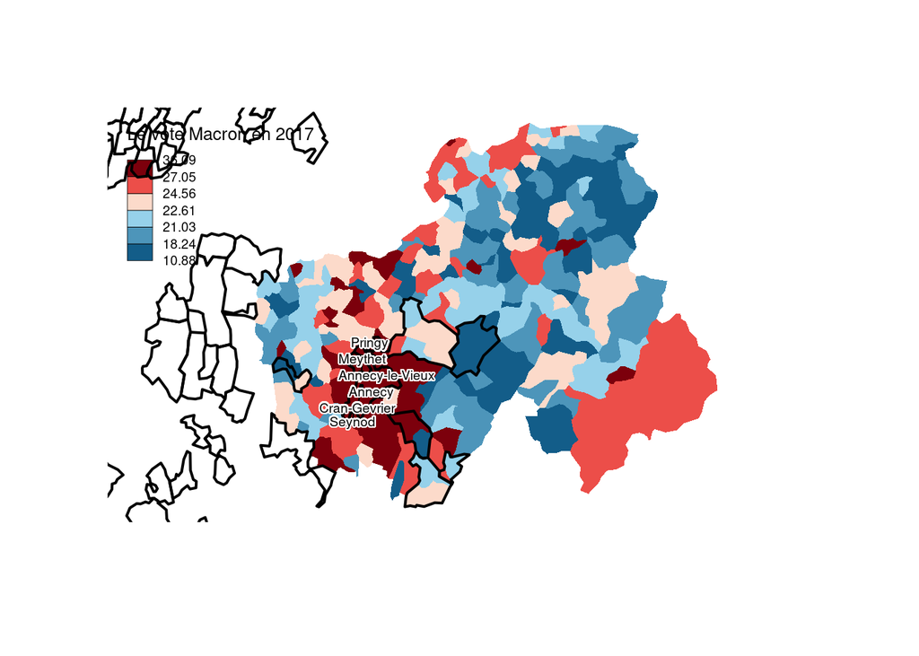

```r
carto <- subset(PR2017_T1_BVot_Cfus, PR2017_T1_BVot_Cfus$LIBGEO_new == "Annecy")
carto <- subset(PR2017_T1_BVot_Cfus, PR2017_T1_BVot_Cfus$CODE_DEPT == "74")
carto <- subset(df2011_PR2017_T1, df2011_PR2017_T1$CODE_DEPT == "49")
carto <- subset(df2011_PR2017_T1, df2011_PR2017_T1$CODE_DEPT == "61")
carto <- subset(df2011_PR2017_T1, df2011_PR2017_T1$CODE_DEPT == "74")

carto <- merge(geom2011, carto, all.x = FALSE, all.y = TRUE, by = "CODGEO")

choroLayer(x = carto , var = "prct_expr_MACRON",
           method = "quantile", nclass = 6,
           col = carto.pal(pal1 = "blue.pal", pal2 = "red.pal", n1 = 3, n2 = 3),
           border = NA,
           legend.pos = "topleft", legend.values.rnd = 2,
           legend.title.txt = "Le vote Macron en 2017")
plot(geomCN_new, add = TRUE, color = NA, lwd = 2)
# labelLayer(carto, txt = "LIBGEO", halo = TRUE, overlap = FALSE, cex = 0.6)
labelLayer(subset(carto, carto$LIBGEO_new == "Annecy"), txt = "LIBGEO", halo = TRUE, overlap = FALSE, cex = 0.6)
```

[figure not shown]

```r
choroLayer(x = carto , var = "prct_expr_FILLON",
           method = "quantile", nclass = 6,
           col = carto.pal(pal1 = "blue.pal", pal2 = "red.pal", n1 = 3, n2 = 3),
           border = NA,
           legend.pos = "topleft", legend.values.rnd = 2,
           legend.title.txt = "Le vote Macron en 2017")
plot(geomCN_new, add = TRUE, color = NA, lwd = 2)
# labelLayer(carto, txt = "LIBGEO", halo = TRUE, overlap = FALSE, cex = 0.6)
labelLayer(subset(carto, carto$LIBGEO_new == "Annecy"), txt = "LIBGEO", halo = TRUE, overlap = FALSE, cex = 0.6)
```

# 6 Politique et fusion : Quel est le profil politique des communes fusionnantes par rapport aux communes non fusionnantes

Pour les élections avant les fusions : Quelle proximité politique (ou non) des communes fusionnantes au sein d’une même commune nouvelle. Cf. section “Chaque CN est-elle composée d’un seul type” ?

## 6.1 Réalisation d’une typologie

### 6.1.1 Préparation des données

```r
# Import des données sur les élections de 2012
# Doit avoir été fait plus haut

colnames(PR2012_T1) <- paste0("PR2012_T1_", colnames(PR2012_T1))
colnames(PR2012_T2) <- paste0("PR2012_T2_", colnames(PR2012_T2))
colnames(PR2022_T1) <- paste0("PR2022_T1_", colnames(PR2022_T1))
colnames(PR2022_T2) <- paste0("PR2022_T2_", colnames(PR2022_T2))
colnames(df2011_PR2017_T1)[14:ncol(df2011_PR2017_T1)] <- paste0("PR2017_T1_", colnames(df2011_PR2017_T1)[14:ncol(df2011_PR2017_T1)])
colnames(df2011_PR2017_T2)[14:ncol(df2011_PR2017_T2)] <- paste0("PR2017_T2_", colnames(df2011_PR2017_T2)[14:ncol(df2011_PR2017_T2)])
colnames(df2011_PR2022_T1)[14:ncol(df2011_PR2022_T1)] <- paste0("PR2022_T1_", colnames(df2011_PR2022_T1)[14:ncol(df2011_PR2022_T1)])

df2011_elect <- merge(df2011, PR2012_T1, by.x = "CODGEO", by.y = "PR2012_T1_CODGEO", all.x = TRUE)
df2011_elect <- merge(df2011_elect, PR2012_T2, by.x = "CODGEO", by.y = "PR2012_T2_CODGEO", all.x = TRUE)

df_new_elect <- merge(df_new, PR2022_T1, by.x = "CODGEO_new", by.y = "PR2022_T1_CODGEO", all.x = TRUE)
df_new_elect <- merge(df_new_elect, PR2022_T2, by.x = "CODGEO_new", by.y = "PR2022_T2_CODGEO", all.x = TRUE)


datafus2011 <- subset(df2011_elect, COM_NOUV == "OUI") # Désigne les données concernant les communes ayant participé à la création d'une commune nouvelle, appelées ici communes fusionnantes

# Calcul de la surface si besoin
# datafus2011$surface <- st_area(geomfus2011) # Attention, unités : m²
# datafus2011$surface <- set_units(datafus2011$surface, km^2) # On passe en km²

# Appariement des données
geomfus2011 <- merge(geomfus2011, datafus2011, by = "CODGEO")
geom2011 <- merge(geom2011, df2011, by = "CODGEO")
geom_new <- merge(geom_new, df_new, by = "CODGEO_new")

# Import données pour les noms de variables
# ratio <- as.data.frame(read_excel("data-raw/meta.xlsx", sheet = "ratios"))
# row.names(ratio) <- ratio$Numerator_Code
```

### 6.1.2 Sélectionner les variables d’intérêt et le cadre d’étude

```r
# Sélection de variables sur les deux tours
selecVar <- c("CODGEO", "COM_NOUV", "CODE_DEPT", "REG", "CATAEU2010", "CODGEO_new", "LIBGEO_new",
              "PR2012_T1_Abst_prct_insc", "PR2012_T1_BlcsNuls_prct_vote",
              "PR2012_T1_prct_insc_LE.PEN", "PR2012_T1_prct_insc_SARKOZY", "PR2012_T1_prct_insc_MÉLENCHON", "PR2012_T1_prct_insc", "PR2012_T1_prct_insc_HOLLANDE",
              "PR2012_T2_Abst_prct_insc", "PR2012_T2_BlcsNuls_prct_vote", "PR2012_T2_prct_insc_HOLLANDE", "PR2012_T2_prct_insc_SARKOZY")

# Sélection de variables uniquement sur le premier tour pour l'élection présidentielle de 2012
selecVar <- c("CODGEO", "COM_NOUV", "CODE_DEPT", "REG", "CATAEU2010", "CODGEO_new", "LIBGEO_new",
              "PR2012_T1_Abst_prct_insc", "PR2012_T1_BlcsNuls_prct_insc",
              "PR2012_T1_prct_insc_LE.PEN", "PR2012_T1_prct_insc_SARKOZY", "PR2012_T1_prct_insc_MÉLENCHON", "PR2012_T1_prct_insc_BAYROU", "PR2012_T1_prct_insc_HOLLANDE")
# Sélection de variables uniquement sur le premier tour pour l'élection présidentielle de 2012 sans bulletins blancs et nuls
selecVar <- c("CODGEO", "COM_NOUV", "CODE_DEPT", "REG", "CATAEU2010", "CODGEO_new", "LIBGEO_new",
              "PR2012_T1_Abst_prct_insc",
              "PR2012_T1_prct_insc_LE.PEN", "PR2012_T1_prct_insc_SARKOZY", "PR2012_T1_prct_insc_MÉLENCHON", "PR2012_T1_prct_insc_BAYROU", "PR2012_T1_prct_insc_HOLLANDE")
elect <- "PR2012_T1"
PourCAH <- df2011_elect[,selecVar]

# Sélection de variables uniquement sur le premier tour pour l'élection présidentielle de 2017 sans bulletins blancs et nuls
selecVar <- c("CODGEO", "COM_NOUV", "CODE_DEPT", "REG", "CATAEU2010", "CODGEO_new", "LIBGEO_new",
              "PR2017_T1_Abst_prct_insc",
              "PR2017_T1_prct_insc_LE.PEN", "PR2017_T1_prct_insc_FILLON", "PR2017_T1_prct_insc_MÉLENCHON", "PR2017_T1_prct_insc_MACRON", "PR2017_T1_prct_insc_HAMON")
elect <- "PR2017_T1"
PourCAH <- df2011_PR2017_T1[,selecVar]

# Sélection de variables uniquement sur le premier tour pour l'élection présidentielle de 2022
# selecVar <- c("CODGEO", "COM_NOUV", "CODE_DEPT_new", "REG", "CATAEU2010", "CODGEO_new", "LIBGEO_new",
#               "PR2022_T1_Abst_prct_insc", "PR2022_T1_Blancs_prct_insc",
#               "PR2022_T1_prct_insc_LE.PEN", "PR2022_T1_prct_insc_MACRON", "PR2022_T1_prct_insc_MÉLENCHON")
# PourCAH <- df_new_elect[,selecVar]
# elect <- "PR2022_T1"


# Pour ne prendre qu'une partie des communes françaises
# PourCAH <- subset (PourCAH, REG == "23" | REG == "25"| REG == "53"| REG == "52") # Normandies, Bretagne, Pays-de-la-Loire
PourCAH <- subset (PourCAH, REG == "23" | REG == "25") # Haute et Basse Normandie
# PourCAH <- subset (PourCAH, CODE_DEPT == "49" ) # Département du Maine-et-Loire
# PourCAH <- subset (PourCAH, CODE_DEPT_new == "49" ) # Département du Maine-et-Loire

# On crée un tableau avec toutes les données (pour calculer les moyennes plus bas) en fonction de la même sélection que la CAH
PourCAH_ttes_var <- subset (df2011_elect, REG == "23" | REG == "25")
PourCAH_ttes_var <- subset (df2011_PR2017_T1, REG == "23" | REG == "25")
# PourCAH_ttes_var <- df2011_elect

setdiff(PourCAH_ttes_var$LIBGEO_new, PourCAH$LIBGEO_new)
```

```
## character(0)
```

```r
PourCAH <- na.omit(PourCAH)
row.names(PourCAH) <- PourCAH$CODGEO # Pour 2012
# row.names(PourCAH) <- PourCAH$CODGEO_new # Pour 2022

PourCAH$CODGEO <- NULL
PourCAH$CODE_DEPT <- NULL
PourCAH$COM_NOUV <- NULL
PourCAH$CATAEU2010 <- NULL
PourCAH$CODGEO_new <- NULL
PourCAH$CODE_DEPT_new <- NULL
PourCAH$LIBGEO_new  <- NULL
PourCAH$REG <- NULL
NbrVariables <- ncol(PourCAH)

# Pour rattraper une erreur au départ
# PourCAH$PR2012_T1_BlcsNuls_prct_expr[PourCAH$PR2012_T1_BlcsNuls_prct_expr == Inf] <- 100
# PourCAH$PR2012_T2_BlcsNuls_prct_expr[PourCAH$PR2012_T2_BlcsNuls_prct_expr == Inf] <- 100

selecVarCAH <- colnames(PourCAH)
```

### 6.1.3 Réalisation de la typologie et valeurs

#### 6.1.3.1 Typologie par CAH

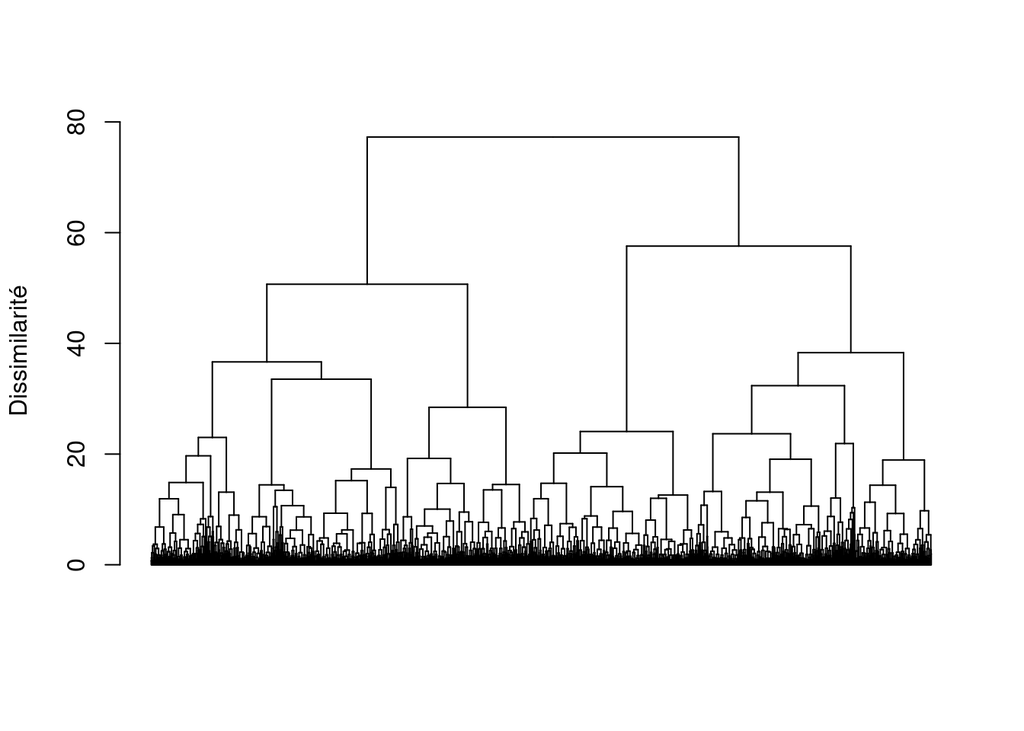

```r
res.pca <- PCA(PourCAH, graph = FALSE)
#res.pca <- PCA(PourCAH, ncp = 5, graph = FALSE) # 50 % of cumulative variance

# res.hcpc <- HCPC(res.pca, graph = TRUE, method = "ward", metric = "euclidian") #Ici coupure à 8 classes pas trop mal
#res.hcpc <- HCPC(res.pca, graph = FALSE, nb.clust = 7, method = "ward", metric = "euclidian") #Pour faire la coupure de manière déterministe

res.hcpc <- agnes(res.pca$ind$coord, metric = "euclidiean", method = "ward")


# Réalisation du dendrogramme en passant par plot
dendro.hcpc <- as.dendrogram(res.hcpc)
plot(dendro.hcpc, leaflab = "none", ylab = "Dissimilarité")
```

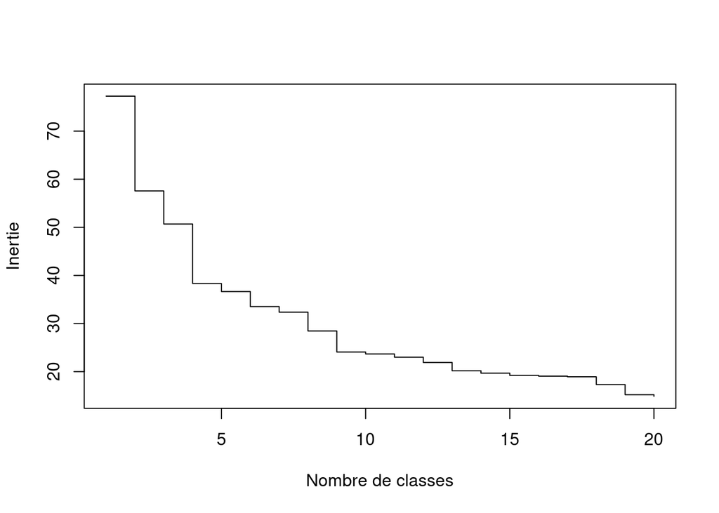

```r
inertie <- sort(res.hcpc$height, decreasing = TRUE)
plot(inertie[1:20], type = "s", xlab = "Nombre de classes", ylab = "Inertie")
```

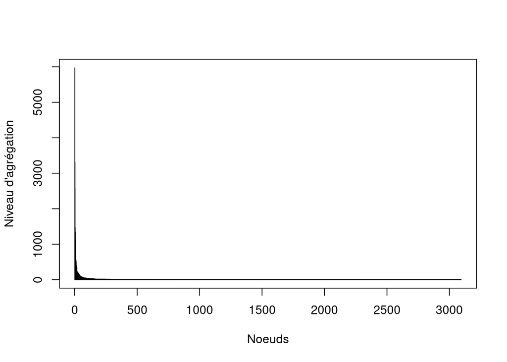

```r
# Affichage de différents graphiques pour aider au découpage
sortedHeight <- sort(res.hcpc$height^2, decreasing = TRUE)
plot(sortedHeight,
     type = "h",
     xlab = "Noeuds",
     ylab = "Niveau d'agrégation")
```

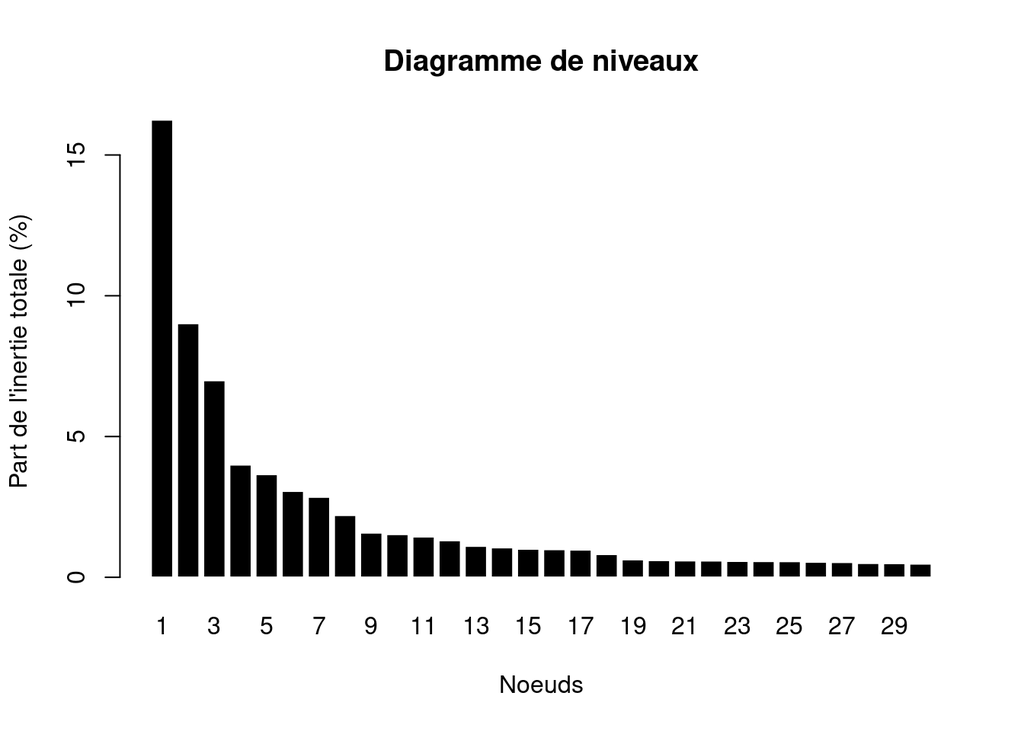

```r
relHeight <- sortedHeight / sum(sortedHeight) * 100
cumHeight <- cumsum(relHeight)
barplot(relHeight[1:30], names.arg = seq(1, 30, 1),
        col = "black", border = "white", xlab = "Noeuds",
        ylab = "Part de l'inertie totale (%)",
        main = "Diagramme de niveaux")
```

#### 6.1.3.2 Choix nombre de classes

```r
# Coupure de l'arbre (k = nombre de classes)
nclass <- 4
cluspop <- cutree(res.hcpc, k = nclass)
# cluspop


# couleurs <- c("#e41a1c","#377eb8","#4daf4a","#984ea3") # Pour 4
# couleurs <- c("#e41a1c","#377eb8","#4daf4a","#984ea3","#ff7f00") # Pour 5
couleurs <- c("#e41a1c","#377eb8","#4daf4a","#984ea3","#ff7f00","#ffff33","#a65628","#f781bf") # Pour 8
```

#### 6.1.3.3 Typologie par k-means

NB : On garde l’appellation ‘PourCAH’ dans l’objectif de simplifier le code mais il faut être attentif à vérifier si les données sont issues d’une CAH ou d’un k-means.

Ressources pour la mise en œuvre : https://delladata.fr/kmeans/ et https://uc-r.github.io/kmeans_clustering.

```r
df <- scale(PourCAH) # Standardisation des données
k2 <- kmeans(df, centers = 2, nstart = 25)
k3 <- kmeans(df, centers = 3, nstart = 25)
k4 <- kmeans(df, centers = 4, nstart = 25)
k5 <- kmeans(df, centers = 5, nstart = 25)

# plots to compare
p1 <- fviz_cluster(k2, geom = "point", data = df) + ggtitle("k = 2")
p2 <- fviz_cluster(k3, geom = "point",  data = df) + ggtitle("k = 3")
p3 <- fviz_cluster(k4, geom = "point",  data = df) + ggtitle("k = 4")
p4 <- fviz_cluster(k5, geom = "point",  data = df) + ggtitle("k = 5")

# library(gridExtra)
gridExtra::grid.arrange(p1, p2, p3, p4, nrow = 2)

# Représentations graphiques du nombre de clusters
# Elbow method
fviz_nbclust(df, kmeans, method = "wss", k.max = 7) +
  labs(subtitle = "Elbow method")

# Silhouette method
fviz_nbclust(df, kmeans, method = "silhouette", k.max = 7) +
  labs(subtitle = "Silhouette method")

# Gap statistic
# nboot = 50 to keep the function speedy.
# recommended value: nboot= 500 for your analysis.
# Use verbose = FALSE to hide computing progression.
set.seed(123)
nbrtests <- 50
fviz_nbclust(df, kmeans, nstart = 25, method = "gap_stat", nboot = nbrtests, k.max = 7) +
  labs(subtitle = paste("Gap statistic method. Nbr tests :", nbrtests))

rm(df, k2, k3, k4, k5, p1, p2, p3, p4, nbrtests)
```

```r
PourCAH_scale <- scale(PourCAH) # Standardisation des données
# Définition du nombre de cluster/classes
nclass <- 5
kmeans_out <- kmeans(PourCAH_scale, centers = nclass, nstart = 25)
# kmeans_out

fviz_cluster(kmeans_out, data = PourCAH)

# Pour visualiser la relation entre les clasters et chacune des variables
pairs(PourCAH, col=c(1:nclass)[kmeans_out$cluster])

# Pour faciliter la suite du code, on reprend la même terminaison que la CAH
cluspop <- kmeans_out$cluster
```

#### 6.1.3.4 Valeurs absolues

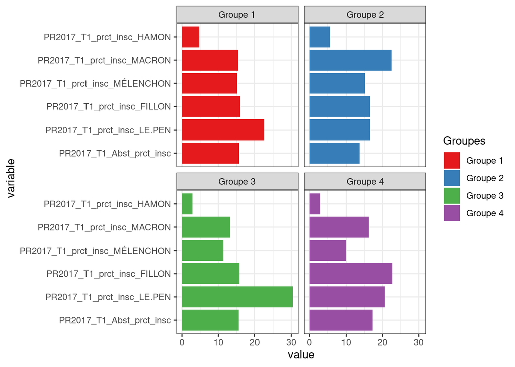

```r
# Définition de noms de groupes

# Noms pour typo avec les navetteurs, avec 5 classes
# NB : NOMS ADAPTÉS POUR LES DONNÉES 2011-2020 UNIQUEMENT
# NomsGroupesCAH <- c("Groupe 1 PPCQ", # Proche Périphérie, Cadres, Quinquagénaires
#                     "Groupe 2 PFO", # Périphéries Familiales et Ouvrières
#                     "Groupe 3 MOARO", # Moyen, Ouvriers, Agriculteurs, Retraités, Out.
#                     "Groupe 4 VAR", # Vieillissantes, Agricoles et Rurales
#                     "Groupe 5 REAV" # Rurales, Enclavées, Agricoles et Vieillissantes
# )
# Si on ne veut pas définir de noms
NomsGroupesCAH <- paste ("Groupe", 1:nclass)

# On intègre ces données dans le tableau de départ
PourCAH <- as.data.frame(PourCAH, stringsAsFactors = FALSE)
PourCAH$Groupes <- factor(cluspop,
                          levels = 1:nclass,
                          labels = paste(NomsGroupesCAH))

PourCAH$CODGEO <- row.names(PourCAH)
# Calcul de la moyenne des variables
clusProfile <- aggregate(PourCAH [, 1:NbrVariables],
                         by = list(PourCAH$Groupes),
                         mean)
colnames(clusProfile)[1] <- "Groupes"
clusLong <- melt(clusProfile, id.vars = "Groupes")

ggplot(clusLong) +
  geom_bar(aes(x = variable, y = value, fill = Groupes),
           stat = "identity") +
  scale_fill_manual(values=couleurs) +
  facet_wrap(~ Groupes) +
  coord_flip() +
  theme_bw()
```

#### 6.1.3.5 Valeurs moyennes

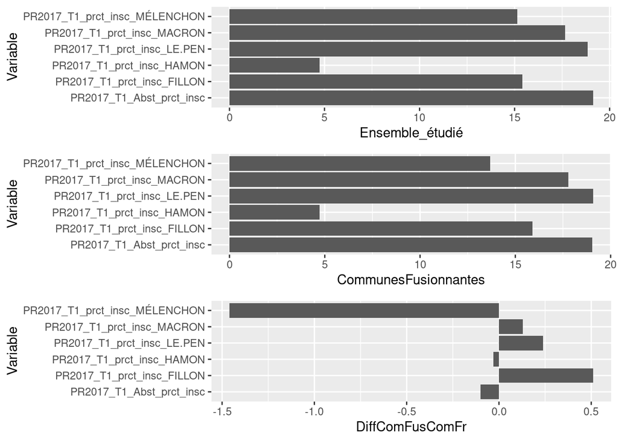

```r
# Calculs des valeurs moyennes (pour comparaison)
# On identifie les variables en stock
VarCAHBrutes <- stringr::str_replace(selecVarCAH, "prct_insc", "nbre_voix")
# Quelques cas particuliers
VarCAHBrutes <- stringr::str_replace(VarCAHBrutes, "Abst_nbre_voix", "Abst_nbre")
VarCAHBrutes <- stringr::str_replace(VarCAHBrutes, "BlcsNuls_nbre_voix", "BlcsNuls_nbre")

# Sélection données utiles
pourmoyennesCAH <- na.omit(subset(PourCAH_ttes_var, COM_NOUV == "OUI"))
somme_inscr_CFus <- sum(pourmoyennesCAH[, paste0(elect, "_Inscr_nbre")])
somme_inscr_ttes_com <- sum(na.omit(PourCAH_ttes_var[, paste0(elect, "_Inscr_nbre")]))

moyennesCAH <- data.frame()

i <- VarCAHBrutes[3]

for (i in VarCAHBrutes){
  somme_ttes_com <- sum(PourCAH_ttes_var[, i], na.rm = TRUE)
  moy_ttes_com <- round(100*somme_ttes_com/somme_inscr_ttes_com, 2)
  somme_CFus <- sum(pourmoyennesCAH[, i], na.rm = TRUE)
  moy_Cfus <- round(100*somme_CFus/somme_inscr_CFus, 2)
  variable <- selecVarCAH[ which(VarCAHBrutes == i) ]
  ligne <- c(variable, moy_ttes_com, moy_Cfus)
  moyennesCAH <- rbind(moyennesCAH, ligne, stringsAsFactors= FALSE)

}
rm (somme_inscr_CFus, somme_inscr_ttes_com, somme_ttes_com, moy_ttes_com, somme_CFus, moy_Cfus, ligne, variable)

colnames(moyennesCAH) <- c("Variable", "Ensemble_étudié", "CommunesFusionnantes")
moyennesCAH$Variable <- as.factor(moyennesCAH$Variable)
moyennesCAH$Ensemble_étudié <- as.numeric(moyennesCAH$Ensemble_étudié)
moyennesCAH$CommunesFusionnantes <- as.numeric(moyennesCAH$CommunesFusionnantes)
moyennesCAH$DiffComFusComFr <- moyennesCAH$CommunesFusionnantes - moyennesCAH$Ensemble_étudié

aa<- ggplot(data = moyennesCAH) +
  geom_bar(aes(x = Variable, y = Ensemble_étudié), stat = "identity") + coord_flip()
bb <- ggplot(data = moyennesCAH) +
  geom_bar(aes(x = Variable, y = CommunesFusionnantes), stat = "identity") + coord_flip()
cc <- ggplot(data = moyennesCAH) +
  geom_bar(aes(x = Variable, y = DiffComFusComFr), stat = "identity") + coord_flip()
cowplot::plot_grid(aa, bb, cc, ncol = 1, nrow = 3)
```

```r
rm(aa,bb,cc)
```

#### 6.1.3.6 Valeurs standardisées

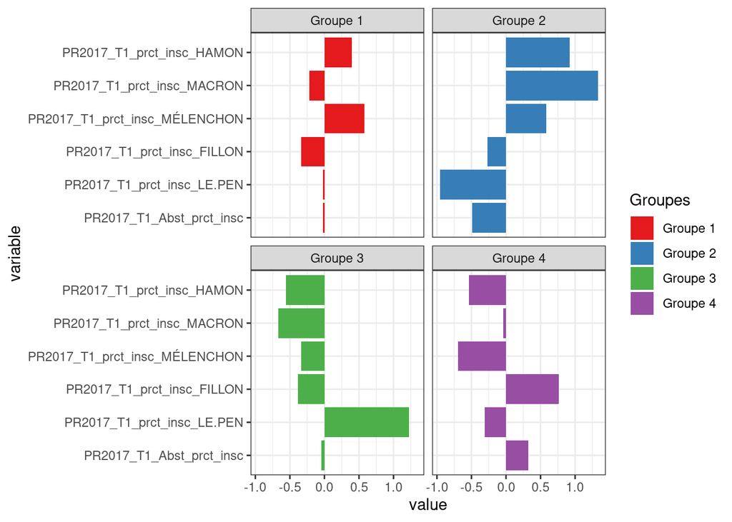

```r
# On intègre ces données dans le tableau de départ

PourCAHz <- scale(PourCAH[,c(1:NbrVariables)])
PourCAHz <- as.data.frame(PourCAHz, stringsAsFactors = FALSE)

PourCAHz$Groupes <- PourCAH$Groupes
# PourCAH$Groupes <- factor(cluspop,
#                           levels = 1:nclass,
#                          labels = paste(NomsGroupesCAH))

PourCAHz$CODGEO <- row.names(PourCAHz)
# Calcul de la moyenne des variables
clusProfileStd <- aggregate(PourCAHz [, 1:NbrVariables],
                         by = list(PourCAH$Groupes),
                         mean)
colnames(clusProfileStd)[1] <- "Groupes"
clusLongStd <- melt(clusProfileStd, id.vars = "Groupes")
# clusLongStd <- merge(clusLongStd, ratio[, 1:2], by.x = "variable", by.y = "CODE") # Pour lisibilité du graphique
# colnames(clusLongStd)[4] <- "Variable"

ggplot(clusLongStd) +
  geom_bar(aes(x = variable, y = value, fill = Groupes),
           stat = "identity") +
  #  scale_fill_grey() +
  scale_fill_manual(values=couleurs) +
  facet_wrap(~ Groupes) +
  coord_flip() + theme_bw()
```

#### 6.1.3.7 Cartographie

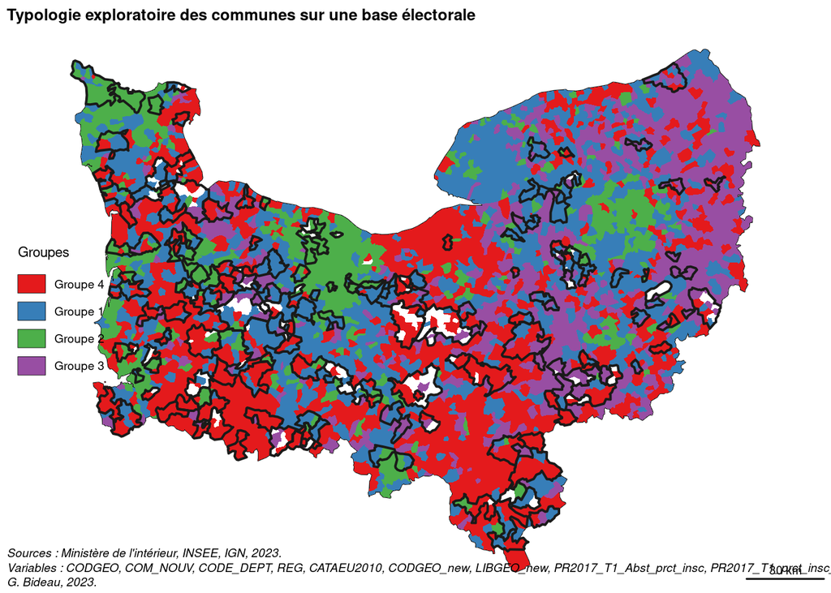

```r
# Remettre groupes dans geomfus2011 pour cartographie
typo <- merge(geom2011, PourCAH[ , c("CODGEO","Groupes")], by = "CODGEO", all.y = TRUE)

# Si la cartographie la plus adaptée est celle avec les communes nouvelles (élections 2022 par exemple)
# typo <- merge(geom_new, PourCAH[ , c("CODGEO","Groupes")], by.x = "CODGEO_new", by.y = "CODGEO", all.y = TRUE)

## Carte Typoe nationale des communes fusionnées


# mf_export(x = typo, export = "svg", filename = "figures/TypoEspaceGeo.svg",
#           width = 5, theme = "nevermind") # Si souhait d'export

par(mfrow = c(1, 1))
par(mar=c(0,0,1.2,0))

typo$CODE_DEPT <- substr(typo$CODGEO, start = 1, stop = 2)
departements <- unique(typo$CODE_DEPT) # Pas parfait si données _new
departements <- na.rm(departements)
dep_carto <- subset(dep, CODE_DEPT %in% departements)

geomCN_new_carto <- geomCN_new
geomCN_new_carto$dep <- substr(geomCN_new_carto$CODGEO_new, start = 1, stop = 2)
geomCN_new_carto <- subset(geomCN_new_carto, dep %in% departements)


plot(st_geometry(dep_carto), border = "#1A1A19", lwd = 1)

typoLayer(x = typo, var = "Groupes",
          col = couleurs,
          border = NA,
          #legend.title = "Typologie des communes fusionnantes/nà partir de critères socio-économiques",
          legend.title.cex = 0.7,
          legend.values.cex = 0.6,
          legend.pos = "left", add = T)

layoutLayer(title = "Typologie exploratoire des communes sur une base électorale",
            author = "G. Bideau, 2023.",
            tabtitle = TRUE, frame = FALSE, col = "white", coltitle = "black",
            sources = paste0("Sources : Ministère de l'intérieur, INSEE, IGN, 2023.\nVariables : ", paste0(selecVar, collapse = ", ")))
            # sources = "Sources : INSEE, IGN, 2022.")



plot(st_geometry(geomCN_new_carto), border = "#1A1A19" , lwd = 2, add = TRUE)
```

```r
# dev.off() # Si souhait d'export
```

### 6.1.4 Présentation plan factoriel à partir d’une ACP et d’une AFC

Cf. R et espace, chapitre 6 https://r.developpez.com/tutoriels/programmation-graphe/livre-R-et-espace/?page=chapitre-6-analyses-factorielles

#### 6.1.4.1 Réalisation d’une ACP

Permet de montrer graphiquement les plans factoriels

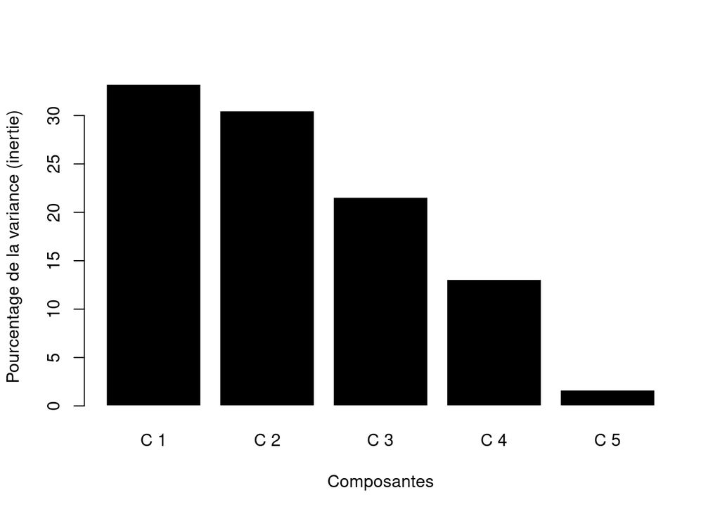

```r
library(ade4)
PCA <- dudi.pca(PourCAHz[,1:5],
                  center = TRUE,
                  scale = TRUE,
                  scannf = FALSE,
                  nf = 2)
summaryPca <- data.frame(
    EIG = PCA$eig,
    PCTVAR = 100 * PCA$eig / sum(PCA$eig),
    CUMPCTVAR = cumsum(100 * PCA$eig / sum(PCA$eig))
)

barplot(summaryPca$PCTVAR,
        xlab = "Composantes",
        ylab = "Pourcentage de la variance (inertie)",
        names = paste("C", seq(1, nrow(summaryPca), 1)),
        col = "black",
        border = "white")
```

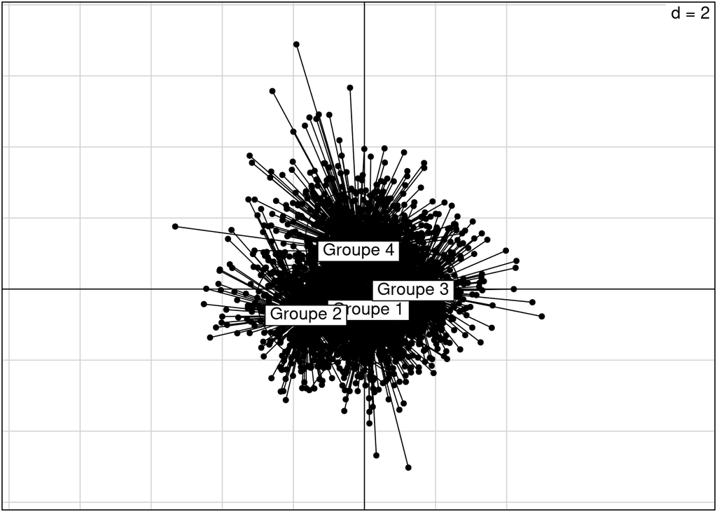

```r
axisCoord <- PCA$co

s.class(PCA$li,
        fac = as.factor(PourCAHz$Groupes))
```

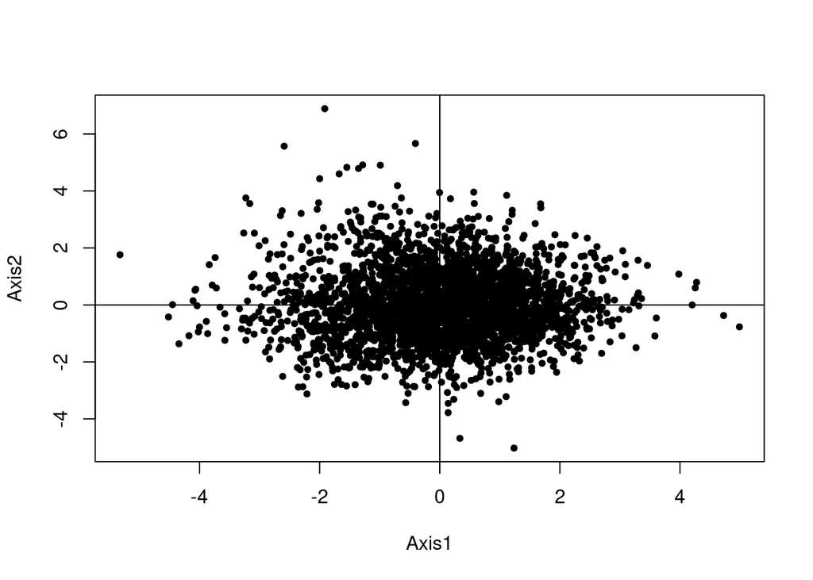

```r
plot(PCA$li, pch = 20)
abline(h=0, v=0)
```

#### 6.1.4.2 Réalisation d’une AFC

À tester

```r
PourCOA <- evol_deps[2:nrow(evol_deps), c(bornes, "Département")]
PourCOA <- subset(PourCOA, PourCOA$Département != "Paris" & PourCOA$Département != "Aveyron")
row.names(PourCOA) <- PourCOA$Département
COA <- dudi.coa(PourCOA[,1:length(bornes)],
                  scannf = FALSE,
                  nf = 2)
summaryCOA <- data.frame(
    EIG = COA$eig,
    PCTVAR = 100 * COA$eig / sum(COA$eig),
    CUMPCTVAR = cumsum(100 * COA$eig / sum(COA$eig))
)

barplot(summaryCOA$PCTVAR,
        xlab = "Composantes",
        ylab = "Pourcentage de la variance (inertie)",
        names = paste("C", seq(1, nrow(summaryCOA), 1)),
        col = "black",
        border = "white")


plot(COA$li, pch = 20, col = "grey40")
abline(h=0, v=0)
points(COA$co, type = "o", pch = 18, col = "black")
text(COA$co,
     labels = row.names(COA$co),
     cex = 0.8,
     pos = c(rep(4, times = 3), 1, rep(4, times = 4), 3))

s.class(COA$li,
        fac = as.factor(PourCAHz$Groupes))

plot(PCA$li, pch = 20)
abline(h=0, v=0)
```

### 6.1.5 Export données typo

```r
st_write(obj = typo, dsn = paste0("sorties/typo_data_elect_", elect, ".gpkg"), layer = "typo", delete_layer = TRUE, quiet = TRUE)

# st_write(obj = typo, dsn = "sorties/typo_data_elect_Normandie_4classes_1erT2012.gpkg", layer = "typo", delete_layer = TRUE, quiet = TRUE)
```

### 6.1.6 Comparaison et analyse des groupes

Dans le but de comparer un profil avec la moyenne française, on extrait les données de chaque groupe défini par la CAH (données issues de `clusLong` et `clusProfile`) et on les compile dans un tableau contenant déjà les données des moyennes françaises et des communes fusionnantes (`moyennesCAH`). En sortie, un tableau est créé pour chaque groupe.

##### 6.1.6.0.1 Comparaison tous groupes

```r
# Tableau pour comparaison entre les groupes
clusProfile2 <- as.data.frame(t(clusProfile))
colnames(clusProfile2) <- clusProfile2[1,]
clusProfile2 <- clusProfile2[ c(2:nrow(clusProfile2)),]
compare <- cbind(moyennesCAH, clusProfile2)

for (i in NomsGroupesCAH){
  a <- which(colnames(compare)== i)
  b <- as.numeric(compare[,a])
  compare[,a] <- as.numeric(compare[,a])
  compare[paste0(i,"_DiffAvecFrance")] <- b - compare$Ensemble_étudié
  compare[paste0(i,"_DiffAvecComFus")] <- b - compare$CommunesFusionnantes
  rm(a, b)
}

kable(compare, row.names = F, digits = 2, caption = "Tableau de comparaison entre les groupes")
```

Tableau de comparaison entre les groupes

| Variable | Ensemble_étudié | CommunesFusionnantes | DiffComFusComFr | Groupe 1 | Groupe 2 | Groupe 3 | Groupe 4 | Groupe 1_DiffAvecFrance | Groupe 1_DiffAvecComFus | Groupe 2_DiffAvecFrance | Groupe 2_DiffAvecComFus | Groupe 3_DiffAvecFrance | Groupe 3_DiffAvecComFus | Groupe 4_DiffAvecFrance | Groupe 4_DiffAvecComFus |
| --- | --- | --- | --- | --- | --- | --- | --- | --- | --- | --- | --- | --- | --- | --- | --- |
| PR2017_T1_Abst_prct_insc | 19.13 | 19.03 | -0.10 | 15.73 | 13.69 | 15.63 | 17.24 | -3.40 | -3.30 | -5.44 | -5.34 | -3.50 | -3.40 | -1.89 | -1.79 |
| PR2017_T1_prct_insc_LE.PEN | 18.84 | 19.08 | 0.24 | 22.49 | 16.49 | 30.45 | 20.65 | 3.65 | 3.41 | -2.35 | -2.59 | 11.61 | 11.37 | 1.81 | 1.57 |
| PR2017_T1_prct_insc_FILLON | 15.40 | 15.91 | 0.51 | 16.07 | 16.49 | 15.78 | 22.75 | 0.67 | 0.16 | 1.09 | 0.58 | 0.38 | -0.13 | 7.35 | 6.84 |
| PR2017_T1_prct_insc_MÉLENCHON | 15.14 | 13.68 | -1.46 | 15.14 | 15.15 | 11.43 | 9.99 | 0.00 | 1.46 | 0.01 | 1.47 | -3.71 | -2.25 | -5.15 | -3.69 |
| PR2017_T1_prct_insc_MACRON | 17.65 | 17.78 | 0.13 | 15.34 | 22.49 | 13.30 | 16.17 | -2.31 | -2.44 | 4.84 | 4.71 | -4.35 | -4.48 | -1.48 | -1.61 |
| PR2017_T1_prct_insc_HAMON | 4.75 | 4.72 | -0.03 | 4.74 | 5.72 | 2.93 | 2.97 | -0.01 | 0.02 | 0.97 | 1.00 | -1.82 | -1.79 | -1.78 | -1.75 |

```r
comparaisons <- data.frame()
for (i in NomsGroupesCAH){
  a <- subset(typo, typo$Groupes == i)
  Nb <- nrow(a)
  c <- table(a$CATAEU2010)
  h <- c(i, Nb, c)
  comparaisons <- rbind(comparaisons, h, stringsAsFactors= FALSE)
  rm( a, c, h, Nb)
}
colnames(comparaisons) <- c("Groupes", "Nombre", "111","112","120","211","212","221","222","300","400")


tmp <- comparaisons[, c("Groupes", "Nombre", "111","112","120","211","212","221","222","300","400")]
kable(tmp, row.names = F, digits = 1, caption = "Code de Zonage en aire urbaine dans chaque groupe",
      col.names = c("Groupes", "Nombre de communes", "Unité urbaine", "Couronne périurbaine", "Communes multipolarisées", "Unité urbaine", "Couronne périurbaine", "Unité urbaine", "Couronne périurbaine", "Autres communes multipolarisées", "Communes hors influence des pôles"), format = "html") %>%
  kableExtra::add_header_above(c(" " = 2, "Grandes aires urbaines" = 3, "Pôles moyens" = 2, "Petits pôles" = 2," " = 2))
```

Code de Zonage en aire urbaine dans chaque groupe

| Groupes | Nombre de communes | Grandes aires urbaines Unité urbaine | Grandes aires urbaines Couronne périurbaine | Grandes aires urbaines Communes multipolarisées | Pôles moyens Unité urbaine | Pôles moyens Couronne périurbaine | Petits pôles Unité urbaine | Petits pôles Couronne périurbaine | Autres communes multipolarisées | Communes hors influence des pôles |
| --- | --- | --- | --- | --- | --- | --- | --- | --- | --- | --- |
| Groupe 1 | 986 | 77 | 389 | 164 | 11 | 35 | 21 | 3 | 193 | 93 |
| Groupe 2 | 518 | 88 | 295 | 32 | 4 | 18 | 10 | 1 | 40 | 30 |
| Groupe 3 | 651 | 6 | 238 | 122 | 2 | 19 | 8 | 6 | 193 | 57 |
| Groupe 4 | 940 | 40 | 169 | 148 | 13 | 23 | 33 | 17 | 307 | 190 |

##### 6.1.6.0.2 Tableaux comparaison groupe par groupe

```r
x <- length(NomsGroupesCAH)
min <- min(compare[, (5+x):ncol(compare)])
max <- max(compare[, (5+x):ncol(compare)])
rm(x)

# Boucle donnant les valeurs pour chaque groupe, avec éléments de comparaison d'un profil avec la moyenne française
for (i in NomsGroupesCAH){
  clusLongGr <- subset(clusLong, clusLong$Groupes == i)
  compare <- merge(moyennesCAH, clusLongGr[, c("variable", "value")], by.x = "Variable", by.y = "variable")
  compare$DiffAvecEns <- compare$value - compare$Ensemble_étudié
  compare$DiffAvecComFus <- compare$value - compare$CommunesFusionnantes
  compare[, 2:length(compare)] <- round(compare[, 2:length(compare)], 1)

  n <- stringr::str_sub(i, 8, 8)
  assign(paste0("compare_Gr", n), compare)
  # print(kable(compare, row.names = F, caption = i))
  colnames(compare) <- c ("Variable",
                            "Valeur pour l'ensemble étudié (A)",
                            "Valeur pour les communes fusionnantes (B)",
                            "Différence ComFus/Ensemble (B-A)",
                            "Valeur pour le groupe étudié (C)",
                            "Différence Groupe/Ensemble (C-A)",
                            "Différence Groupe/ComFus (C-B)")
#  min <- min(compare[, c("Différence ComFus/Ensemble (B-A)", "Différence Groupe/Ensemble (C-A)", "Différence Groupe/ComFus (C-B)")])
#  max <- max(compare[, c("Différence ComFus/Ensemble (B-A)", "Différence Groupe/Ensemble (C-A)", "Différence Groupe/ComFus (C-B)")])

  table <- condformat(compare) %>%
          rule_fill_bar("Valeur pour l'ensemble étudié (A)", limits = c(0, 100), low = "darkgreen", high = "darkgreen") %>%
          rule_fill_bar("Valeur pour les communes fusionnantes (B)", limits = c(0, 100), low = "darkgreen", high = "darkgreen") %>%
          rule_fill_bar("Valeur pour le groupe étudié (C)", limits = c(0, 100), low = "darkgreen", high = "darkgreen") %>%
          rule_fill_gradient2("Différence ComFus/Ensemble (B-A)", low = "darkblue", high = "red", limits = c(min, max)) %>%
          rule_fill_gradient2("Différence Groupe/Ensemble (C-A)", low = "darkblue", high = "red",  limits = c(min, max)) %>%
          rule_fill_gradient2("Différence Groupe/ComFus (C-B)", low = "darkblue", high = "red",  limits = c(min, max))%>%
          theme_caption(caption = i) %>%
          theme_htmlWidget(number_of_entries = nrow(compare))
  print(knit_print(table))
  rm(compare, n, table)
}
```

|  | Variable | Valeur pour l’ensemble étudié (A) | Valeur pour les communes fusionnantes (B) | Différence ComFus/Ensemble (B-A) | Valeur pour le groupe étudié (C) | Différence Groupe/Ensemble (C-A) | Différence Groupe/ComFus (C-B) |
| --- | --- | --- | --- | --- | --- | --- | --- |
| 1 | PR2017_T1_Abst_prct_insc | 19.1 | 19.0 | -0.1 | 15.7 | -3.4 | -3.3 |
| 2 | PR2017_T1_prct_insc_FILLON | 15.4 | 15.9 | 0.5 | 16.1 | 0.7 | 0.2 |
| 3 | PR2017_T1_prct_insc_HAMON | 4.8 | 4.7 | 0.0 | 4.7 | 0.0 | 0.0 |
| 4 | PR2017_T1_prct_insc_LE.PEN | 18.8 | 19.1 | 0.2 | 22.5 | 3.6 | 3.4 |
| 5 | PR2017_T1_prct_insc_MACRON | 17.6 | 17.8 | 0.1 | 15.3 | -2.3 | -2.4 |
| 6 | PR2017_T1_prct_insc_MÉLENCHON | 15.1 | 13.7 | -1.5 | 15.1 | 0.0 | 1.5 |

|  | Variable | Valeur pour l’ensemble étudié (A) | Valeur pour les communes fusionnantes (B) | Différence ComFus/Ensemble (B-A) | Valeur pour le groupe étudié (C) | Différence Groupe/Ensemble (C-A) | Différence Groupe/ComFus (C-B) |
| --- | --- | --- | --- | --- | --- | --- | --- |
| 1 | PR2017_T1_Abst_prct_insc | 19.1 | 19.0 | -0.1 | 13.7 | -5.4 | -5.3 |
| 2 | PR2017_T1_prct_insc_FILLON | 15.4 | 15.9 | 0.5 | 16.5 | 1.1 | 0.6 |
| 3 | PR2017_T1_prct_insc_HAMON | 4.8 | 4.7 | 0.0 | 5.7 | 1.0 | 1.0 |
| 4 | PR2017_T1_prct_insc_LE.PEN | 18.8 | 19.1 | 0.2 | 16.5 | -2.3 | -2.6 |
| 5 | PR2017_T1_prct_insc_MACRON | 17.6 | 17.8 | 0.1 | 22.5 | 4.8 | 4.7 |
| 6 | PR2017_T1_prct_insc_MÉLENCHON | 15.1 | 13.7 | -1.5 | 15.2 | 0.0 | 1.5 |

|  | Variable | Valeur pour l’ensemble étudié (A) | Valeur pour les communes fusionnantes (B) | Différence ComFus/Ensemble (B-A) | Valeur pour le groupe étudié (C) | Différence Groupe/Ensemble (C-A) | Différence Groupe/ComFus (C-B) |
| --- | --- | --- | --- | --- | --- | --- | --- |
| 1 | PR2017_T1_Abst_prct_insc | 19.1 | 19.0 | -0.1 | 15.6 | -3.5 | -3.4 |
| 2 | PR2017_T1_prct_insc_FILLON | 15.4 | 15.9 | 0.5 | 15.8 | 0.4 | -0.1 |
| 3 | PR2017_T1_prct_insc_HAMON | 4.8 | 4.7 | 0.0 | 2.9 | -1.8 | -1.8 |
| 4 | PR2017_T1_prct_insc_LE.PEN | 18.8 | 19.1 | 0.2 | 30.5 | 11.6 | 11.4 |
| 5 | PR2017_T1_prct_insc_MACRON | 17.6 | 17.8 | 0.1 | 13.3 | -4.4 | -4.5 |
| 6 | PR2017_T1_prct_insc_MÉLENCHON | 15.1 | 13.7 | -1.5 | 11.4 | -3.7 | -2.2 |

|  | Variable | Valeur pour l’ensemble étudié (A) | Valeur pour les communes fusionnantes (B) | Différence ComFus/Ensemble (B-A) | Valeur pour le groupe étudié (C) | Différence Groupe/Ensemble (C-A) | Différence Groupe/ComFus (C-B) |
| --- | --- | --- | --- | --- | --- | --- | --- |
| 1 | PR2017_T1_Abst_prct_insc | 19.1 | 19.0 | -0.1 | 17.2 | -1.9 | -1.8 |
| 2 | PR2017_T1_prct_insc_FILLON | 15.4 | 15.9 | 0.5 | 22.8 | 7.4 | 6.8 |
| 3 | PR2017_T1_prct_insc_HAMON | 4.8 | 4.7 | 0.0 | 3.0 | -1.8 | -1.8 |
| 4 | PR2017_T1_prct_insc_LE.PEN | 18.8 | 19.1 | 0.2 | 20.6 | 1.8 | 1.6 |
| 5 | PR2017_T1_prct_insc_MACRON | 17.6 | 17.8 | 0.1 | 16.2 | -1.5 | -1.6 |
| 6 | PR2017_T1_prct_insc_MÉLENCHON | 15.1 | 13.7 | -1.5 | 10.0 | -5.2 | -3.7 |

```r
# Autre possibilité, qui m'a moins convaincue : https://cran.r-project.org/web/packages/kableExtra/vignettes/awesome_table_in_html.html#celltext_specification
# library(formattable)
# library(kableExtra)
# library(dplyr)
# compare_Gr2 %>%
#   mutate (
#     DiffComFusComFr = color_tile("white", "orange") (DiffComFusComFr),
#     DiffAvecFr = color_tile("white", "orange") (DiffAvecFr),
#     DiffAvecComFus = color_tile("white", "orange") (DiffAvecComFus),
#     France = color_bar("lightgreen")(France),
#     CommunesFusionnantes = color_bar("lightgreen")(CommunesFusionnantes),
#     value = color_bar("lightgreen")(value)
#     )%>%
#   kable(escape = F, align = "r", digits = 1) %>%
#   kable_styling(c("striped", "condensed"), full_width = F)
```

##### 6.1.6.0.3 Comparaisons des moyennes

Il est important de préciser que, comme toujours, les détails des calculs statistiques ont toute leur importance. Jusqu’ici, les moyennes ont été calculées sur l’ensemble de la population des ensemble étudiés. Par exemple, le chiffre de 66,38 % d’actifs occupés hors de leur commune de résidence, désigne le nombre de personnes quittant leur commune pour aller travailler. Or, les chiffres sont différents si on fait, désormais, apparaître les moyennes des taux communaux d’actifs occupés hors de leur commune de résidence

```r
# NB : On reprend les données déjà élaborées dans le 5.2.2
# Import données totales

df2011_elect <- df2011_PR2017_T1 # Si utilisation des données communes/bureaux de vote à la géométrie 2011
df2011_elect_Cfus <- subset(df2011_elect, df2011_elect$COM_NOUV == "OUI")

moyennesComCAH <- data.frame()
for (i in selecVarCAH){
  a <- round(mean(df2011_elect[, i], na.rm = TRUE), 2)
  b <- round(median(df2011_elect[, i], na.rm = TRUE), 2)
  c <- round(mean(df2011_elect_Cfus[, i], na.rm = TRUE), 2)
  d <- round(median(df2011_elect_Cfus[, i], na.rm = TRUE), 2)

  h <- c(i, a, b, c, d)
  moyennesComCAH <- rbind(moyennesComCAH, h, stringsAsFactors= FALSE)
  rm( a, b, c, d, h)
}
# Pour calcul valeur moyenne retraités ("Inf" vient perturber) :
# a <- subset(df2011$P09_RETR1564_RT, df2011$P09_RETR1564_RT != Inf)
# mean(a, na.rm =TRUE)
# rm(a)

colnames(moyennesComCAH) <- c("Variable", "Comfr_moy", "Comfr_med", "Comfus_moy", "Comfus_med")

kable(moyennesComCAH[, 1:5], row.names = FALSE, col.names = c("", "Moyenne", "Médiane", "Moyenne", "Médiane"), digits = 2, format = "html")  %>%
  kableExtra::add_header_above(c("Variable" = 1, "Communes françaises" = 2, "Communes fusionnantes" = 2))
```

| Variable | Communes françaises Moyenne | Communes françaises Médiane | Communes fusionnantes Moyenne | Communes fusionnantes Médiane |
| --- | --- | --- | --- | --- |
| PR2017_T1_Abst_prct_insc | 16.66 | 16.31 | 16.61 | 16.41 |
| PR2017_T1_prct_insc_LE.PEN | 21.31 | 20.96 | 19.82 | 19.48 |
| PR2017_T1_prct_insc_FILLON | 16.23 | 15.33 | 17.66 | 17.06 |
| PR2017_T1_prct_insc_MÉLENCHON | 13.95 | 13.49 | 13.57 | 13.1 |
| PR2017_T1_prct_insc_MACRON | 16.56 | 16.3 | 17.13 | 17.02 |
| PR2017_T1_prct_insc_HAMON | 4.25 | 3.95 | 4.26 | 4.05 |

## 6.2 Analyse de la typologie

### 6.2.1 Quel poids des communes nouvelles dans chaque groupe ?

On observe la place des communes fusionnantes dans chaque groupe. On met également un place un test de chi² pour voir si on peut rejetter l’hypothèse d’indépendance des variables.

```r
# typo <- st_read("sorties/typo_data_elect.gpkg", quiet = TRUE)
# typo <- st_read("sorties/typo_data_elect_Normandie_4classes_1erT2012.gpkg", quiet = TRUE)
tabcont <- table(typo$COM_NOUV, typo$Groupes)
tabcont # En valeur absolue
```

```
##
##       Groupe 1 Groupe 2 Groupe 3 Groupe 4
##   NON      790      405      557      727
##   OUI      196      113       94      213
```

```r
round(100*prop.table(tabcont,margin=1),1) # Pourcentages, le total se fait par lignes
```

```
##
##       Groupe 1 Groupe 2 Groupe 3 Groupe 4
##   NON     31.9     16.3     22.5     29.3
##   OUI     31.8     18.3     15.3     34.6
```

```r
round(100*prop.table(tabcont,margin=),1) # Pourcentages, le total se fait sur l'ensemble de la population
```

```
##
##       Groupe 1 Groupe 2 Groupe 3 Groupe 4
##   NON     25.5     13.1     18.0     23.5
##   OUI      6.3      3.7      3.0      6.9
```

```r
round(100*prop.table(tabcont,margin=2),1) # Pourcentages, le total se fait par colonnes
```

```
##
##       Groupe 1 Groupe 2 Groupe 3 Groupe 4
##   NON     80.1     78.2     85.6     77.3
##   OUI     19.9     21.8     14.4     22.7
```

```r
test<-chisq.test(tabcont)
test$observed
```

```
##
##       Groupe 1 Groupe 2 Groupe 3 Groupe 4
##   NON      790      405      557      727
##   OUI      196      113       94      213
```

```r
round(test$expected,1)
```

```
##
##       Groupe 1 Groupe 2 Groupe 3 Groupe 4
##   NON    789.8    414.9    521.4    752.9
##   OUI    196.2    103.1    129.6    187.1
```

```r
round(test$residuals,2)
```

```
##
##       Groupe 1 Groupe 2 Groupe 3 Groupe 4
##   NON     0.01    -0.49     1.56    -0.94
##   OUI    -0.02     0.98    -3.12     1.89
```

```r
test
```

```
##
##  Pearson's Chi-squared test
##
## data:  tabcont
## X-squared = 17.859, df = 3, p-value = 0.0004704
```

Test de Chi² avec des variables du 1er et du 2e tour de 2012 : Maine-et-Loire (X-squared = 7.3037, df = 3, p-value = 0.06282) et Normandie (X-squared = 2.1736, df = 5, p-value = 0.8246) : Résultats non significatifs.

Test de Chi² sur Normandie avec que des variables au premier tour de 2012 : X-squared = 17.898, df = 5, p-value = 0.003077

Test de Chi² sur Maine-et-Loire avec que des variables au premier tour de 2012 : X-squared = 16.862, df = 4, p-value = 0.002056

Test de Chi² avec que des variables du premier tour en 2022 : Maine-et-Loire X-squared = 3.3623, df = 4, p-value = 0.4991, Normandie X-squared = 88.394, df = 5, p-value < 2.2e-16

Test de Chi² avec variables 1e tour 2012 (“PR2012_T1_Abst_prct_insc”, “PR2012_T1_prct_insc_LE.PEN”, “PR2012_T1_prct_insc_SARKOZY”, “PR2012_T1_prct_insc_MÉLENCHON”, “PR2012_T1_prct_insc_BAYROU”, “PR2012_T1_prct_insc_HOLLANDE”) et 4 groupes :

### 6.2.2 Chaque CN est-elle composée d’un seul type en fonction de la typologie réalisée ?

À partir de la typologie réalisée, permettant de catégoriser les communes sur la base de données électorales, nous pouvons étudier la composition des communes nouvelles sur ce plan.

NB : Partie suivante doit être jouée seulement quand il y a des communes nouvelles ayant fusionné dans la typo (à la date des élections utilisées pour réaliser la typo) ?

```r
# typo <- merge (typo, df2011[, c("CODGEO", "CODGEO_new")], by = "CODGEO", all.x = TRUE)
# typo <- st_read("sorties/typo_data_elect.gpkg", quiet = TRUE)

typo$Groupes <- as.factor(typo$Groupes) # On met la variable Groupes en facteur pour permettre la création du tableau

# NB : On supprime les communes n'étant pas des communes nouvelles
typo <- subset (typo, typo$COM_NOUV == "OUI")
# Définition d'un tableau comportant le nombre de communes fusionnantes par commune nouvelle
count_CN_typo <- plyr::count(typo, "CODGEO_new")

mesCommunes <- count_CN_typo$CODGEO_new
# mesCommunes <- c("61324","73150","73006")
#pourinfo <- subset (typo, CODGEO_new == "61324" | CODGEO_new =="73150" | CODGEO_new == "73006")
df <- typo
results <- data.frame(matrix(ncol=nclass, nrow=0))
i <- mesCommunes[1]
i <- "61324"
for (i in mesCommunes) { # Pour chaque identifiant de commune nouvelle,
  toto <- subset (df, CODGEO_new == i ) # Ne garder que les communes fusionnantes y ayant participé
  a <- table(toto$Groupes) # Relever les groupes des communes fusionnantes
  results <- rbind(results,a) # Combiner les résultats, par lignes
  rm(a, toto) # Supprimer "a"
}
# On renomme les colonnes
colnames(results) <- NomsGroupesCAH
count_CN_typo <- cbind(count_CN_typo, results)

# On identifie la variable la plus fréquente
count_CN_typo$max2 <- apply(count_CN_typo[, 3:(nclass+2)], 1, function(x) max(x, na.rm = TRUE))
# Quel est le groupe de typo revenant le plus fréquemment dans une CN
count_CN_typo$Typomaj <- colnames(count_CN_typo[, 3:(nclass+2)])[apply(count_CN_typo[, 3:(nclass+2)], 1, which.max)]

# On note si une CN a des communes fusionnantes avec un groupe de typo identique
count_CN_typo$TypoIdent <- ifelse(count_CN_typo$max == count_CN_typo$freq, TRUE, FALSE)
# summary(count_CN_typo$TypoIdent)
a <- summary(count_CN_typo$TypoIdent)

# On note si une CN a des communes fusionnantes avec un groupe de typo presque identique (max 25% de communes ayant un type différent)
count_CN_typo$TypopresqIdent <- ifelse((count_CN_typo$freq - count_CN_typo$max2)/count_CN_typo$freq <= 0.25, TRUE, FALSE)
# summary(count_CN_typo$TypopresqIdent)
b <- summary(count_CN_typo$TypopresqIdent)

tableau <- data.frame(rbind (a, b))
tableau$Mode <- c("Toutes les communes composant une commune nouvelle ont un groupe identique", "Au moins 75% des communes composant une commune nouvelle ont un groupe identique")
colnames(tableau)<- c("", "Faux", "Vrai")
kable(tableau, align = "c", digits = 0, row.names = FALSE)
```

|  | Faux | Vrai |
| --- | --- | --- |
| Toutes les communes composant une commune nouvelle ont un groupe identique | 112 | 57 |
| Au moins 75% des communes composant une commune nouvelle ont un groupe identique | 100 | 69 |

```r
# On extrait les CN ayant des communes fusionnante avec un groupe de typo identique
CNTypoIdent <- subset(count_CN_typo, TypoIdent==TRUE)
CNTypoIdent <- merge(CNTypoIdent, typo[, c("CODGEO", "Groupes")], by.x = "CODGEO_new", by.y = "CODGEO", all.x = TRUE)


# Quel pourcentage de chaque groupe dans les communes nouvelles homogènes ?
tabcont<-summary(CNTypoIdent$Groupes)
# Quel pourcentage de chaque groupe est majoritaire ?
count_CN_typo$Typomaj <- as.factor(count_CN_typo$Typomaj)
tabcont2<-summary(count_CN_typo$Typomaj)
# Pour comparaison : pourcentages de chaque groupe dans les communes fusionnantes
tabcont3<-summary(typo$Groupes)
round(100*prop.table(tabcont,margin=),1) # Pourcentages de chaque groupe en fonction de la totalité des communes nouvelles homogènes
```

```
## Groupe 1 Groupe 2 Groupe 3 Groupe 4     NA's
##     19.3     22.8     17.5     33.3      7.0
```

```r
round(100*prop.table(tabcont2,margin=),1) # Pourcentages de chaque groupe majoritaire en fonction de la totalité des communes fusionnantes
```

```
## Groupe 1 Groupe 2 Groupe 3 Groupe 4
##     37.3     20.7     14.8     27.2
```

```r
round(100*prop.table(tabcont3,margin=),1) # Pourcentages de chaque groupe en fonction de la totalité des communes fusionnantes
```

```
## Groupe 1 Groupe 2 Groupe 3 Groupe 4
##     31.8     18.3     15.3     34.6
```

```r
tableau <- rbind(
  summary(CNTypoIdent$Groupes),
  round(100*prop.table(tabcont,margin=),1) * 100 / nrow(typo),
  round(100*prop.table(tabcont,margin=),1),
  summary(count_CN_typo$Typomaj),
  round(100*prop.table(tabcont2,margin=),1),
  summary(typo$Groupes),
  round(100*prop.table(tabcont3,margin=),1)
)
row.names(tableau) <- c(
  "Nombre de communes nouvelles regroupant des communes homogènes du point de vue de la typologie",
  "Pourcentages en fonction de la totalité des communes nouvelles",
  "Pourcentages en fonction de la totalité des communes nouvelles homogènes",
  "Nombre de communes nouvelles ayant un type majoritaire",
  "Pourcentages de chaque groupe majoritaire en fonction de la totalité des communes fusionnantes",
  "Nombre de communes fusionnantes par groupe",
  "Pourcentages de chaque groupe en fonction de la totalité des communes fusionnantes")

kable(tableau, align = "c", digits = 0)
```

|  | Groupe 1 | Groupe 2 | Groupe 3 | Groupe 4 | NA’s |
| --- | --- | --- | --- | --- | --- |
| Nombre de communes nouvelles regroupant des communes homogènes du point de vue de la typologie | 11 | 13 | 10 | 19 | 4 |
| Pourcentages en fonction de la totalité des communes nouvelles | 3 | 4 | 3 | 5 | 1 |
| Pourcentages en fonction de la totalité des communes nouvelles homogènes | 19 | 23 | 18 | 33 | 7 |
| Nombre de communes nouvelles ayant un type majoritaire | 63 | 35 | 25 | 46 | 63 |
| Pourcentages de chaque groupe majoritaire en fonction de la totalité des communes fusionnantes | 37 | 21 | 15 | 27 | 37 |
| Nombre de communes fusionnantes par groupe | 196 | 113 | 94 | 213 | 196 |
| Pourcentages de chaque groupe en fonction de la totalité des communes fusionnantes | 32 | 18 | 15 | 35 | 32 |

### 6.2.3 Typologie et distance euclidienne

Non joué car on ne dispose pas nécessairement de la distance euclidienne adaptée à nos données.

```r
# Import des données concernant la typologie
typo <- st_read("sorties/typo_data_elect.gpkg", quiet = TRUE)
# typo <- subset(typo, ChefLieu == "O")
# count_CN_typo <- plyr::count(typo, "CODGEO_new")

disteucl <- st_read("sorties/disteucl.gpkg", layer = "disteucl", quiet = TRUE)


disteucl <- merge (disteucl, count_CN_typo, by = "CODGEO_new", all.y = FALSE)


GroupesDisteucl <- by(disteucl$dist_CN, disteucl$Typomaj, mean, na.rm = TRUE)
GroupesDisteucl <- data.frame(as.table (GroupesDisteucl))
colnames(GroupesDisteucl) <- c("Typomaj", "mean")
GroupesDisteucl$sd <- as.numeric(by(disteucl$dist_CN, disteucl$Typomaj, sd, na.rm = TRUE))
GroupesDisteucl$median <- as.numeric(by(disteucl$dist_CN, disteucl$Typomaj, median, na.rm = TRUE))
# On rajoute les valeurs moyennes pour faciliter les comparaisons
levels(GroupesDisteucl$Typomaj) <- c(levels (GroupesDisteucl$Typomaj), "Ensemble")
GroupesDisteucl[ nrow(GroupesDisteucl)+1, ] <- c("Ensemble",
                                                 mean(disteucl$dist_CN, na.rm = TRUE),
                                                 sd(disteucl$dist_CN, na.rm = TRUE),
                                                 median(disteucl$dist_CN, na.rm = TRUE))
# Esthétique pour faciliter la lecture
GroupesDisteucl[, 2] <- as.numeric(GroupesDisteucl[, 2])
GroupesDisteucl[, 3] <- as.numeric(GroupesDisteucl[, 3])
GroupesDisteucl[, 4] <- as.numeric(GroupesDisteucl[, 4])
GroupesDisteucl[, 2:4] <- round(GroupesDisteucl[, 2:4], 1)

tmp <- GroupesDisteucl
colnames(tmp) <- c("Groupe majoritaire dans la commune nouvelle", "Moyenne", "Écart-type", "Médiane")
kable(tmp, row.names = F, digits = 1, caption = "Typologie et distance euclidienne intra-communes nouvelles")

condformat(tmp[, c(1,2, 4)]) %>%

          rule_fill_gradient2("Moyenne", low = "darkblue", high = "red", limits = c(min (tmp$Moyenne), max (tmp$Moyenne))) %>%
          rule_fill_gradient2("Médiane", low = "darkblue", high = "red", limits = c(min(tmp$Médiane), max(tmp$Médiane))) %>%

  theme_caption(caption = "Typologie et distance euclidienne intra-communes nouvelles") %>%
  theme_htmlWidget(number_of_entries = nrow(tmp))
```

### 6.2.4 Typologie vis-à-vis de quelques autres données

```r
# Création d'une variable surface
# Si on part de rien, jouer les deux lignes ci-dessous
typo <- st_read("sorties/typo_data_elect.gpkg", quiet = TRUE)
comparaisons <- data.frame( table (typo$Groupes))

# Création d'une variable de surface
typo$surface <- st_area(typo) # Attention, unités : m²
typo$surface <- set_units(typo$surface, km^2) # On passe en km²
typo$densite <- typo$P09_POP/typo$surface

comparaisons$surface_moy <- round(tapply (typo$surface, typo$Groupes, mean), 2) # On fait la moyenne de la surface
comparaisons$surface_med <- round(tapply (typo$surface, typo$Groupes, median), 2) # On fait la médiane de la surface

comparaisons$pop_moy <- round(tapply (typo$P09_POP, typo$Groupes, mean), 2) # On fait la moyenne de la population
comparaisons$pop_med <- round(tapply (typo$P09_POP, typo$Groupes, median), 2) # On fait la médiane de la population

comparaisons$dens_moy <- round(tapply (typo$densite, typo$Groupes, mean), 2) # On fait la moyenne de la population
comparaisons$dens_med <- round(tapply (typo$densite, typo$Groupes, median), 2) # On fait la médiane de la population


tmp <- comparaisons[, c("Var1", "Freq", "surface_moy", "surface_med", "pop_moy", "pop_med", "dens_moy", "dens_med")]

colnames(tmp) <- c("Groupe", "Fréquence", "Surface moyenne (km²)", "Surface médiane (km²)", "Population moyenne", "Population médiane", "Densité moyenne", "Densité médiane")

table <- condformat(tmp)%>%
          rule_fill_gradient2("Surface moyenne (km²)", low = "blue", high = "red") %>%
          rule_fill_gradient2("Surface médiane (km²)", low = "blue", high = "red") %>%
          rule_fill_gradient2("Population moyenne", low = "blue", high = "red") %>%
          rule_fill_gradient2("Population médiane", low = "blue", high = "red") %>%
          rule_fill_gradient2("Densité moyenne", low = "blue", high = "red") %>%
          rule_fill_gradient2("Densité médiane", low = "blue", high = "red") %>%
  theme_caption(caption = "Groupes de la typologie vis-à-vis de la surface et de la population des communes fusionnantes") %>%
  theme_htmlWidget(number_of_entries = nrow(tmp))
print(table)
```

[interactive chart not shown]

```r
# On liste, pour chaque région, le nombre de communes appartenant à chaque groupe
typoregions <- data.frame(table(typo$REG, typo$Groupes))


# Import d'un fichier donnant le nom des régions en fonction de leur code : https://www.insee.fr/fr/information/2560625#titre-bloc-29
names <- data.frame(read_excel("data-raw/stats_insee/table-appartenance-geo-communes-11.xls", sheet = "Niv_supracom", skip = 5))
names <- subset(names , names$NIVGEO == "REG")
typoregions <- merge (typoregions, names[, c("CODGEO", "LIBGEO")], by.x = "Var1", by.y = "CODGEO", all.x = TRUE, all.y = FALSE)

# Pour avoir les groupes en colonnes, plus pertinent de le faire avant l'ajout des noms
typoregions1 <- dcast(typoregions, LIBGEO ~ Var2, value.var = "Freq")

# Pour avoir les régions en colonnes
typoregions2 <- dcast(typoregions, Var2 ~ LIBGEO, value.var = "Freq")


min <- min(typoregions1[, 2:ncol(typoregions1)])
max <- max(typoregions1[, 2:ncol(typoregions1)])

# Si le format choisi est avec les groupes en colonnes
table <- condformat(typoregions1) %>% # ici les couleurs sont définies par les limites min/max
          rule_fill_gradient2("Groupe 1 PPCQ", low = "white", high = "red", limits = c(min, max)) %>%
          rule_fill_gradient2("Groupe 2 PFO", low = "white", high = "red", limits = c(min, max)) %>%
          rule_fill_gradient2("Groupe 3 MOARO", low = "white", high = "red", limits = c(min, max)) %>%
          rule_fill_gradient2("Groupe 4 VAR", low = "white", high = "red", limits = c(min, max)) %>%
          rule_fill_gradient2("Groupe 5 REAV", low = "white", high = "red", limits = c(min, max))
print(table)

table2 <- condformat(typoregions1) %>% # ici les couleurs sont les min/max automatiques, par colonnes
          rule_fill_gradient2("Groupe 1 PPCQ", low = "blue", high = "red") %>%
          rule_fill_gradient2("Groupe 2 PFO", low = "blue", high = "red") %>%
          rule_fill_gradient2("Groupe 3 MOARO", low = "blue", high = "red") %>%
          rule_fill_gradient2("Groupe 4 VAR", low = "blue", high = "red") %>%
          rule_fill_gradient2("Groupe 5 REAV", low = "blue", high = "red")
print(table2)

# Si le format choisi est avec les régions en colonnes
table3 <- condformat(typoregions2) %>% # ici les couleurs sont les min/max automatiques, par colonnes
          rule_fill_gradient2("Alsace", low = "white", high = "red", limits = c(min, max)) %>%
          rule_fill_gradient2("Aquitaine", low = "white", high = "red", limits = c(min, max)) %>%
          rule_fill_gradient2("Auvergne", low = "white", high = "red", limits = c(min, max)) %>%
          rule_fill_gradient2("Basse-Normandie", low = "white", high = "red", limits = c(min, max)) %>%
          rule_fill_gradient2("Bourgogne", low = "white", high = "red", limits = c(min, max)) %>%
          rule_fill_gradient2("Bretagne", low = "white", high = "red", limits = c(min, max)) %>%
          rule_fill_gradient2("Centre", low = "white", high = "red", limits = c(min, max)) %>%
          rule_fill_gradient2("Champagne-Ardenne", low = "white", high = "red", limits = c(min, max)) %>%
          rule_fill_gradient2("Franche-Comté", low = "white", high = "red", limits = c(min, max)) %>%
          rule_fill_gradient2("Haute-Normandie", low = "white", high = "red", limits = c(min, max)) %>%
          rule_fill_gradient2("Île-de-France", low = "white", high = "red", limits = c(min, max)) %>%
          rule_fill_gradient2("Languedoc-Roussillon", low = "white", high = "red", limits = c(min, max)) %>%
          rule_fill_gradient2("Limousin", low = "white", high = "red", limits = c(min, max)) %>%
          rule_fill_gradient2("Lorraine", low = "white", high = "red", limits = c(min, max)) %>%
          rule_fill_gradient2("Midi-Pyrénées", low = "white", high = "red", limits = c(min, max)) %>%
          rule_fill_gradient2("Nord-Pas-de-Calais", low = "white", high = "red", limits = c(min, max)) %>%
          rule_fill_gradient2("Pays de la Loire", low = "white", high = "red", limits = c(min, max)) %>%
          rule_fill_gradient2("Picardie", low = "white", high = "red", limits = c(min, max)) %>%
          rule_fill_gradient2("Poitou-Charentes", low = "white", high = "red", limits = c(min, max)) %>%
          rule_fill_gradient2("Provence-Alpes-Côte d'Azur", low = "white", high = "red", limits = c(min, max)) %>%
          rule_fill_gradient2("Rhône-Alpes", low = "white", high = "red", limits = c(min, max))
print(table3)

table4 <- condformat(typoregions2) %>% # ici les couleurs sont les min/max automatiques, par colonnes
          rule_fill_gradient2("Alsace", low = "white", high = "red") %>%
          rule_fill_gradient2("Aquitaine", low = "white", high = "red") %>%
          rule_fill_gradient2("Auvergne", low = "white", high = "red") %>%
          rule_fill_gradient2("Basse-Normandie", low = "white", high = "red") %>%
          rule_fill_gradient2("Bourgogne", low = "white", high = "red") %>%
          rule_fill_gradient2("Bretagne", low = "white", high = "red") %>%
          rule_fill_gradient2("Centre", low = "white", high = "red") %>%
          rule_fill_gradient2("Champagne-Ardenne", low = "white", high = "red") %>%
          rule_fill_gradient2("Franche-Comté", low = "white", high = "red") %>%
          rule_fill_gradient2("Haute-Normandie", low = "white", high = "red") %>%
          rule_fill_gradient2("Île-de-France", low = "white", high = "red") %>%
          rule_fill_gradient2("Languedoc-Roussillon", low = "white", high = "red") %>%
          rule_fill_gradient2("Limousin", low = "white", high = "red") %>%
          rule_fill_gradient2("Lorraine", low = "white", high = "red") %>%
          rule_fill_gradient2("Midi-Pyrénées", low = "white", high = "red") %>%
          rule_fill_gradient2("Nord-Pas-de-Calais", low = "white", high = "red") %>%
          rule_fill_gradient2("Pays de la Loire", low = "white", high = "red") %>%
          rule_fill_gradient2("Picardie", low = "white", high = "red") %>%
          rule_fill_gradient2("Poitou-Charentes", low = "white", high = "red") %>%
          rule_fill_gradient2("Provence-Alpes-Côte d'Azur", low = "white", high = "red") %>%
          rule_fill_gradient2("Rhône-Alpes", low = "white", high = "red") %>%
print(table4)


# On liste, pour chaque département, le nombre de communes appartenant à chaque groupe
# méthode #
dep_typo <- unique(typo$CODE_DEPT)
typodep <- data.frame()
for (i in dep_typo) {
  numero <- i
  subset <- subset (typo, CODE_DEPT == i)
  b <- table(subset$Groupes)
 resultdep <- c(numero, b)
 typodep <- rbind (typodep, resultdep, stringsAsFactors = FALSE)
 rm(numero, subset, b, resultdep)
}

# méthode 2 (revient au môme)
typodep <- data.frame(table(typo$CODE_DEPT, typo$Groupes))
typodep <- dcast(typodep, Var1 ~ Var2)


# Cartographie
dep <- merge(dep, typodep, by.x = "CODE_DEPT", by.y = "Var1", all.x = TRUE)
dep[is.na(dep)] <- 0

# Manipulation des noms de groupes car sinon variables non reconnues
NomsGroupesCAH2 <- str_replace_all(NomsGroupesCAH, " ", "_")
colnames(dep)[3:7] <- NomsGroupesCAH2

par(mfrow=c(2,3))
for (i in NomsGroupesCAH2) {
plot(st_geometry(dep))
propSymbolsLayer(x = dep,
                 var = i, symbols ="circle",
                 col =  "#B00EF0",
                 legend.pos = "left",
                 legend.title.txt = "Nombre de communes fusionnantes", inches = 0.2, fixmax = 150)
}
```

### 6.2.5 Modélisation des relations statistiques (logit)

#### 6.2.5.1 Variables explicatives envisagées

Les variables explicatives envisagées sont celles qui ont été pointées comme caractérisant davantage les communes nouvelles lors des études univariées, bivariées, ou lors de catégorisations Bideau and Ysebaert (2022).

Le choix des variables explicatives envisagées est déterminant, comme cela a pu être montré par exemple par Afsa (2016). En effet, le modèle logit présente la probabilité d’estimer la probabilité qu’un évènement se produise (dans notre cas, fusion ou non) mais il seulement en prenant en compte les données présentes dans le modèle. Dans le cas présenté par Afsa (2016), si on n’intègre pas les CSP des parents, le fait d’être en ZEP a un impact très négatif sur l’orientation en second. Si on intègre ces CSP, la significativité de la ZEP disparaît presque intégralement, si on ajoute le niveau en 6e, le fait d’être en ZEP redevient significatif mais un facteur favorable pour cette orientation.

```r
# Si l'on souhaite avoir des noms de variables plus explicites, il faut ajouter des étiquettes des variables avec var_label de l'extension labelled. Par exemple :
# var_label(d$sport) <- "Pratique du sport ?"
```

#### 6.2.5.2 Modalités de la variable d’intérêt

Il est d’abord pertinent de vérifier que ce qui va être perçu, dans notre variable d’intérêt (ici la fusion ou non) comme la modalité de référence est bien la situation normale, la plus fréquente. Dans notre cas, la très grandes majorité des communes françaises n’a pas connu de fusion, c’est donc la non-fusion qui est notre modalité de référence.

```r
# typo <- st_read("sorties/typo_data_elect.gpkg", quiet = TRUE)

df_reg <- typo

# Nécessité de passer la variable d'intérêt en facteur pour la fonction glm suivante
df_reg$COM_NOUV <- as.factor(df_reg$COM_NOUV)
class(df_reg$COM_NOUV)
```

```
## [1] "factor"
```

```r
freq(df_reg$COM_NOUV)
```

```
##        n    % val%
## NON 2479 76.7 76.7
## OUI  752 23.3 23.3
```

```r
# Vérifier que la modalité "NON" est bien la première.
# Sinon, possibilité d'utiliser le code suivant :
# df_reg$COM_NOUV <- relevel (df_reg$COM_NOUV, "NON", "OUI")
# df_reg$COM_NOUV <- relevel (df_reg$COM_NOUV, "OUI", "NON") # Dans le cas où il y a plus de communes nouvelles (Maine-et-Loire par exemple)


# Idem pour les autres variables
df_reg$Groupes <- as.factor(df_reg$Groupes)
class(df_reg$Groupes)
```

```
## [1] "factor"
```

```r
freq(df_reg$Groupes)
```

```
##             n    % val%
## Groupe 1 1014 31.4 31.4
## Groupe 2 1113 34.4 34.4
## Groupe 3  562 17.4 17.4
## Groupe 4  542 16.8 16.8
```

```r
# Vérifier que la modalité qui se trouve en premier est bien la plus fréquente.
# Sinon, possibilité d'utiliser le code suivant :
df_reg$Groupes <- relevel (df_reg$Groupes, "Groupe 2", "Groupe 1", "Groupe 3", "Groupe 4")
freq(df_reg$Groupes)
```

```
##             n    % val%
## Groupe 2 1113 34.4 34.4
## Groupe 1 1014 31.4 31.4
## Groupe 3  562 17.4 17.4
## Groupe 4  542 16.8 16.8
```

```r
# Idem pour les autres variables
df_reg$CATAEU2010 <- as.factor(df_reg$CATAEU2010)
class(df_reg$CATAEU2010)
```

```
## [1] "factor"
```

```r
freq(df_reg$CATAEU2010)
```

```
##        n    % val%
## 111  210  6.5  6.5
## 112 1118 34.6 34.6
## 120  492 15.2 15.2
## 211   30  0.9  0.9
## 212   97  3.0  3.0
## 221   75  2.3  2.3
## 222   33  1.0  1.0
## 300  765 23.7 23.7
## 400  411 12.7 12.7
```

```r
# Vérifier que la modalité qui se trouve en premier est bien la plus fréquente.
# Sinon, possibilité d'utiliser le code suivant :
df_reg$CATAEU2010 <- relevel (df_reg$CATAEU2010, "112", "111", "120", "211", "212", "221", "222", "300", "400")
freq(df_reg$CATAEU2010)
```

```
##        n    % val%
## 112 1118 34.6 34.6
## 111  210  6.5  6.5
## 120  492 15.2 15.2
## 211   30  0.9  0.9
## 212   97  3.0  3.0
## 221   75  2.3  2.3
## 222   33  1.0  1.0
## 300  765 23.7 23.7
## 400  411 12.7 12.7
```

```r
df_reg$CODE_DEPT <- as.factor(df_reg$CODE_DEPT)
class(df_reg$CODE_DEPT)
```

```
## [1] "factor"
```

```r
freq(df_reg$CODE_DEPT)
```

```
##      n    % val%
## 14 706 21.9 21.9
## 27 675 20.9 20.9
## 50 601 18.6 18.6
## 61 505 15.6 15.6
## 76 744 23.0 23.0
```

```r
# Vérifier que la modalité qui se trouve en premier est bien la plus fréquente.
# Sinon, possibilité d'utiliser le code suivant :
df_reg$CODE_DEPT <- relevel (df_reg$CODE_DEPT, "76", "14", "27", "50", "61")
freq(df_reg$CODE_DEPT)
```

```
##      n    % val%
## 76 744 23.0 23.0
## 14 706 21.9 21.9
## 27 675 20.9 20.9
## 50 601 18.6 18.6
## 61 505 15.6 15.6
```

#### 6.2.5.3 Mise en œuvre de la régression logistique

Choix des variables qui doivent éviter celles pointées comme auto-corrélées plus haut. On affiche également le VIF pour limiter au maximum les biais d’interprétation.

```r
# Les variables explicatives sont mentionnées juste après la variable d'intérêt (ici, "COM_NOUV")
reg <- glm(COM_NOUV ~
             # Groupes,
             # Groupes + CODE_DEPT,
             # Groupes + CATAEU2010,
             Groupes + CATAEU2010 + CODE_DEPT,

           data = df_reg, family = binomial(logit), na.action = na.exclude)

summary(reg)
```

```
##
## Call:
## glm(formula = COM_NOUV ~ Groupes + CATAEU2010 + CODE_DEPT, family = binomial(logit),
##     data = df_reg, na.action = na.exclude)
##
## Coefficients:
##                 Estimate Std. Error z value Pr(>|z|)
## (Intercept)     -2.60510    0.16428 -15.857  < 2e-16 ***
## GroupesGroupe 1 -0.13069    0.11262  -1.160  0.24587
## GroupesGroupe 3 -0.03818    0.13469  -0.283  0.77681
## GroupesGroupe 4 -0.17427    0.13418  -1.299  0.19402
## CATAEU2010111   -1.00233    0.25696  -3.901 9.59e-05 ***
## CATAEU2010120    0.09905    0.13523   0.732  0.46389
## CATAEU2010211   -2.15569    1.02403  -2.105  0.03528 *
## CATAEU2010212   -0.25444    0.27900  -0.912  0.36179
## CATAEU2010221    0.79822    0.26191   3.048  0.00231 **
## CATAEU2010222    0.13326    0.39638   0.336  0.73673
## CATAEU2010300    0.04864    0.12913   0.377  0.70641
## CATAEU2010400    0.35539    0.14874   2.389  0.01687 *
## CODE_DEPT14      1.92713    0.17428  11.058  < 2e-16 ***
## CODE_DEPT27      1.17816    0.18201   6.473 9.60e-11 ***
## CODE_DEPT50      1.92345    0.18187  10.576  < 2e-16 ***
## CODE_DEPT61      1.75602    0.18908   9.287  < 2e-16 ***
## ---
## Signif. codes:  0 '***' 0.001 '**' 0.01 '*' 0.05 '.' 0.1 ' ' 1
##
## (Dispersion parameter for binomial family taken to be 1)
##
##     Null deviance: 3506.1  on 3230  degrees of freedom
## Residual deviance: 3221.7  on 3215  degrees of freedom
## AIC: 3253.7
##
## Number of Fisher Scoring iterations: 5
```

```r
# exp(coef(reg))
# exp(confint(reg))
# exp(cbind(coef(reg), confint(reg)))
# odds.ratio(reg)

# Pour vérifier les VIF
car::vif(reg)
```

```
##                GVIF Df GVIF^(1/(2*Df))
## Groupes    1.251376  3        1.038081
## CATAEU2010 1.640985  8        1.031440
## CODE_DEPT  1.608715  4        1.061231
```

```r
which(car::vif(reg) > 1.9)
```

```
## [1] 4 5 6
```

```r
# Présentation d'un tableau plus propre
# tbl_regression(reg, exponentiate = TRUE)
add_vif(tbl_regression(reg, exponentiate = TRUE)) # Avec affichage des VIF
```

| **Caractéristique** | **OR**<sup>1</sup> | **95% IC**<sup>1</sup> | **p-valeur** | **GVIF**<sup>1</sup> | **Adjusted GVIF**<sup>2,1</sup> |
| --- | --- | --- | --- | --- | --- |
| Groupes |  |  |  | 1,3 | 1,0 |
| Groupe 2 | — | — |  |  |  |
| Groupe 1 | 0,88 | 0,70 – 1,09 | 0,2 |  |  |
| Groupe 3 | 0,96 | 0,74 – 1,25 | 0,8 |  |  |
| Groupe 4 | 0,84 | 0,65 – 1,09 | 0,2 |  |  |
| CATAEU2010 |  |  |  | 1,6 | 1,0 |
| 112 | — | — |  |  |  |
| 111 | 0,37 | 0,22 – 0,59 | <0,001 |  |  |
| 120 | 1,10 | 0,85 – 1,44 | 0,5 |  |  |
| 211 | 0,12 | 0,01 – 0,56 | 0,035 |  |  |
| 212 | 0,78 | 0,44 – 1,31 | 0,4 |  |  |
| 221 | 2,22 | 1,32 – 3,70 | 0,002 |  |  |
| 222 | 1,14 | 0,50 – 2,42 | 0,7 |  |  |
| 300 | 1,05 | 0,81 – 1,35 | 0,7 |  |  |
| 400 | 1,43 | 1,07 – 1,91 | 0,017 |  |  |
| CODE_DEPT |  |  |  | 1,6 | 1,1 |
| 76 | — | — |  |  |  |
| 14 | 6,87 | 4,92 – 9,76 | <0,001 |  |  |
| 27 | 3,25 | 2,29 – 4,68 | <0,001 |  |  |
| 50 | 6,84 | 4,83 – 9,86 | <0,001 |  |  |
| 61 | 5,79 | 4,02 – 8,45 | <0,001 |  |  |

<sup>1</sup> OR = rapport de cotes, IC = intervalle de confiance, GVIF = Generalized Variance Inflation Factor  
<sup>2</sup> GVIF^[1/(2*df)]

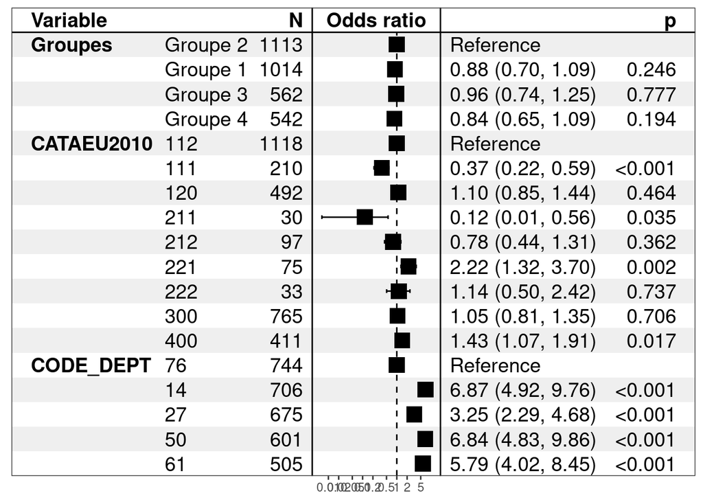

```r
# Représentations graphiques du modèle
# ggcoef_model(reg, exponentiate = FALSE)
forest_model(reg)
```

```r
# Représentation graphique des effets
# plot(allEffects(reg))

# plot_grid(plotlist = plot(ggeffect(reg)))
# Pour n'afficher qu'une variable :
# plot(ggeffect(reg, "_nom_de_la_variable"))

screenreg(reg, stars = c(0.01, 0.05, 0.1))
```

```
##
## =============================
##                  Model 1
## -----------------------------
## (Intercept)         -2.61 ***
##                     (0.16)
## GroupesGroupe 1     -0.13
##                     (0.11)
## GroupesGroupe 3     -0.04
##                     (0.13)
## GroupesGroupe 4     -0.17
##                     (0.13)
## CATAEU2010111       -1.00 ***
##                     (0.26)
## CATAEU2010120        0.10
##                     (0.14)
## CATAEU2010211       -2.16 **
##                     (1.02)
## CATAEU2010212       -0.25
##                     (0.28)
## CATAEU2010221        0.80 ***
##                     (0.26)
## CATAEU2010222        0.13
##                     (0.40)
## CATAEU2010300        0.05
##                     (0.13)
## CATAEU2010400        0.36 **
##                     (0.15)
## CODE_DEPT14          1.93 ***
##                     (0.17)
## CODE_DEPT27          1.18 ***
##                     (0.18)
## CODE_DEPT50          1.92 ***
##                     (0.18)
## CODE_DEPT61          1.76 ***
##                     (0.19)
## -----------------------------
## AIC               3253.69
## BIC               3350.98
## Log Likelihood   -1610.85
## Deviance          3221.69
## Num. obs.         3231
## =============================
## *** p < 0.01; ** p < 0.05; * p < 0.1
```

```r
# texreg(reg, stars = c(0.01, 0.05, 0.1)) # Pour export LaTeX
```

**NB : Toutes choses égales par ailleurs quand AU ZAU et au département, la dimension politique ne paraît pas avoir d’impact significatif sur la probabilité de fusionner en Normandie.**

#### 6.2.5.4 Lecture du modèle

Les odds ratio (littéralement rapport des cotes, ou rapport des chances ou rapport des risques relatiffs) permettent de décrire la significativité pratique. Celle-ci désigne l’impact d’une variable. Il ne faut pas la confondre avec la significativité statistique, qui décrit « le degré de certitude avec lequel on peut affirmer qu’une variable influe » (Afsa (2016) p. 39).

À noter que, par exemple pour Afsa (2016), l’expression « toutes choses égales par ailleurs » est à éviter. En effet, ce n’est le cas que si les variables étudiées permettent de décrire parfaitement le phénomène. « les résultats des estimations sont *conditionnels* à la liste des variables *x* introduites dans le modèle, c’est-à-dire qu’ils dépendent des variables introduites » (Afsa (2016) p. 53). Si des variables, non mesurées, influent à la fois sur les variables du modèle et la variable étudiée, cela brouille l’analyse. Ainsi, pour les analyses présentées ici, c’est plutôt l’expression “Toutes choses égales quant aux autres variables introduites” qui est à utiliser.

Un Odds ratio égal à 1 signifie que la variable d’intérêt (la fusion ici) est indépendante de la variable explicative envisagée. Si l’OR est supérieur à 1, une commune ayant une variable explicative **plus élevée** ont **plus** de chance de fusionner, s’il est inférieur à 1, les communes avec une variable explicative **plus faible** ont **moins** de chance de fusionner.

# 7 Positionnement politique des communes nouvelles

Pour les élections avant et après les fusions : les communes fusionnantes et nouvelles se positionnent-elles différemment des autres communes comparables ?

Cf. par exemple https://larmarange.github.io/analyse-R/regression-logistique.html.

On fait le choix d’analyser ces données sous l’angle d’une régression logistique. Il s’agit d’observer si des variables augmentent ou diminuent la probabilité d’avoir une situation (fusion ou non). (Les tests de régression logistique sont utilisées parfois pour observer si des caractéristiques, qui seraient donc alors des comorbidités, augmentent ou non la probabilité d’avoir un décès.)

# 8 Étude de cas particuliers

Regarder un peu dans le détail les résultats de Cherbourg et Annecy : La fusion a-t-elle conduit à des basculements politiques ?

# 9 Communes sans candidats aux élections municipales de 2014

www.interieur.gouv.fr/content/download/68541/499035/file/Absence%2520de%2520candidats%2520communes%2520moins%2520de%25201%2520000%2520hbts.pdf

```r
# install.packages("pdftools")
# library(pdftools)

# download.file("https://www.interieur.gouv.fr/content/download/68541/499035/file/Absence%2520de%2520candidats%2520communes%2520moins%2520de%25201%2520000%2520hbts.pdf", "data-raw/elections/sans_candidats_2014.pdf")
text <- pdf_text("data-raw/elections/sans_candidats_2014.pdf")
text[1]
```

```
## [1] "    COMMUNES SANS CANDIDAT (MOINS DE 1 000 HABITANTS)\nCode     Désignation             Département\n01-235   Marlieux                AIN\n01-302   Pollieu                 AIN\n02-198   Clamecy                 AISNE\n14-170   Colomby-sur-Thaon       CALVADOS\n14-253   Estry                  …
```

```r
result <- as.data.frame(str_split(text[1], "\n"))
result <- substr(result[,1], start = 1, stop = 6)
result2 <- as.data.frame(str_split(text[2], "\n"))
result2 <- substr(result2[,1], start = 1, stop = 6)

sans_candidats_2014 <- c(result, result2)
sans_candidats_2014 <- sans_candidats_2014[3:length(sans_candidats_2014)]
sans_candidats_2014 <- as.data.frame(sans_candidats_2014)

# On supprimer le caractère "-"
sans_candidats_2014[1] <- str_replace(sans_candidats_2014[,1], "-", "")
colnames(sans_candidats_2014) <- "CODGEO"
rm(text, result, result2)


NoCandidats <- merge(sans_candidats_2014, df2011, by = "CODGEO")
table(NoCandidats$COM_NOUV)
```

```
##
## NON OUI
##  50  11
```

```r
# Conclusion : seulement onze des 61 communes concernées ont participé à une création de commune nouvelle
```

# 10 Étude du genre des maires

Source pour les élus en 2014 : https://www.data.gouv.fr/fr/datasets/liste-des-maires-au-17-juin-2014/

Source pour les élus en 2022 : https://www.data.gouv.fr/fr/datasets/repertoire-national-des-elus-1/

## 10.1 En 2014

```r
# download.file("https://www.data.gouv.fr/fr/datasets/r/4f71a09d-78fd-4fe4-8396-34765be70788", "data-raw/elections/maires_2014_06_17.xlsx")
# Téléchargement effectué le 6 mars 2023
elus_2014 <- read_xlsx( "data-raw/elections/maires_2014_06_17.xlsx", skip = 1)

# On rajoute des zéros (0) aux variables département et numéro de commune pour créer un identifiant CODGEO
elus_2014$`Code Insee de la commune` <- str_pad(elus_2014$`Code Insee de la commune`, 3, pad = "0") # Si besoin de rajouter des zéros (s'ils ne sont pas présents dans la table)
elus_2014$`Code du département (Maire)` <- str_pad(elus_2014$`Code du département (Maire)`, 2, pad = "0")
elus_2014$CODGEO <- paste0(elus_2014$`Code du département (Maire)`, elus_2014$`Code Insee de la commune`)

# On fusionne avec df2011
elus_2014 <- merge (df2011 [, c("CODGEO", "COM_NOUV", "ChefLieu")], elus_2014, by = "CODGEO", all.x = TRUE, all.y = FALSE)


# Si on veut utiliser le champs date de naissance
# Possible de passer en format date
#elus_2014$`Date de naissance` <- as.Date(elus_2014$`Date de naissance`, tryFormats = "%Y-%m-%d")

elus_2014$Date_simpl <- substr(elus_2014$`Date de naissance`, start = 1, stop = 4)
# class(elus_2014$Date_simpl)
elus_2014$Date_simpl <- as.numeric(elus_2014$Date_simpl)
seuils <- quantile(elus_2014$Date_simpl, probs=seq(0, 1, 0.25), na.rm = TRUE)
elus_2014$Date_quantiles <- cut(elus_2014$Date_simpl, breaks = seuils)
```

```r
# On modifie l'intitulé des variables pour en simplifier la manipulation (on enlève les espaces)
elus_2014$Sexe <- elus_2014$`Code sexe`
elus_2014$Profession <- elus_2014$`Libellé de la profession`

liste_criteres <- c("Sexe", "Profession", "Date_quantiles")

elus_2014CN <- subset (elus_2014, elus_2014$COM_NOUV == "OUI")
elus_2014CN$ChefLieu <- paste0("ChefLieuCN_", elus_2014CN$ChefLieu)
critere <- liste_criteres[1]

for (critere in liste_criteres) {
  print(paste0("VARIABLE ÉTUDIÉE : ", critere))
  tabcont <- table(elus_2014$COM_NOUV, elus_2014[, critere])

round(100*prop.table(tabcont,margin=1),1) # Pourcentages, le total se fait par lignes
round(100*prop.table(tabcont,margin=),1) # Pourcentages, le total se fait sur l'ensemble de la population
print(round(100*prop.table(tabcont,margin=2),1)) # Pourcentages, le total se fait par colonnes
test<-chisq.test(tabcont)
print(test)

# Le genre des élus en fonction de la situation de chef-lieu
tabcont <- table(elus_2014CN$ChefLieu, elus_2014CN[, critere])
tabcont
round(100*prop.table(tabcont,margin=1),1) # Pourcentages, le total se fait par lignes
round(100*prop.table(tabcont,margin=),1) # Pourcentages, le total se fait sur l'ensemble de la population
print(round(100*prop.table(tabcont,margin=2),1)) # Pourcentages, le total se fait par colonnes
test<-chisq.test(tabcont)
print(test)

}
```

```
## [1] "VARIABLE ÉTUDIÉE : Sexe"
##
##          F    M
##   NON 93.3 92.9
##   OUI  6.7  7.1
##
##  Pearson's Chi-squared test with Yates' continuity correction
##
## data:  tabcont
## X-squared = 1.4966, df = 1, p-value = 0.2212
##
##
##                   F    M
##   ChefLieuCN_N 80.4 66.5
##   ChefLieuCN_O 19.6 33.5
##
##  Pearson's Chi-squared test with Yates' continuity correction
##
## data:  tabcont
## X-squared = 28.588, df = 1, p-value = 8.955e-08
##
## [1] "VARIABLE ÉTUDIÉE : Profession"
##
##       Administrateurs de sociétés Agents d'affaires Agents d'assurances
##   NON                        92.6              94.4                89.1
##   OUI                         7.4               5.6                10.9
##
##       Agents généraux d'assurances Agents immobiliers
##   NON                         93.1               91.5
##   OUI                          6.9                8.5
##
##       Agents subalternes (entr.publiques) Agents technique et techniciens
##   NON                                95.2                            93.6
##   OUI                                 4.8                             6.4
##
##       Agriculteurs propriétaires exploit. Architectes Artisans
##   NON                                92.7        90.9     94.4
##   OUI                                 7.3         9.1      5.6
##
##       Assistantes sociales Autres cadres (secteur privé) Autres professions
```

[output cut: 215 more lines]

```
##
##  Pearson's Chi-squared test
##
## data:  tabcont
## X-squared = 5.9009, df = 3, p-value = 0.1165
##
##
##                (1922,1949] (1949,1954] (1954,1961] (1961,1992]
##   ChefLieuCN_N        71.1        66.0        68.4        68.5
##   ChefLieuCN_O        28.9        34.0        31.6        31.5
##
##  Pearson's Chi-squared test
##
## data:  tabcont
## X-squared = 4.2101, df = 3, p-value = 0.2397
```

```r
rm (tabcont, critere, liste_criteres)
```

Sur l’âge, visiblement pas beaucoup d’incidence.

Sur la profession, travail pas encore assez approfondi.

## 10.2 En 2022

```r
# download.file("https://www.data.gouv.fr/fr/datasets/r/2876a346-d50c-4911-934e-19ee07b0e503", "data-raw/elections/maires_2022.csv")
# Téléchargement effectué le 6 mars 2023
elus_2022<- read_delim("data-raw/elections/maires_2022.csv", delim = "\t", escape_double = FALSE, trim_ws = TRUE, show_col_types = FALSE)

elus_2022$CODGEO_new <- elus_2022$`Code de la commune`

elus_2022 <- merge (df_new [, c("CODGEO_new", "COM_NOUV")], elus_2022, by = "CODGEO_new", all.x = TRUE, all.y = FALSE)

# Le genre des élus en fonction du fait de participer à une commune nouvelle ou non
tabcont <- table(elus_2022$COM_NOUV, elus_2022$`Code sexe`)
tabcont
```

```
##
##           F     M
##   NON  6877 26613
##   OUI   129   670
```

```r
round(100*prop.table(tabcont,margin=1),1) # Pourcentages, le total se fait par lignes
```

```
##
##          F    M
##   NON 20.5 79.5
##   OUI 16.1 83.9
```

```r
round(100*prop.table(tabcont,margin=),1) # Pourcentages, le total se fait sur l'ensemble de la population
```

```
##
##          F    M
##   NON 20.1 77.6
##   OUI  0.4  2.0
```

```r
round(100*prop.table(tabcont,margin=2),1) # Pourcentages, le total se fait par colonnes
```

```
##
##          F    M
##   NON 98.2 97.5
##   OUI  1.8  2.5
```

```r
test<-chisq.test(tabcont)
test
```

```
##
##  Pearson's Chi-squared test with Yates' continuity correction
##
## data:  tabcont
## X-squared = 8.98, df = 1, p-value = 0.00273
```

En 2022, les femmes sont encore moins présentes comme maires des communes nouvelles que comme maires des autres communes.

# 11 LIMITE (au-delà, le code n’est plus joué lors d’un knit)

```r
knitr::opts_chunk$set(echo=FALSE, # Afficher ou non le code R dans le document
                      eval  = FALSE, #  Exécuter ou non le code R à la compilation
                      include   = FALSE, #  Inclure ou non le code R et ses résultats dans le document
                      # results “hide”/“asis”/“markup”/“hold”   Type de résultats renvoyés par le bloc de code
                      warning = TRUE, # Afficher ou non les avertissements générés par le bloc
                      message = TRUE, # Afficher ou non les messages générés par le bloc
                      cache = TRUE) # Utiliser le cache pour accélerer les knits.
```

# 12 Annexes

## 12.1 Anciens scripts d’import, à supprimer quand import propre réalisé

Script utilisé pour l’import des données dans les précédentes études.

## 12.2 Tentative n’ayant pas été suivie : utiliser COGugaison

Bilan : package sur le principe intéressant mais que je ne trouve pas assez maniable pour ce que je veux faire.

## 12.3 Tentative n’ayant pas été suivie : utiliser les données à l’échelle des bureaux de votes

[Octobre 2022]

Les données en fonction des bureaux de votes sont à une maille certes plus fine que celles à l’échelle communale mais la géographie de ces bureaux de votes n’est pas disponible aisément. Par exemple, pour travailler de cette manière, J. Rivière a dû s’appuyer sur une base de données (CARTELEC, actualisée par Céline Colange, IR à l’UMR IDEES 6266 CNRS) et au traitement par deux doctorants. « Cette ventilation a été réalisée sous le logiciel R par Aliette Roux (doctorante en géographie, Université de Nantes – UMR ESO) grâce au script « eapportion data from one geography to another in R » développé par Joël Gombin (doctorant en science politique, Université de Picardie Jules Verne – UMR CURAPP-ESS). » (Rivière 2017)

Certaines données concernant les géographies des bureaux de votes sont disponibles ici : http://cartelec.univ-rouen.fr/?page_id=3609 mais pas pour les élections les plus récentes

Afsa, Cédric. 2016. “Le Modèle Logit : Théorie Et Application - Documents de Travail - M2016/01.” INSEE. https://www.insee.fr/fr/statistiques/2022139.

Bideau, Gabriel. 2019. “Les communes nouvelles françaises (2010-2019) : Une réforme territoriale silencieuse.” *Annales de Géographie* 728 (4/2019): 57–85. https://www.cairn.info/revue-annales-de-geographie-2019-4-page-57.htm.

Bideau, Gabriel, and Ronan Ysebaert. 2022. “Les communes nouvelles françaises (2010-2020) : quels profils pour ces territoires du quotidien remaniés ?” *L’Espace géographique* 50 (2021/1-2): 45–66. https://doi.org/10.3917/eg.501.0045.

Rivière, Jean. 2017. “L’espace électoral des grandes villes françaises. Votes et structures sociales intra-urbaines lors du scrutin présidentiel de 2017.” *Revue française de science politique* 67 (6): 1041–65. https://doi.org/10.3917/rfsp.676.1041.